# Optimisasi Konveks — Edisi Bahasa Indonesia

Andreas Habring; terjemahan/adaptasi mandiri

> **Status pembaca.** Edisi Bahasa Indonesia ini memuat terjemahan lengkap sembilan bab dari Andreas Habring, *Lecture Notes: Convex Optimization*, arXiv:2607.11664v1. Ini adalah karya turunan mandiri, bukan edisi resmi atau dukungan penulis sumber maupun TU Graz. Rumus, bukti, latihan, gambar yang diizinkan, dan urutan sumber dipertahankan; koreksi yang dapat ditentukan ditandai dan direkam dalam ledger edisi.

> Sumber dan terjemahan tersedia berdasarkan Creative Commons Attribution 4.0 International (CC BY 4.0). Provenans produksi: OpenAI Codex gpt-5.6-sol, Ultra, atas instruksi pengguna repositori; seluruh kredit penulis dan sumber tetap dipertahankan.

# Prakata

Catatan ini dibangun di atas slide kuliah yang disusun oleh Prof. Thomas Pock. Naskah ini belum merupakan versi final dan mungkin masih memuat salah ketik atau kesalahan, serta kekurangan *teks penghubung* di antara hasil-hasilnya. Catatan ini terutama berfungsi sebagai kumpulan materi untuk kuliah terkait yang saya ampu pada semester musim panas 2026 di Graz University of Technology.

Saya berterima kasih kepada Prof. Christian Clason atas templat LaTeX yang indah ini.

# Prasyarat

## Ruang vektor, norma, dan hasil kali dalam

Ruang vektor atas suatu medan $\mathbb{F}$ adalah himpunan $V$ yang dilengkapi dengan dua operasi $+:V\times V\rightarrow V$, $(u,v)\mapsto u+v$, dan $\cdot:\mathbb{F}\times V\rightarrow V$, $(\lambda,v)\mapsto\lambda\cdot v$, sedemikian sehingga

1. $(V,+)$ merupakan grup Abel; yaitu, untuk setiap $u,v,w\in V$ berlaku:
   1. Asosiativitas: $(u+v)+w=u+(v+w)$.
   2. Unsur netral: terdapat $e\in V$ sehingga $v+e=e+v=v$. Kita menuliskan $e=0$.
   3. Unsur invers: terdapat $\widetilde v\in V$ sehingga $v+\widetilde v=0$. Kita menuliskan $\widetilde v=-v$.
   4. Komutativitas: $v+w=w+v$.
2. Hukum-hukum skalar berikut berlaku untuk setiap $u,v\in V$ dan $\lambda,\mu\in\mathbb{F}$:
   1. $\lambda\cdot(\mu\cdot v)=(\lambda\mu)\cdot v$.
   2. $\lambda\cdot(u+v)=(\lambda\cdot u)+(\lambda\cdot v)$.
   3. $(\lambda+\mu)\cdot v=(\lambda\cdot v)+(\mu\cdot v)$.
   4. $1\cdot v=v$.

Kita menuliskan $\lambda\cdot v=\lambda v$.

Mulai sekarang kita membatasi pembahasan pada $\F=\R$.

1. $\R^d$: ruang vektor yang terdiri atas vektor berbentuk
   $$\begin{equation}
   v=\begin{pmatrix}
   v_1\\
   \vdots\\
   v_d
   \end{pmatrix},
   \end{equation}$$
   dengan $v_i\in\R$, penjumlahan dilakukan komponen demi komponen, dan perkalian skalar diterapkan pada setiap komponen. Suatu hasil matematika penting menyatakan bahwa setiap ruang vektor berdimensi hingga dapat diidentifikasi dengan $\R^d$, dengan $d$ dimensinya. Karena itu, ketika bekerja dengan ruang berdimensi hingga, kita biasanya dapat membayangkan $\R^d$.
2. Ruang fungsi: misalkan $\Omega\subset\R^d$ dan $f,g:\Omega\rightarrow\R$. Kita dapat mendefinisikan $f+g$ serta, untuk $\lambda\in\R$, $\lambda f$ secara titik demi titik melalui
   $$\begin{gather}
   (f+g)(x)=f(x)+g(x),\\
   (\lambda f)(x)=\lambda f(x).
   \end{gather}$$
   Dengan cara ini kita dapat membentuk berbagai ruang fungsi. Salah satu contohnya ialah ruang fungsi linear. Mengapa ini benar-benar merupakan ruang vektor yang terdefinisi dengan baik?

Norma adalah fungsi $\|\emptyarg\|:V\rightarrow[0,\infty)$ sedemikian sehingga, untuk setiap $\lambda\in\R$ dan $u,v\in V$, berlaku

1. Ketegasan positif: $\|v\|=0$ jika dan hanya jika $v=0$.
2. Homogenitas: $\|\lambda u\|=|\lambda|\|u\|$.
3. Ketaksamaan segitiga: $\|u+v\|\leq\|u\|+\|v\|$.

Pasangan $(V,\|\emptyarg\|)$ disebut ruang bernorma.

Berdasarkan kodomainnya, norma selalu tak negatif.

Mulai sekarang semua ruang vektor dianggap bernorma. Jika tidak menimbulkan ambiguitas, kita cukup menuliskan normanya sebagai $\|\emptyarg\|$. Untuk menyatakan norma tertentu kita menggunakan, misalnya, $\|\emptyarg\|_\bigstar$, dengan $\bigstar$ suatu simbol yang menandai norma tersebut; [preliminiaries:example:norms].

1. Norma $\ell^p$: untuk $p\in[1,\infty)$ kita menuliskan
   $$\begin{equation}
   \|v\|_p=\bigg(\sum_{i=1}^d|v_i|^p\bigg)^{1/p}.
   \end{equation}$$
   Untuk $p=\infty$ kita menuliskan
   $$\begin{equation}
   \|v\|_\infty=\max_{i=1,\dots,d}|v_i|.
   \end{equation}$$
2. Tinjau ruang matriks $n\times m$, yaitu $\R^{n\times m}$. Setiap matriks $A\in\R^{n\times m}$ dapat diidentifikasi dengan fungsi linear melalui
   $$\begin{equation}
   (Av)_i=\sum_{j=1}^m A_{i,j}v_j,\qquad i=1,\dots,n.
   \end{equation}$$
   Norma-norma berikut sering digunakan pada $\R^{n\times m}$:
   - Norma Frobenius: $\|A\|_F=\sqrt{\sum_{i,j}|A_{i,j}|^2}$.
   - Norma terinduksi: untuk setiap pasangan norma $\|\emptyarg\|_a$ pada $\R^m$ dan $\|\emptyarg\|_b$ pada $\R^n$, kita mendefinisikan
     $$\begin{equation}
     \|A\|_{a,b}
     \coloneq\sup_{\|v\|_a\leq1}\|Av\|_b
     =\sup_{v\neq0}\frac{\|Av\|_b}{\|v\|_a}.
     \end{equation}$$
     Norma terinduksi memenuhi $\|Av\|_b\leq\|A\|_{a,b}\|v\|_a$. Jika $a=b$, kita menuliskan $\|\emptyarg\|_{a,a}=\|\emptyarg\|_a$. Secara khusus,
     $$\begin{gather}
     \|A\|_1=\max_j\sum_i|A_{i,j}|,\\
     \|A\|_\infty=\max_i\sum_j|A_{i,j}|,\\
     \|A\|_2=\sqrt{\lambda_{\mathrm{max}}(A^\top A)}.
     \end{gather}$$

   Di sini $\lambda_{\mathrm{max}}$ menyatakan nilai eigen terbesar.
3. Untuk fungsi terukur Lebesgue $f:\Omega\rightarrow\R$, dengan $\Omega\subset\R^d$ terukur, kita dapat mendefinisikan norma $L^p$ melalui
   $$\begin{equation}
   \|f\|_p=\bigg(\int_\Omega|f(x)|^p\dd x\bigg)^{1/p},
   \qquad 1\leq p<\infty,
   \end{equation}$$
   dan[^1]
   $$\begin{equation}
   \|f\|_\infty=\operatorname*{ess\,sup}_{x\in\Omega}|f(x)|.
   \end{equation}$$
   Dengan mengidentifikasi fungsi-fungsi yang sama hampir di mana-mana, $\|\emptyarg\|_p$ mendefinisikan norma pada ruang vektor
   $$\begin{equation}
   L^p(\Omega)=
   \{f:\Omega\rightarrow\R\mid f\text{ terukur dan
   }\|f\|_p<\infty\}
   /\!\sim_{\mathrm{a.e.}}.
   \end{equation}$$

Semua norma pada $\R^d$ ekuivalen. Artinya, untuk setiap dua norma $\|\emptyarg\|_a$ dan $\|\emptyarg\|_b$, terdapat $m,M>0$ sedemikian sehingga untuk setiap $v\in\R^d$ berlaku
$$\begin{equation}
m\|v\|_a\leq\|v\|_b\leq M\|v\|_a.
\end{equation}$$

Pemetaan $\langle\emptyarg,\emptyarg\rangle:V\times V\rightarrow\R$ disebut hasil kali skalar atau hasil kali dalam jika, untuk setiap $u,v,w\in V$ dan skalar yang relevan, berlaku

1. Bilinearitas: pemetaan $w\mapsto\langle w,u\rangle$ dan $w\mapsto\langle u,w\rangle$ bersifat linear.
2. Ketegasan positif: $\langle u,u\rangle\geq0$, dan kesamaan berlaku jika dan hanya jika $u=0$.
3. Simetri: $\langle u,v\rangle=\langle v,u\rangle$.

Setiap hasil kali dalam mendefinisikan norma melalui $\|v\|\coloneq\sqrt{\inner{v}{v}}$. Dalam hal ini, $V$ disebut ruang hasil kali dalam.

Pada setiap ruang hasil kali dalam $V$ berlaku
$$\begin{equation}
\inner{v}{w}\leq|\inner{v}{w}|\leq\|v\|\|w\|,
\qquad v,w\in V,
\end{equation}$$
dan ketaksamaan kedua bersifat ketat apabila $v$ dan $w$ tidak kolinear.

*Proof.* Kita boleh mengandaikan $v,w\neq0$, sebab jika tidak hasilnya langsung berlaku. Untuk setiap $\lambda\in\R$,
$$\begin{equation}
\label{preliminaries:eq:CS}
0\leq\inner{v-\lambda w}{v-\lambda w}
=\|v\|^2-2\lambda\inner{v}{w}+\lambda^2\|w\|^2.
\end{equation}$$
Ambil $\lambda=\inner{v}{w}/\|w\|^2$. Maka
$$\begin{equation}
0\leq\|v\|^2-\frac{|\inner{v}{w}|^2}{\|w\|^2},
\end{equation}$$
yang memberikan $|\inner{v}{w}|\leq\|v\|\|w\|$. Jika $v$ dan $w$ tidak kolinear, maka $v-\lambda w\neq0$ untuk setiap $\lambda$, sehingga ketaksamaan dalam [preliminaries:eq:CS], dan dengan demikian ketaksamaan Cauchy–Schwarz, bersifat ketat. ◻

Misalkan $p,q\in[1,\infty]$ memenuhi $\frac1p+\frac1q=1$[^2]. Untuk setiap $u,v\in\R^d$ yang dilengkapi dengan hasil kali dalam baku, berlaku
$$\begin{equation}
\inner{u}{v}\leq|\inner{u}{v}|\leq\|u\|_p\|v\|_q.
\end{equation}$$

*Proof.* Kita membedakan kasus-kasus berikut.

- $p=1$ dan $q=\infty$: dengan mudah diperoleh
  $$\begin{equation}
  |\inner{u}{v}|
  \leq\sum_i|u_i||v_i|
  \leq\sum_i|u_i|\|v\|_\infty
  =\|v\|_\infty\|u\|_1.
  \end{equation}$$
  Kasus $p=\infty$, $q=1$ mengikuti dengan menukar $u$ dan $v$.
- $1<p<\infty$: ketaksamaan jelas benar jika $u=0$ atau $v=0$, sehingga andaikan $u,v\neq0$. Ketaksamaan Young menyatakan bahwa untuk eksponen konjugat $1<p,q<\infty$ dan $a,b\geq0$ berlaku $ab\leq a^p/p+b^q/q$. Karena itu,
  $$\begin{equation}
  \label{eq:prelim:hoelder}
  |\inner{u}{v}|
  \leq\sum_i|u_i||v_i|
  \leq\sum_i\left(\frac{|u_i|^p}{p}+\frac{|v_i|^q}{q}\right)
  =\frac{\|u\|_p^p}{p}+\frac{\|v\|_q^q}{q}.
  \end{equation}$$
  Mengganti $u$ dengan $u/\|u\|_p$ dan $v$ dengan $v/\|v\|_q$ dalam [eq:prelim:hoelder] memberikan
  $$\begin{equation}
  \begin{aligned}
  \frac{|\inner{u}{v}|}{\|u\|_p\|v\|_q}
  &=\left|\inner{\frac{u}{\|u\|_p}}
  {\frac{v}{\|v\|_q}}\right|\\
  &\leq
  \frac{\left\|u/\|u\|_p\right\|_p^p}{p}
  +\frac{\left\|v/\|v\|_q\right\|_q^q}{q}
  =\frac1p+\frac1q=1.
  \end{aligned}
  \end{equation}$$

◻

Dengan ketaksamaan Hölder, kita dapat menunjukkan bahwa norma $\ell^p$ memenuhi ketaksamaan segitiga, yaitu bagian tersulit dalam membuktikan bahwa besaran tersebut benar-benar merupakan norma.

Untuk setiap $p\in[1,\infty]$ berlaku
$$\begin{equation}
\|x+y\|_p\leq\|x\|_p+\|y\|_p,
\qquad x,y\in\R^d.
\end{equation}$$

*Proof.* Kasus $p\in\{1,\infty\}$ ditinggalkan sebagai latihan sederhana. Jadi, andaikan $1<p<\infty$. Kita boleh mengandaikan $\|x+y\|_p\neq0$, sebab jika tidak hasilnya langsung berlaku. Dengan ketaksamaan Hölder dan hubungan $p-1=p/q$, diperoleh
$$\begin{equation}
\begin{aligned}
\|x+y\|_p^p
&=\sum_i|x_i+y_i||x_i+y_i|^{p-1}\\
&\leq\sum_i|x_i||x_i+y_i|^{p-1}
+\sum_i|y_i||x_i+y_i|^{p-1}\\
&\leq(\|x\|_p+\|y\|_p)
\bigg(\sum_i|x_i+y_i|^{(p-1)q}\bigg)^{1/q}\\
&=(\|x\|_p+\|y\|_p)\|x+y\|_p^{p/q}.
\end{aligned}
\end{equation}$$
Membagi kedua ruas dengan $\|x+y\|_p^{p/q}$ menyelesaikan bukti. ◻

## Barisan dan topologi dasar

Barisan $(x_n)_n\subset\R^d$ disebut konvergen jika terdapat $x\in\R^d$ sedemikian sehingga untuk setiap $\epsilon>0$ terdapat $N\in\N$ dengan
$$\begin{equation}
n\geq N\quad\Longrightarrow\quad\|x-x_n\|\leq\epsilon.
\end{equation}$$

Berdasarkan ekuivalensi norma, kekonvergenan tidak bergantung pada pilihan norma.

Barisan $(x_n)_n\subset V$ disebut barisan Cauchy jika dan hanya jika untuk setiap $\epsilon>0$ terdapat $N\in\N$ sedemikian sehingga $\|x_n-x_m\|<\epsilon$ bagi setiap $n,m\geq N$.

Sifat Cauchy serupa dengan kekonvergenan. Namun, perhatikan bahwa sifat Cauchy dapat dirumuskan tanpa gagasan titik limit. Hasil berikut mudah dibuktikan.

Setiap barisan konvergen merupakan barisan Cauchy.

*Proof.* Misalkan $x_n\rightarrow\hat x$. Ketaksamaan segitiga memberikan
$$\begin{equation}
\|x_n-x_m\|\leq\|x_n-\hat x\|+\|x_m-\hat x\|,
\end{equation}$$
dan kedua suku di ruas kanan dapat dibuat sekecil yang diinginkan dengan memilih $n,m$ cukup besar. ◻

Ruang bernorma $(V,\|\emptyarg\|)$ disebut ruang Banach jika setiap barisan Cauchy konvergen. Artinya, jika $(x_n)_n$ merupakan barisan Cauchy, terdapat $x\in V$ sehingga $\|x_n-x\|\rightarrow0$ ketika $n\rightarrow\infty$. Jika normanya berasal dari suatu hasil kali dalam, ruang Banach tersebut disebut ruang Hilbert.

Ruang $(\R^d,\|\emptyarg\|_p)$ merupakan ruang Banach untuk setiap $1\leq p\leq\infty$.

Suatu himpunan $A\subset\R^d$ disebut

- terbuka jika untuk setiap $x\in A$ terdapat $\epsilon>0$ sehingga $B_\epsilon(x)\subset A$;
- tertutup jika $A^c$ terbuka. Ketertutupan ekuivalen dengan sifat berikut: jika $(x_n)_n\subset A$ dan $x_n\rightarrow x\in\R^d$, maka $x\in A$.

Himpunan $A\subset\R^d$ disebut kompak secara sekuensial jika setiap barisan di $A$ mempunyai suatu subbarisan yang konvergen ke titik di $A$. Dengan kata lain, untuk setiap $(x_n)_n\subset A$ terdapat subbarisan $(x_{n(k)})_k$ dan titik $x\in A$ sedemikian sehingga $x_{n(k)}\rightarrow x$.

Dalam ruang vektor berdimensi hingga, setiap barisan terbatas mempunyai subbarisan konvergen.

*Proof.* Pertama andaikan dimensinya satu, sehingga ruangnya adalah $\R$. Misalkan $(x_n)_n\subset\R$ terbatas. Secara induktif kita membangun dua barisan $(a_n)_n$ dan $(b_n)_n$ dengan $a_n\leq b_n$, $[a_n,b_n]\subset[a_{n-1},b_{n-1}]$, $b_n-a_n=(b_{n-1}-a_{n-1})/2$, dan, yang terpenting, $[a_n,b_n]$ memuat tak hingga banyaknya suku $x_k$ untuk setiap $n$.

Karena barisan terbatas, pilih $a_0,b_0$ sehingga $(x_n)_n\subset[a_0,b_0]$. Jelas interval ini memuat tak hingga banyaknya suku $x_k$. Andaikan $a_n,b_n$ telah dipilih dan tetapkan $m_n=(a_n+b_n)/2$. Karena $[a_n,b_n]$ memuat tak hingga banyaknya suku $x_k$, setidaknya salah satu dari $[a_n,m_n]$ dan $[m_n,b_n]$ juga memuat tak hingga banyaknya suku. Pilih interval tersebut sebagai $[a_{n+1},b_{n+1}]$.

Sekarang kita membangun subbarisan $(x_{n(k)})_k$ secara induktif. Pilih $n(0)$ sehingga $x_{n(0)}\in[a_0,b_0]$. Jika $n(0),\ldots,n(m)$ telah dipilih, tetapkan, misalnya, $n(m+1)=\min\{j\in\N\mid j>n(m),\ x_j\in[a_{m+1},b_{m+1}]\}$. Pilihan ini selalu mungkin karena interval tersebut memuat tak hingga banyaknya suku barisan.

Akhirnya, ambil sembarang $k\leq\ell$. Karena $x_{n(k)},x_{n(\ell)}\in[a_k,b_k]$, berlaku
$$\begin{equation}
|x_{n(k)}-x_{n(\ell)}|
\leq b_k-a_k=2^{-k}(b_0-a_0).
\end{equation}$$
Jadi $(x_{n(k)})_k$ merupakan barisan Cauchy dan karenanya konvergen.

Untuk dimensi lebih besar, yaitu $\R^d$, mula-mula pilih subbarisan yang komponen pertamanya konvergen. Dari subbarisan itu pilih lagi subbarisan yang komponen keduanya konvergen, dan lanjutkan demikian. Subbarisan diagonal yang diperoleh setelah langkah ke-$d$ mempunyai semua komponen yang konvergen; khususnya, subbarisan itu konvergen dalam norma satu. Ekuivalensi norma kemudian memberikan kekonvergenan dalam setiap norma. ◻

Sebagai akibatnya, kita memperoleh hasil berikut.

Di $\R^d$, suatu himpunan kompak jika dan hanya jika tertutup dan terbatas.

*Proof.* Misalkan $A\subset\R^d$ tertutup dan terbatas, serta $(x_n)_n\subset A$. Berdasarkan keterbatasan dan [thm:bolzano], terdapat subbarisan konvergen; berdasarkan ketertutupan, limitnya berada di $A$. Jadi $A$ kompak.

Sebaliknya, andaikan $A$ kompak. Jika $A$ tidak terbatas, untuk setiap $n\in\N$ kita dapat memilih $x_n\in A$ dengan $\|x_n\|\geq n$. Barisan ini tidak mempunyai subbarisan konvergen, bertentangan dengan kekompakan. Jadi $A$ terbatas. Selanjutnya, misalkan $(x_n)_n\subset A$ dan $x_n\rightarrow x\in\R^d$. Berdasarkan kekompakan, $(x_n)_n$ mempunyai subbarisan $(x_{n(k)})_k$ yang konvergen ke suatu titik di $A$. Setiap subbarisan dari barisan konvergen mempunyai limit yang sama, sehingga $x=\lim_kx_{n(k)}\in A$. Jadi $A$ tertutup. ◻

## Fungsi

Misalkan $f:V\rightarrow E$ suatu pemetaan di antara dua ruang bernorma. Fungsi $f$ disebut kontinu di $v\in V$ jika salah satu dari dua syarat ekuivalen berikut dipenuhi:

- untuk setiap barisan $v_n\rightarrow v$, berlaku $f(v_n)\rightarrow f(v)$;
- untuk setiap $\epsilon>0$ terdapat $\delta>0$ sedemikian sehingga
  $$\begin{equation}
  \|u-v\|\leq\delta
  \quad\Longrightarrow\quad
  \|f(u)-f(v)\|\leq\epsilon.
  \end{equation}$$

Jika $f$ kontinu pada setiap $v\in V$, kita cukup mengatakan bahwa $f$ kontinu.

Misalkan $f:V\rightarrow E$ suatu pemetaan di antara dua ruang bernorma. Fungsi $f$ disebut kontinu Lipschitz jika terdapat $L\geq0$ sedemikian sehingga
$$\begin{equation}
\|f(u)-f(v)\|\leq L\|u-v\|,
\qquad u,v\in V.
\end{equation}$$

### Pemetaan linear dan ruang dual

Fungsi $f:\R^n\rightarrow\R^m$ disebut linear jika
$$\begin{equation}
f(\lambda x+\mu y)=\lambda f(x)+\mu f(y),
\qquad x,y\in\R^n,\quad\lambda,\mu\in\R.
\end{equation}$$

Pemetaan linear dapat diidentifikasi dengan matriks.

Ruang semua fungsi linear $\R^n\rightarrow\R^m$ isomorfik[^3] dengan ruang semua matriks $A\in\R^{m\times n}$.

*Proof.* Kita mendefinisikan korespondensi satu-ke-satu dengan mengaitkan setiap $f:\R^n\rightarrow\R^m$ pada matriks $A_f$ yang diberikan oleh
$$\begin{equation}
(A_f)_{i,j}=f(e_j)_i.
\end{equation}$$
Pembuktian bahwa korespondensi ini bijektif dan linear ditinggalkan sebagai latihan. ◻

Misalkan $V$ suatu ruang bernorma. Ruang dual $V^*$ adalah **ruang vektor** semua fungsional linear kontinu dari $V$ ke $\R$, yaitu
$$\begin{equation}
V^*=\{f:V\rightarrow\R\mid f\text{ linear dan kontinu}\}.
\end{equation}$$
Unsur $V^*$ disebut fungsional linear pada $V$. Norma kanonik pada $V^*$ adalah norma dual
$$\begin{equation}
\|v^*\|_{V^*}
\coloneq\sup_{\substack{v\in V\\\|v\|_V\leq1}}|v^*(v)|.
\end{equation}$$
Dengan sedikit penyalahgunaan notasi, penerapan suatu unsur dual juga sering ditulis memakai notasi hasil kali dalam:
$$\begin{equation}
\inner{v^*}{v}\coloneq v^*(v).
\end{equation}$$

Langsung dari definisi diperoleh
$$\begin{equation}
|v^*(v)|\leq\|v^*\|\|v\|.
\end{equation}$$

Hasil berikut sangat penting: pada ruang Hilbert, ruang dual dapat diidentifikasi dengan ruang itu sendiri. Hasil ini juga membenarkan penggunaan notasi hasil kali dalam untuk penerapan unsur dual.

Misalkan $V$ ruang Hilbert. Untuk setiap $v^*\in V^*$ terdapat tepat satu $v\in V$ sedemikian sehingga
$$\begin{equation}
v^*(w)=\langle v,w\rangle,
\qquad w\in V.
\end{equation}$$
Pemetaan $v^*\mapsto v$ linear dan memenuhi $\|v\|=\|v^*\|$. Secara khusus, $V^*\cong V$.

*Proof.* Jika $v^*=0$, ambil $v=0$. Jadi, andaikan $v^*\neq0$. Karena $\ker(v^*)$ merupakan subruang tertutup, teorema proyeksi ortogonal pada ruang Hilbert memberikan $V=\ker(v^*)\oplus\ker(v^*)^\perp$. Komponen ortogonal dari sembarang titik di luar kernel tidak nol; setelah dinormalkan, kita memperoleh $z\in\ker(v^*)^\perp$ dengan $v^*(z)\neq0$ dan $\|z\|=1$. Untuk sembarang $w\in V$,
$$\begin{equation}
v^*\bigl(zv^*(w)-wv^*(z)\bigr)=0,
\end{equation}$$
sehingga, berdasarkan ortogonalitas $z$ terhadap $\ker(v^*)$,
$$\begin{equation}
\inner{zv^*(w)-wv^*(z)}{z}=0.
\end{equation}$$
Akibatnya,
$$\begin{equation}
\begin{aligned}
v^*(w)
&=v^*(w)\inner{z}{z}
=\inner{zv^*(w)}{z}\\
&=\inner{zv^*(w)-wv^*(z)}{z}
+\inner{wv^*(z)}{z}\\
&=\inner{w}{v^*(z)z}.
\end{aligned}
\end{equation}$$
Jadi $v=v^*(z)z$ merupakan unsur yang dicari. Ketunggalan, linearitas pemetaan representasi, dan kesamaan normanya ditinggalkan sebagai latihan. ◻

Pada $\R^d$, untuk $1\leq p\leq\infty$, norma dual dari $\|\emptyarg\|_p$ tepat sama dengan $\|\emptyarg\|_q$, dengan $\frac1p+\frac1q=1$.

Sebagian besar pembaca mungkin telah mengenal adjoin atau transpos suatu matriks, yang diperoleh dengan menukar baris dan kolom. Untuk $A\in\R^{n\times m}$, adjoin $A^\top\in\R^{m\times n}$ didefinisikan oleh
$$\begin{equation}
(A^\top)_{i,j}=A_{j,i}.
\end{equation}$$
Dengan hasil kali dalam baku, mudah diperiksa bahwa untuk setiap $x\in\R^m$ dan $y\in\R^n$ berlaku
$$\begin{equation}
\inner{Ax}{y}=\inner{x}{A^\top y}.
\end{equation}$$
Sifat terakhir inilah yang mencirikan definisi formal adjoin suatu pemetaan linear. Secara khusus, **adjoin bergantung pada hasil kali dalam yang dipilih**.

Misalkan $A:V\rightarrow W$ pemetaan linear kontinu di antara dua ruang Hilbert. Operator adjoin $A^*:W\rightarrow V$ didefinisikan oleh
$$\begin{equation}
\inner{Ax}{y}=\inner{x}{A^*y},
\qquad x\in V,\quad y\in W.
\end{equation}$$

Tunjukkan bahwa adjoin merupakan operator linear yang terdefinisi dengan baik.

Misalkan $U,V,W$ ruang Hilbert. Untuk pemetaan linear kontinu $A,B:V\rightarrow W$ dan $\lambda\in\R$, berlaku

1. $(A^*)^*=A$;
2. $(\lambda A+B)^*=\lambda A^*+B^*$;
3. jika $A:U\rightarrow V$ dan $B:V\rightarrow W$ linear kontinu, maka $(BA)^*=A^*B^*$.

*Proof.* Latihan. ◻

Misalkan $V$ ruang vektor. Fungsi $f:V\rightarrow[-\infty,\infty]$ disebut fungsi bernilai real diperluas. Fungsi $f$ disebut proper jika tidak pernah bernilai $-\infty$ dan terdapat $x\in V$ dengan $f(x)<\infty$. Domain efektif suatu fungsi proper $f$ didefinisikan sebagai
$$\begin{equation}
\dom(f)=\{x\in V\mid f(x)<\infty\}.
\end{equation}$$

Fungsi bernilai real diperluas yang sering digunakan adalah fungsi indikator. Untuk $A\subset V$, fungsi indikator didefinisikan oleh
$$\begin{equation}
\delta_A(x)=
\begin{cases}
0, &x\in A,\\
\infty, &x\notin A.
\end{cases}
\end{equation}$$
Dengan fungsi indikator, masalah optimisasi berkendala dapat ditulis ulang sebagai masalah tak berkendala:
$$\begin{equation}
\min_{x\in C}f(x)=\min_{x\in V}\bigl(f(x)+\delta_C(x)\bigr).
\end{equation}$$

Epigraf fungsi $f:V\rightarrow(-\infty,\infty]$ didefinisikan sebagai
$$\begin{equation}
\epi(f)=\{(x,t)\in V\times\R\mid f(x)\leq t\}.
\end{equation}$$
Fungsi disebut tertutup jika epigrafnya merupakan himpunan tertutup.

Jika $A$ tertutup, tunjukkan bahwa $\delta_A$ juga tertutup.

Apakah domain suatu fungsi tertutup harus tertutup? Buktikan atau berikan contoh penyangkal.

Fungsi $f:V\rightarrow(-\infty,\infty]$ disebut semikontinu bawah (*lower semicontinuous*, lsc) jika untuk setiap barisan $x_n\rightarrow x$ di $V$ berlaku
$$\begin{equation}
f(x)\leq\liminf_{n\rightarrow\infty}f(x_n).
\end{equation}$$

Fungsi $f:V\rightarrow(-\infty,\infty]$ tertutup jika dan hanya jika semikontinu bawah.

*Proof.* $\Rightarrow$: andaikan $f$ tertutup, $x_n\rightarrow x$, dan tuliskan $L=\liminf_n f(x_n)$. Jika $L=+\infty$, ketaksamaan yang diinginkan langsung berlaku. Jika $L\in\R$, ambil subbarisan $n(k)$ dengan
$$\begin{equation}
L=\liminf_n f(x_n)=\lim_k f(x_{n(k)}).
\end{equation}$$
Untuk $k$ cukup besar nilainya hingga, sehingga $(x_{n(k)},f(x_{n(k)}))\in\epi(f)$ dan
$$\begin{equation}
(x_{n(k)},f(x_{n(k)}))\longrightarrow(x,L).
\end{equation}$$
Ketertutupan epigraf memberikan $(x,L)\in\epi(f)$, jadi $f(x)\leq L$. Terakhir, $L=-\infty$ tidak mungkin: untuk setiap $M\in\R$ kita dapat memilih subbarisan dengan $f(x_{n(k)})\leq M$; maka $(x_{n(k)},M)\in\epi(f)$ dan ketertutupan akan memberikan $f(x)\leq M$ untuk setiap $M$, bertentangan dengan kodomain $(-\infty,+\infty]$.

$\Leftarrow$: sekarang andaikan $f$ semikontinu bawah dan $(x_n,t_n)_n\subset\epi(f)$ dengan $(x_n,t_n)\rightarrow(x,t)$ dalam $V\times\R$. Khususnya, $x_n\rightarrow x$. Oleh semikontinuitas bawah,
$$\begin{equation}
f(x)\leq\liminf_n f(x_n)
\leq\liminf_n t_n=\lim_n t_n=t.
\end{equation}$$
Jadi $(x,t)\in\epi(f)$, yang membuktikan bahwa epigrafnya tertutup. ◻

Jika pembatasan $f$ pada $\dom(f)$ kontinu dan $\dom(f)$ tertutup, maka $f$ tertutup.

*Proof.* Latihan. ◻

Kegagalan semikontinuitas bawah dapat menyebabkan infimum tidak tercapai.

Fungsi $f:V\rightarrow(-\infty,+\infty]$ disebut koersif jika
$$\begin{equation}
\lim_{\|x\|\rightarrow\infty}f(x)=\infty.
\end{equation}$$

Misalkan $V$ berdimensi hingga dan $f:V\rightarrow(-\infty,\infty]$ proper, koersif, serta semikontinu bawah. Maka $f$ mencapai minimumnya pada $V$.[^4]

*Proof.* Bukti mengikuti apa yang disebut *metode langsung*.

##### Langkah 1: Ambil barisan peminimum.

Misalkan $(x_n)_n$ suatu barisan peminimum[^5], yaitu
$$\begin{equation}
\lim_n f(x_n)=\inf_{x\in V}f(x).
\end{equation}$$

##### Langkah 2: Tunjukkan keterbatasan barisan.

Karena $f$ koersif, barisan peminimum harus terbatas. Jika tidak, terdapat subbarisan $(x_{n(k)})_k$ dengan $\|x_{n(k)}\|\rightarrow\infty$. Koersivitas kemudian memberikan
$$\begin{equation}
f(x_{n(k)})\rightarrow\infty,
\end{equation}$$
yang bertentangan dengan
$$\begin{equation}
f(x_{n(k)})\rightarrow\inf f<\infty.
\end{equation}$$

##### Langkah 3: Gunakan kekompakan untuk mengambil subbarisan konvergen.

Berdasarkan [thm:bolzano], setiap barisan terbatas dalam ruang vektor berdimensi hingga mempunyai subbarisan konvergen. Jadi kita dapat mengambil subbarisan $(x_{n(k)})_k$ dengan limit $\lim_kx_{n(k)}=\hat x$.

##### Langkah 4: Simpulkan dengan semikontinuitas bawah.

Berdasarkan semikontinuitas bawah $f$,
$$\begin{equation}
f(\hat x)
\leq\liminf_{k\rightarrow\infty}f(x_{n(k)})
=\lim_n f(x_n)
=\inf_x f(x)
\leq f(\hat x).
\end{equation}$$
Jadi semua ketaksamaan merupakan kesamaan dan $\hat x$ adalah peminim. ◻

# Kekonveksan

Tujuan kita dalam kuliah ini adalah menyelesaikan masalah berbentuk
$$\begin{equation}
\min_{x\in C} f(x),
\end{equation}$$
dengan $C\subset V$ suatu *himpunan bagian konveks* dari ruang $V$ dan $f:C\rightarrow (-\infty,\infty]$ suatu *fungsi konveks*. Oleh karena itu, pada bagian berikut kita menganalisis secara lebih terperinci arti tepat kekonveksan himpunan dan fungsi serta akibat yang dapat ditarik dari sifat-sifat tersebut.

## Himpunan konveks

Suatu himpunan disebut konveks apabila, untuk setiap dua titik di dalamnya, seluruh ruas garis lurus yang menghubungkan kedua titik itu juga termuat di dalam himpunan tersebut. Secara lebih formal:

Suatu himpunan $C\subset V$ disebut konveks jika dan hanya jika, untuk setiap $x,y\in C$ dan $\lambda\in (0,1)$, berlaku
$$\begin{equation}
\lambda x + (1-\lambda) y\in C.
\end{equation}$$

Perhatikan bahwa
$$\begin{equation}
\lambda x + (1-\lambda) y = y + \lambda(x-y),
\end{equation}$$
yang memperlihatkan dengan lebih jelas bahwa $\lambda x + (1-\lambda)y$ menelusuri ruas garis yang menghubungkan $x$ dan $y$.

Lebih lanjut, dengan menggunakan *kombinasi konveks* yang lebih umum, kita dapat dengan mudah menunjukkan hasil berikut.

Himpunan $C\subset V$ konveks jika dan hanya jika, untuk setiap $n\in \N$, $x_i\in C$, dan $\lambda_i\in [0,1]$, $i=1,\dots,n$, yang memenuhi $\sum_{i=1}^n\lambda_i=1$, berlaku
$$\begin{equation}
\sum_{i=1}^n\lambda_i x_i \in C.
\end{equation}$$

*Proof.* Latihan. ◻

Untuk memudahkan notasi, kita mendefinisikan *simpleks satuan* sebagai
$$\begin{equation}
% Koreksi H02-C001 (sumber baris 37): batas penjumlahan n diganti k
agar sesuai dengan Delta^k dan k komponen lambda.
\Delta^k = \{(\lambda_1,\dots,\lambda_k)\in
[0,1]^k\;|\;\sum_{i=1}^k\lambda_i = 1\}.
\end{equation}$$
Sekarang kita dapat mendefinisikan himpunan konveks terkecil yang memuat suatu himpunan, yaitu *selubung konveks*.

Misalkan $C\subset V$. Selubung konveks dari $C$ didefinisikan sebagai himpunan
$$\begin{equation}
\label{eq:convex_sets:defin_conv_hull}
\conv(C) \coloneqq \bigcap_{\substack{S\subset V \text{
konveks}\\C\subset S}}S.
\end{equation}$$

Berlaku
$$\begin{equation}
\label{eq:convex_sets:conv_hull}
% Koreksi H02-C028: vektor bobot ditulis lengkap, bukan skalar
lambda.
\conv(C) = \bigg\{ \sum_{i=1}^n\lambda_i x_i\;|\; n\in
\N,\;x_i\in C, \;
(\lambda_1,\ldots,\lambda_n)\in \Delta^n\bigg\}.
\end{equation}$$

*Proof.* Nyatakan ruas kanan [eq:convex_sets:conv_hull] dengan $A$. Kita akan menunjukkan bahwa $\conv(C)\subset A$ dan $A\subset\conv(C)$.

$A\subset\conv(C)$: Misalkan $x=\sum_{i=1}^n\lambda_i x_i\in A$. Untuk setiap $S\subset V$ yang konveks dan memenuhi $C\subset S$, berlaku $x\in S$. Oleh karena itu, berdasarkan definisi pada [eq:convex_sets:defin_conv_hull], diperoleh $x\in\conv(C)$.

$\conv(C)\subset A$: Dapat diperiksa langsung bahwa $A$ memang merupakan himpunan konveks. Selain itu, $C\subset A$. Dengan demikian, $A$ termasuk salah satu himpunan $S$ dalam [eq:convex_sets:defin_conv_hull], sehingga $\conv(C)\subset A$. ◻

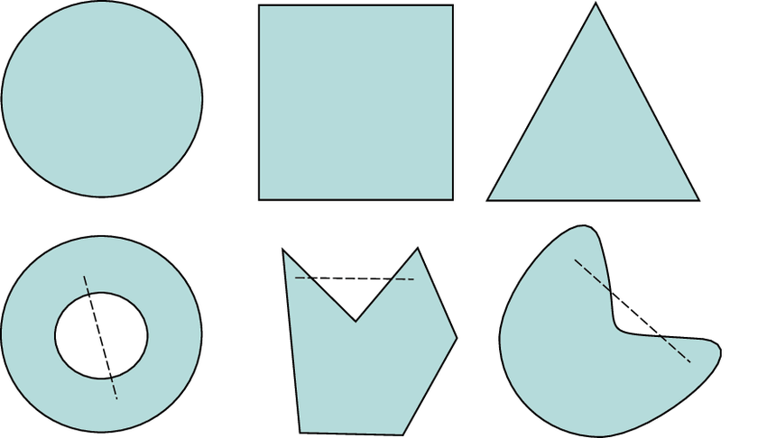

Baris atas: himpunan konveks. Baris bawah: himpunan tak konveks.

Himpunan-himpunan berikut bersifat konveks (buktinya ditinggalkan sebagai latihan):

- Himpunan kosong $\emptyset$.
- Setiap ruang vektor.
- Setiap bola norma; yaitu, untuk setiap norma $\|\emptyarg\|$, setiap $c\in V$, dan setiap $R\geq 0$, himpunan
  $$\begin{equation}
  % Koreksi H02-C002 (sumber baris 80--82): tanda sama dengan
  yang hilang ditambahkan.
  B_{\|\emptyarg\|,R}(c)=\{x\in V\;|\; \|x-c\|<R\}
  \end{equation}$$
  dan
  $$\begin{equation}
  % Koreksi H02-C003 (sumber baris 84--86): tanda sama dengan
  yang hilang ditambahkan.
  \overline{B}_{\|\emptyarg\|,R}(c)=\{x\in V\;|\; \|x-c\|\leq
  R\}.
  \end{equation}$$
- Setiap subruang afin; yaitu, untuk setiap vektor $z,x_1,\dots,x_k\in V$, himpunan
  $$\begin{equation}
  \bigg\{ x\in V\;|\; x = z + \sum_{i=1}^k\lambda_i x_i,\;
  \lambda_i\in \R \bigg\}.
  \end{equation}$$

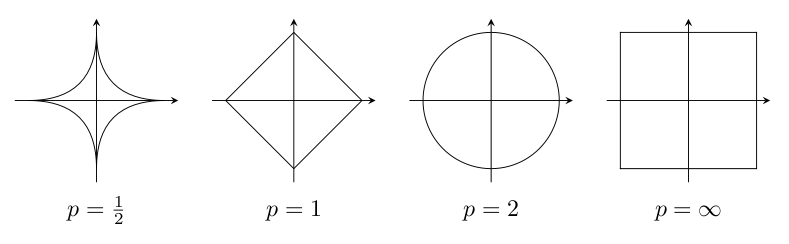

Bola norma $\overline{B}_{\|\emptyarg\|_p,R}(0)$ untuk beberapa norma $\ell^p$. Perhatikan bahwa himpunan untuk $p=1/2$ tidak konveks karena pilihan ini tidak menghasilkan norma: ketaksamaan segitiga tidak berlaku.

**Deskripsi gambar.** Gambar membandingkan bola satuan dua dimensi untuk beberapa nilai $p$. Bentuknya berubah dari belah ketupat melalui lingkaran menuju bentuk yang semakin menyerupai persegi ketika $p$ bertambah; untuk $p=1/2$, sisi-sisinya melengkung ke dalam sehingga himpunannya tidak konveks.

Pernyataan-pernyataan berikut berlaku:

1. Irisan. Misalkan $C_i\subset V$ konveks untuk $i\in I$, dengan $I$ suatu himpunan indeks sembarang. Maka irisan
   $$\begin{equation}
   \bigcap_{i\in I} C_i \coloneqq \{x\in V\;|\; x\in C_i\;
   \forall i\in I\}
   \end{equation}$$
   bersifat konveks.
2. Jumlah berbobot. Misalkan $C_i\subset V$ konveks untuk $i=1,\dots,N$, dan misalkan $\lambda_i\in\R$ untuk $i=1,\dots,N$. Maka himpunan
   $$\begin{equation}
   % Koreksi H02-C004 (sumber baris 108--110): n dan indeks I
   yang tidak didefinisikan diseragamkan menjadi N dan i=1,...,N.
   \sum_{i=1}^N \lambda_i C_i \coloneqq \bigg\{\sum_{i=1}^N
   \lambda_i x_i\;|\; x_i\in C_i\; \forall i=1,\dots,N\bigg\}
   \end{equation}$$
   bersifat konveks.
3. Produk Kartesius. Misalkan $C_i\subset V$ konveks untuk $i\in I$, dengan $I$ suatu himpunan indeks sembarang. Maka produk Kartesius
   $$\begin{equation}
   % Koreksi H02-C029: produk Kartesius memakai simbol produk,
   bukan produk tensor.
   \prod_{i\in I} C_i \coloneqq \{(x_i)_{i\in I}\;|\; x_i\in
   C_i\; \forall i\in I\}
   \end{equation}$$
   bersifat konveks.
4. Citra dan pracitra[^6] di bawah pemetaan linear bersifat konveks. Secara khusus, untuk $A:V\rightarrow W$ linear serta $S\subset V$ dan $T\subset W$ keduanya konveks, himpunan-himpunan berikut bersifat konveks:
   $$\begin{equation}
   % Koreksi H02-C005 (sumber baris 120--122): pracitra diberi
   argumen T dan variabel himpunannya diperbaiki dari y menjadi x.
   A(S)=\{Ax\;|\;x\in S\},\qquad A^{-1}(T)=\{x\in V\;|\;Ax\in
   T\}.
   \end{equation}$$

*Proof.* Kita hanya membuktikan bagian pertama dan meninggalkan sisanya sebagai latihan. Buktinya langsung. Misalkan $x,y\in\bigcap_{i\in I}C_i$ dan $\lambda\in(0,1)$. Karena $x,y\in C_i$ untuk setiap $i$ dan setiap $C_i$ konveks, diperoleh $\lambda x+(1-\lambda)y\in C_i$ untuk setiap $i$. Dengan demikian, $\lambda x+(1-\lambda)y\in\bigcap_{i\in I}C_i$. ◻

Kita hendak mendefinisikan secara formal pengertian hiperbidang, yaitu perumuman bidang dua dimensi di $\R^3$ ke dimensi sembarang.

Misalkan $V$ suatu ruang hasil kali dalam. Hiperbidang adalah himpunan $H$ berbentuk
$$\begin{equation}
H=\{x\in V\;|\;\inner{x}{a}=b\}
\end{equation}$$
untuk suatu $a\in V\setminus\{0\}$ dan $b\in\R$.

Parameter $a$ menentukan orientasi bidang dan $b$ menentukan geserannya. Secara khusus, $0\in H$ jika dan hanya jika $b=0$; dalam kasus ini $H$ merupakan subruang. Jika $b\neq0$, $H$ hanya merupakan subruang afin.

Perhatikan bahwa jika $x_0\in H$, maka
$$\begin{equation}
H=\{x\in V\;|\;\inner{x-x_0}{a}=0\}.
\end{equation}$$
Jadi, $a$ adalah vektor normal terhadap bidang tersebut. Selain itu, dapat diperiksa sebagai latihan bahwa $\frac{|b|}{\|a\|}$ adalah jarak bidang dari titik asal.

Setiap hiperbidang membagi ruang menjadi dua setengah ruang.

Misalkan $V$ suatu ruang hasil kali dalam. Setengah ruang adalah himpunan $H^-$ berbentuk
$$\begin{equation}
H^-=\{x\in V\;|\;\inner{x}{a}\leq b\}
\end{equation}$$
untuk suatu $a\in V\setminus\{0\}$ dan $b\in\R$.

Teorema berikut menyatakan bahwa pemisahan tersebut dapat dipilih dengan cara tertentu. Hasil ini ternyata sangat penting dalam optimisasi dan analisis fungsional.

Misalkan $S,T$ dua himpunan bagian konveks yang tak kosong dan saling lepas dari suatu ruang bernorma real $V$, dan misalkan $S$ terbuka. Maka terdapat $a\in V^*$ yang kontinu dan tak nol serta $\alpha\in\R$ sedemikian sehingga
$$\begin{equation}
\langle a,x\rangle<\alpha\leq\langle a,y\rangle,\qquad x\in
S,\;y\in T.
\end{equation}$$
Jika $S$ dan $T$ keduanya tertutup dan salah satunya kompak, maka terdapat $a\in V^*$ yang kontinu dan tak nol, $\alpha\in\R$, dan $\epsilon>0$ sedemikian sehingga
$$\begin{equation}
\langle a,x\rangle\leq\alpha<\alpha+\epsilon\leq\langle
a,y\rangle,\qquad x\in S,\;y\in T.
\end{equation}$$

Versi kedua memungkinkan kita memperoleh selisih positif tegas antara
$$\sup_{x\in S}\langle a,x\rangle
\quad
\text{dan}
\quad
\inf_{y\in T}\langle a,y\rangle.$$

## Fungsi konveks

Seperti diperlihatkan pada 2.1, kekonveksan sangat memengaruhi pertanyaan tentang keberadaan dan ketunggalan minimum.

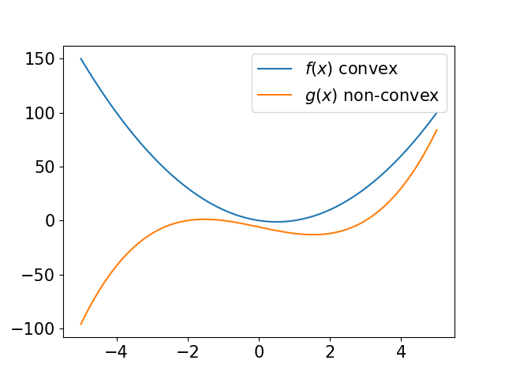

Contoh fungsi konveks dan fungsi tak konveks dalam satu dimensi.

Misalkan $C\subset V$ konveks dan $f:C\rightarrow(-\infty,\infty]$.

- Fungsi $f$ disebut konveks jika dan hanya jika, untuk setiap $x,y\in C$ dan $\lambda\in(0,1)$, berlaku
  $$\begin{equation}
  f(\lambda x+(1-\lambda)y)\leq\lambda f(x)+(1-\lambda)f(y).
  \end{equation}$$
- Fungsi $f$ disebut konveks tegas jika dan hanya jika, untuk setiap $x,y\in\dom(f)$ dengan $x\neq y$ dan setiap $\lambda\in(0,1)$, berlaku
  $$\begin{equation}
  % Koreksi H02-C007 (sumber baris 210--213): syarat x tidak
  sama dengan y ditambahkan; tanpa syarat ini ketaksamaan tegas mustahil
  saat x=y.
  f(\lambda x+(1-\lambda)y)<\lambda f(x)+(1-\lambda)f(y).
  \end{equation}$$
- Fungsi $f$ disebut konveks kuat dengan parameter $\mu>0$ jika dan hanya jika, untuk setiap $x,y\in\dom(f)$ dan $\lambda\in(0,1)$, berlaku
  $$\begin{equation}
  f(\lambda x+(1-\lambda)y)\leq\lambda
  f(x)+(1-\lambda)f(y)-\frac{\lambda(1-\lambda)\mu}{2}\|x-y\|^2.
  \end{equation}$$

Syarat orde nol menyatakan bahwa ruas garis yang menghubungkan dua titik pada grafik, yaitu garis sekan, selalu berada di atas fungsi. Untuk fungsi konveks tegas, garis sekan berada secara tegas di atas fungsi, sedangkan dalam kasus konveks kuat kita bahkan dapat *menyisipkan* fungsi kuadrat di antara keduanya.

Fungsi-fungsi berikut konveks (bukti: latihan):

1. Fungsi afin $f(x)=\langle a,x\rangle+b$ dengan $a\in V^*$ dan $b\in\R$; khususnya, fungsi linear ketika $b=0$.
2. Semua norma merupakan fungsi konveks.

Serupa dengan hasil untuk himpunan konveks, kekonveksan dapat diperluas ke kombinasi konveks dengan banyak titik yang sembarang.

Misalkan $C\subset V$ konveks dan $f:C\rightarrow(-\infty,+\infty]$. Dengan konvensi $0\cdot(+\infty)=0$, fungsi $f$ konveks jika dan hanya jika, untuk setiap $k\in\N$, $\lambda\in\Delta^k$, dan $x_i\in C$, berlaku
$$\begin{equation}
f\bigg(\sum_{i=1}^k\lambda_i x_i\bigg)\leq\sum_{i=1}^k\lambda_i
f(x_i).
\end{equation}$$

Di atas kita melihat bahwa kekonveksan berarti garis sekan berada di atas fungsi. Kekonveksan juga berarti garis singgung berada di bawah fungsi ( 2.2).

Misalkan $C\subset\R^d$ konveks dan $f:C\rightarrow\R$ mempunyai perluasan yang terdiferensialkan secara kontinu pada suatu lingkungan terbuka dari $C$.

- Fungsi $f$ konveks jika dan hanya jika, untuk semua $x,y\in C$,
  $$f(x)+\langle\nabla f(x),y-x\rangle\leq
  f(y).$$
- Fungsi $f$ konveks tegas jika dan hanya jika ketaksamaan di atas berlaku tegas untuk semua $x\neq y$.

*Proof.* Kita terlebih dahulu membuktikan butir pertama.

$\Rightarrow$: Misalkan $f$ konveks. Maka
$$\begin{equation}
f(x+\lambda(y-x))=f(\lambda y+(1-\lambda)x)\leq\lambda
f(y)+(1-\lambda)f(x).
\end{equation}$$
Dengan menyusun ulang, diperoleh
$$\begin{equation}
\frac{f(x+\lambda(y-x))-f(x)}{\lambda}\leq f(y)-f(x).
\end{equation}$$
Membiarkan $\lambda\rightarrow0$ memberikan hasil yang diinginkan.

$\Leftarrow$: Sekarang andaikan syarat gradien berlaku. Tuliskan $x_\lambda=x+\lambda(y-x)$. Maka
$$\begin{equation*}
f(x_\lambda)+\langle\nabla f(x_\lambda),y-x_\lambda\rangle
=f(x_\lambda)+\langle\nabla
f(x_\lambda),(1-\lambda)(y-x)\rangle\leq f(y)
\end{equation*}$$
dan
$$\begin{equation*}
f(x_\lambda)+\langle\nabla f(x_\lambda),x-x_\lambda\rangle
=f(x_\lambda)+\langle\nabla
f(x_\lambda),-\lambda(y-x)\rangle\leq f(x).
\end{equation*}$$
Kalikan ketaksamaan pertama dengan $\lambda$, ketaksamaan kedua dengan $1-\lambda$, lalu jumlahkan. Hasilnya
$$\begin{equation*}
f(x_\lambda)\leq\lambda f(y)+(1-\lambda)f(x).
\end{equation*}$$

Untuk butir kedua, arah dari syarat orde pertama tegas menuju kekonveksan tegas langsung mengikuti argumen yang sama. Sebaliknya, jika $f$ konveks tegas dan $x\neq y$, fungsi satu variabel $g(t)=f(x+t(y-x))$ konveks tegas pada $[0,1]$. Kemiringan sekan $(g(t)-g(0))/t$ tak menurun dalam $t>0$ dan, untuk setiap $t_0\in(0,1)$, bernilai tegas lebih kecil daripada $g(1)-g(0)$. Mengambil limit $t\downarrow0$ memberikan $\langle\nabla f(x),y-x\rangle< f(y)-f(x)$. ◻

Misalkan $f:C\rightarrow\R$ dan $x^*\in C$.

- Titik $x^*$ disebut minimum lokal jika dan hanya jika terdapat $\epsilon>0$ sedemikian sehingga
  $$% Koreksi H02-C009 (sumber baris 328--330):
  pembanding dibatasi pada domain C.
  f(x^*)\leq f(x),\qquad \forall x\in B_\epsilon(x^*)\cap
  C.$$
- Titik $x^*$ disebut minimum global jika dan hanya jika
  $$f(x^*)\leq
  f(x),\qquad \forall x\in C.$$

Minimum disebut *tegas* apabila ketaksamaan yang bersesuaian berlaku tegas untuk semua titik pembanding $x\neq x^*$.

Sekarang kita dapat membuktikan hasil penting pertama dalam optimisasi konveks.

Misalkan $C\subset\R^d$ konveks, $f:C\rightarrow\R$ konveks dan mempunyai perluasan yang terdiferensialkan secara kontinu pada suatu lingkungan terbuka dari $C$, serta $x^*\in C$. Jika $\nabla f(x^*)=0$, maka $x^*$ adalah peminimum **global**.

*Proof.* Berdasarkan karakterisasi orde pertama kekonveksan,
$$\begin{equation}
f(x)\geq f(x^*)+\langle\nabla f(x^*),x-x^*\rangle
=f(x^*)+0.
\end{equation}$$
◻

Perhatikan bahwa kebalikan [convexity:prop:OC1], yaitu implikasi
$$\begin{equation}
\text{$x^*$ adalah minimum}\Rightarrow\nabla f(x^*)=0,
\end{equation}$$
secara umum hanya benar apabila $x^*$ berada di interior $C$, yang dinyatakan dengan $C^\circ$; yaitu, terdapat $\epsilon>0$ sedemikian sehingga $B_\epsilon(x^*)\subset C$.

Misalkan $C\subset\R^d$ konveks, $f:C\rightarrow\R$ konveks dan mempunyai perluasan yang terdiferensialkan secara kontinu pada suatu lingkungan terbuka dari $C$, serta $x^*\in C^\circ$. Maka $\nabla f(x^*)=0$ jika dan hanya jika $x^*$ adalah peminimum global.

*Proof.* Satu arah mengikuti [convexity:prop:OC1]. Untuk arah lainnya, andaikan $x^*$ suatu minimum. Untuk setiap $v\in\R^d$, jika $t>0$ cukup kecil, optimalitas memberikan
$$\begin{equation}
f(x^*+tv)-f(x^*)\geq0.
\end{equation}$$
Karena $t>0$, pembagian dengan $t$ menghasilkan
$$\begin{equation}
\frac{f(x^*+tv)-f(x^*)}{t}\geq0.
\end{equation}$$
Dengan membiarkan $t\rightarrow0$, diperoleh
$$\begin{equation}
\langle\nabla f(x^*),v\rangle\geq0.
\end{equation}$$
Karena $v$ sembarang, argumen yang sama dapat diterapkan pada $-v$. Hasilnya
$$\langle\nabla f(x^*),v\rangle\leq0.$$

Jadi $\langle\nabla f(x^*),v\rangle=0$ untuk setiap $v$, dan karenanya $\nabla f(x^*)=0$ (mengapa?). ◻

Dalam satu dimensi, jika suatu fungsi terdiferensialkan, kekonveksannya dapat dikarakterisasi melalui kemonotonan turunannya. Dalam dimensi sembarang berlaku hasil berikut.

Misalkan $C\subset\R^d$ konveks dan $f:C\rightarrow\R$ mempunyai perluasan yang terdiferensialkan secara kontinu pada suatu lingkungan terbuka dari $C$. Maka $f$ konveks jika dan hanya jika, untuk setiap $x,y\in C$,
$$\begin{equation}
\langle\nabla f(x)-\nabla f(y),x-y\rangle\geq0.
\end{equation}$$

*Proof.* $\Rightarrow$: Andaikan $f$ konveks. Berdasarkan karakterisasi orde pertama kekonveksan,
$$\begin{equation}
\begin{aligned}
&f(x)+\langle\nabla f(x),y-x\rangle\leq f(y),\\
&f(y)+\langle\nabla f(y),x-y\rangle\leq f(x).
\end{aligned}
\end{equation}$$
Menjumlahkan kedua ketaksamaan memberikan hasil yang diinginkan.

$\Leftarrow$: Andaikan $\nabla f$ monoton. Berdasarkan teorema dasar kalkulus,
$$\begin{equation}
\begin{aligned}
f(y)-f(x)
&=\int_0^1\frac{\dd}{\dd t}f(x+t(y-x))\dd t\\
&=\int_0^1\langle\nabla f(x+t(y-x)),y-x\rangle\dd t\\
&=\int_0^1\langle\nabla f(x+t(y-x))-\nabla
f(x),y-x\rangle\dd t+\langle\nabla f(x),y-x\rangle\\
&=\int_0^1\frac{1}{t}\underbrace{\langle\nabla
f(x+t(y-x))-\nabla f(x),t(y-x)\rangle}_{\geq0}\dd t+\langle\nabla
f(x),y-x\rangle\\
&\geq\langle\nabla f(x),y-x\rangle.
\end{aligned}
\end{equation}$$
Pada $t=0$, integran dipahami melalui perpanjangan kontinu; ketaksamaan monoton digunakan untuk $t\in(0,1]$. ◻

Terakhir, turunan kedua juga dapat digunakan untuk mengarakterisasi kekonveksan. Secara intuitif, kekonveksan berarti *kelengkungan positif*. Untuk memformalkan hal ini, ingat kembali cara mengurutkan matriks. Untuk dua matriks simetris $A,B\in\R^{d\times d}$, kita menuliskan
$$\begin{equation}
A\succeq B\Longleftrightarrow\langle x,Ax\rangle\geq\langle
x,Bx\rangle,\quad\forall x\in\R^d
\end{equation}$$
dan, serupa dengan itu,
$$\begin{equation}
% Koreksi H02-C013 (sumber baris 411--413): x=0 dikecualikan dari
urutan positif tegas.
A\succ B\Longleftrightarrow\langle x,Ax\rangle>\langle
x,Bx\rangle,\quad\forall x\in\R^d\setminus\{0\}.
\end{equation}$$

Misalkan $C\subset\R^d$ terbuka dan konveks, serta $f:C\rightarrow\R$ terdiferensialkan secara kontinu dua kali.

1. Fungsi $f$ konveks jika dan hanya jika $\nabla^2f(x)\succeq0$ untuk setiap $x\in C$.
2. Jika $\nabla^2f(x)\succ0$ untuk setiap $x\in C$, maka $f$ konveks tegas.

*Proof.* Kita membuktikan pernyataan pertama dan arah cukup pada pernyataan kedua.

$\Rightarrow$: Andaikan $f$ konveks. Berdasarkan kemonotonan gradien, untuk $t>0$ berlaku
$$\begin{equation}
\frac{\inner{\nabla f(x+tv)-\nabla f(x)}{v}}{t}\geq0.
\end{equation}$$
Dengan membiarkan $t\rightarrow0$, diperoleh
$$\begin{equation}
\langle v,\nabla^2f(x)v\rangle\geq0.
\end{equation}$$
Karena $v$ sembarang, hasilnya mengikuti.

$\Leftarrow$: Andaikan $\nabla^2f\succeq0$. Berdasarkan teorema dasar kalkulus,
$$\begin{equation}
\begin{aligned}
\nabla f(y)-\nabla f(x)
&=\int_0^1\frac{\dd}{\dd t}\nabla f(x+t(y-x))\dd t\\
&=\int_0^1\nabla^2f(x+t(y-x))(y-x)\dd t.
\end{aligned}
\end{equation}$$
Mengambil hasil kali dalam dengan $y-x$ menghasilkan
$$\begin{equation}
\begin{aligned}
% Koreksi H02-C015 (sumber baris 444--449): integran vektor
yang salah pada ruas kanan diganti dengan bentuk kuadratik skalar.
\langle\nabla f(y)-\nabla f(x),y-x\rangle
&=\int_0^1\underbrace{\langle
y-x,\nabla^2f(x+t(y-x))(y-x)\rangle}_{\geq0}\dd t\\
&\geq0.
\end{aligned}
\end{equation}$$
Kemonotonan gradien kini menyiratkan kekonveksan. Untuk membuktikan bagian tegas, tuliskan $d=y-x\neq0$. Jika Hessian positif definit pada setiap titik, maka
$$f(y)-f(x)-\langle\nabla f(x),d\rangle
=\int_0^1\int_0^t
\langle d,\nabla^2f(x+sd)d\rangle\,\dd s\,\dd t>0.$$
Jadi ketaksamaan orde pertama berlaku tegas dan $f$ konveks tegas. ◻

Misalkan $f,f_1,\dots,f_n:C\rightarrow\R$ konveks pada suatu himpunan konveks.

1. Untuk setiap $\alpha\geq0$, fungsi $\alpha f$ konveks.
2. Fungsi $\sum_i f_i$ konveks.

*Proof.* Latihan. ◻

Misalkan $f:\R^n\supset C\rightarrow\R$ konveks, $A\in\R^{n\times m}$, dan $b\in\R^n$. Maka
$$\begin{equation}
g(x)=f(Ax+b)
\end{equation}$$
konveks pada $\{x\in\R^m\;|\;Ax+b\in C\}$.

*Proof.* Latihan. ◻

Misalkan $f:C\rightarrow\R$ konveks dan $g:I\rightarrow\R$ konveks serta tak menurun, dengan $I\subset\R$ suatu interval yang memenuhi $f(C)\subset I$. Maka $g\circ f$ konveks.

*Proof.* Latihan. ◻

Misalkan $f_i:C\rightarrow\R$, $i=1,\dots,n$, konveks pada himpunan konveks $C$. Maka
$$\begin{equation}
f(x)=\max_{i=1,\dots,n}f_i(x)
\end{equation}$$
konveks.

*Proof.* Kita hitung langsung:
$$\begin{equation}
\begin{aligned}
f(\lambda x+(1-\lambda)y)
&=\max_i f_i(\lambda x+(1-\lambda)y)\\
&\leq\max_i\{\lambda f_i(x)+(1-\lambda)f_i(y)\}\\
&\leq\lambda\max_jf_j(x)+(1-\lambda)\max_jf_j(y)\\
&=\lambda f(x)+(1-\lambda)f(y).
\end{aligned}
\end{equation}$$
◻

Misalkan $f:C\times D\rightarrow\R$ konveks pada $C\times D$, dengan $C$ dan $D$ keduanya konveks. Definisikan
$$\begin{equation}
g(x)=\inf_{y\in D}f(x,y),
\end{equation}$$
dan andaikan infimum tersebut hingga untuk setiap $x\in C$. Maka $g$ konveks.

*Proof.* Pilih barisan $y_n^x$ dan $y_n^z$ sedemikian sehingga
$$\begin{equation}
g(x)=\lim_n f(x,y_n^x),\qquad g(z)=\lim_n f(z,y_n^z).
\end{equation}$$
Maka
$$\begin{equation}
\begin{aligned}
g(\lambda x+(1-\lambda)z)
&\leq f(\lambda x+(1-\lambda)z,\lambda
y_n^x+(1-\lambda)y_n^z)\\
&\leq\lambda f(x,y_n^x)+(1-\lambda)f(z,y_n^z).
\end{aligned}
\end{equation}$$
Mengambil limit ketika $n\rightarrow\infty$ menyelesaikan bukti. ◻

Jarak suatu titik ke himpunan tak kosong dan konveks merupakan fungsi konveks. Jadi, untuk setiap himpunan tak kosong dan konveks $C\subset\R^d$, pemetaan berikut konveks:
$$\begin{equation}
\begin{aligned}
x\mapsto d(x,C)\coloneqq\inf_{y\in C}\|x-y\|.
\end{aligned}
\end{equation}$$

Misalkan $C\subset\R^d$ konveks dan $f:C\rightarrow\R$. Maka $f$ konveks jika dan hanya jika, untuk setiap $x\in C$ dan $v\in\R^d$, fungsi
$$\begin{equation}
\begin{aligned}
g:I_{x,v}&\rightarrow\R,\\
t&\mapsto g(t)=f(x+tv),
\end{aligned}
\end{equation}$$
konveks pada interval $I_{x,v}\coloneqq\{t\in\R\mid x+tv\in C\}$.

*Proof.* $\Leftarrow$: Andaikan $g$ konveks untuk setiap $x$ dan $v$. Misalkan $x,y\in C$ dan $\lambda\in(0,1)$. Pertimbangkan
$$\begin{equation}
g(t)=f(y+t(x-y)).
\end{equation}$$
Karena $g$ konveks pada interval yang memuat $0$ dan $1$,
$$\begin{equation}
\begin{aligned}
f(\lambda x+(1-\lambda)y)
=g(\lambda)
&=g(\lambda\cdot1+(1-\lambda)\cdot0)\\
&\leq\lambda g(1)+(1-\lambda)g(0)\\
&=\lambda f(x)+(1-\lambda)f(y).
\end{aligned}
\end{equation}$$
Arah sebaliknya ditinggalkan sebagai latihan. ◻

- Contoh pada $\R$:
  - Fungsi konveks:
    - Fungsi eksponensial $f(x)=\exp(ax)$ pada $\R$, dengan $a\in\R$.
    - Fungsi pangkat $f(x)=x^p$ pada $(0,\infty)$ untuk $p\geq1$ atau $p\leq0$.
    - Pangkat nilai mutlak $f(x)=|x|^p$ pada $\R$ untuk $p\geq1$.
    - Entropi negatif $f(x)=x\log(x)$ pada $(0,\infty)$.
  - Fungsi konkaf:
    - Fungsi pangkat $f(x)=x^p$ pada $(0,\infty)$ untuk $0\leq p\leq1$.
    - Logaritma $f(x)=\log(x)$ pada $(0,\infty)$.
- Contoh pada ruang Euklides berdimensi hingga:
  - Fungsi konveks:
    - Norma-$p$, $f(x)=\|x\|_p$.
    - Pangkat norma-$p$, $f(x)=\|x\|_p^p$, untuk $1\leq p<\infty$.
    - Kuadrat terkecil, $f(x)=\frac12\|Ax-b\|_2^2$, dengan $A\in\R^{m\times n}$ dan $b\in\R^m$.
    - Maksimum fungsi-fungsi afin:
      $$f(x)=\max\{\inner{a_1}{x}+b_1,\ldots,\inner{a_m}{x}+b_m\},$$
      dengan $a_i\in\R^n$ dan $b_i\in\R$.
    - Perspektif suatu fungsi, $f(x,y)=yg(x/y)$, dengan $g:\R^n\rightarrow\R$ fungsi konveks, $x\in\R^n$, dan $y\in(0,\infty)$. Jadi domain perspektif ini adalah $\R^n\times(0,\infty)$.
  - Fungsi konkaf:
    - Minimum fungsi-fungsi afin:
      $$f(x)=\min\{\inner{a_1}{x}+b_1,\ldots,\inner{a_m}{x}+b_m\}.$$
- Contoh pada $\R^{m\times n}$:
  - Fungsi konveks:
    - Fungsi afin
      $$f(X)=\tr(A^\top
      X)+b=\sum_{i=1}^m\sum_{j=1}^n A_{ij}X_{ij}+b$$
      pada $\R^{m\times n}$, dengan $A\in\R^{m\times n}$ dan $b\in\R$.
    - Norma spektral $f(X)=\|X\|_2=\sigma_{\text{max}}(X)=\sqrt{\lambda_{\text{max}}(X^\top X)}$.
    - Fungsi penghalang untuk matriks definit positif, $f(X)=-\log\det X$ pada $\mathbb{S}_{++}^n$.

Serupa dengan hasil-hasil di atas, kita dapat menunjukkan karakterisasi kekonveksan kuat berikut.

Misalkan $f:C\rightarrow\R$, dengan $C\subset\R^d$ konveks, serta $\mu>0$. Karakterisasi berikut berlaku:

- Fungsi $f$ konveks kuat berparameter $\mu$ jika dan hanya jika $f-\frac{\mu}{2}\|\emptyarg\|^2$ konveks.
- *Syarat orde pertama*: jika $f$ mempunyai perluasan yang terdiferensialkan secara kontinu pada suatu lingkungan terbuka dari $C$, maka $f$ konveks kuat berparameter $\mu$ jika dan hanya jika, untuk setiap $x,y\in C$,
  $$f(x)+\inner{\nabla f(x)}{y-x}\leq
  f(y)-\frac{\mu}{2}\|x-y\|^2.$$
- *Syarat orde kedua*: jika $C$ terbuka dan $f$ terdiferensialkan secara kontinu dua kali pada $C$, maka $f$ konveks kuat berparameter $\mu$ jika dan hanya jika, untuk setiap $x\in C$,
  $$\nabla^2 f(x)\succeq\mu I.$$

*Proof.* Buktinya merupakan penyesuaian langsung dari bukti untuk kekonveksan biasa dan ditinggalkan sebagai latihan. ◻

# Subgradien

Ingat kembali definisi turunan (Fréchet).

Sepanjang bab ini, $X$ dan $Y$ menyatakan ruang bernorma real; apabila gradien digunakan, $X$ merupakan ruang Hilbert. Setiap kali $V$ atau $W$ muncul, keduanya menyatakan ruang bernorma real berdimensi hingga. Pada pasangan dual, argumen pertama selalu fungsional dan argumen kedua selalu vektor.

Misalkan $f:X\rightarrow Y$. Fungsi $f$ dikatakan terdiferensialkan (dalam arti Fréchet) di $x\in X$ apabila terdapat pemetaan linear kontinu $A:X\rightarrow Y$ sedemikian sehingga
$$\begin{equation}
\lim_{\|h\|\rightarrow 0}\frac{\| f(x+h) - f(x) -Ah\|}{\|h\|}=
0.
\end{equation}$$
Kita menuliskan $A=Df(x)$.

Misalkan $f:X\rightarrow \R$ terdiferensialkan dan $X$ merupakan ruang Hilbert. Gradien $f$ di titik $x$, yang dilambangkan dengan $\nabla f(x)$, adalah unsur tunggal di $X$ sedemikian sehingga
$$\begin{equation}
Df(x)h = \inner{\nabla f(x)}{h}, \quad h\in X.
\end{equation}$$

Keberadaan dan ketunggalan gradien merupakan akibat langsung dari teorema representasi Riesz, sebab $Df(x)\in X^*$ apabila $f$ bernilai real. Perhatikan pula bahwa **gradien bergantung pada hasil kali dalam yang dipilih**.

Walaupun definisi umum di atas mungkin tampak agak abstrak, gradien yang kita temui biasanya cukup sederhana. Secara khusus, apabila $X=\R^d$ dilengkapi dengan hasil kali dalam Euklides baku, maka
$$\begin{equation}
\nabla f(x) = Df(x)^T,
\end{equation}$$
, gradien hanyalah transpos dari turunannya.

Turunan dapat ditafsirkan sebagai hampiran linear terbaik terhadap fungsi di suatu titik, yakni
$$\begin{equation}
f(y) = f(x) + Df(x)(y-x) + o(\|y-x\|),
\end{equation}$$
dengan $o$ kecil menyatakan suatu suku yang meluruh *lebih cepat daripada laju linear*. Kebanyakan metode optimisasi dapat ditafsirkan sebagai proses berulang untuk meminimumkan hampiran fungsi yang lebih mudah. Akan tetapi, banyak fungsi penting tidak memiliki gradien dalam pengertian di atas. Sebagai contoh, kita mungkin ingin menyelesaikan persoalan
$$\begin{equation}
\min\limits_x \frac{1}{2}\|Ax-b\|^2_2 + \lambda\|K x\|_1,
\end{equation}$$
dengan $A$ dan $K$ linear. Persoalan komposit semacam ini sangat umum dalam pengolahan citra. Karena itu, kita dapat bertanya apakah terdapat gagasan hampiran linear yang lebih umum tetapi memiliki sifat serupa dengan gradien. Definisi berikut menjawab pertanyaan ini secara positif.

Misalkan $f:X\rightarrow(-\infty,\infty]$ dan $x\in\dom(f)$. Kita menyebut $g\in X^*$ sebagai *subgradien* $f$ di $x$ apabila
$$\begin{equation}
f(x) + \langle g, y-x\rangle\leq f(y), \quad \forall y\in X.
\end{equation}$$
Subdiferensial $\partial f(x)$ di $x$ adalah himpunan semua subgradien di $x$, yakni
$$\begin{equation}
\partial f(x) =\{ g\in X^*\;|\; f(x) + \langle g, y-x\rangle\leq
f(y), \quad \forall y\in X \}.
\end{equation}$$
Untuk $x\notin\dom(f)$, kita menetapkan $\partial f(x)=\emptyset$.

Jadi, subdiferensial dapat saja kosong; menurut konvensi di atas, subdiferensial kosong di setiap titik $x\in X$ dengan $f(x)=\infty$.

1. Norma: Misalkan $f = \norm{\cdot}$. Maka
   $$\partial f(0) =
   \overline{B}_{\|\cdot\|_*, 1}(0),$$
   yaitu bola satuan untuk norma dual. Ingat bahwa norma dual $\|\cdot\|_*$ didefinisikan oleh
   $$\|y\|_* = \sup_{\|x\|\leq 1} |\langle
   y,x\rangle|.$$
   Sebagai contoh, apabila $f = \|\cdot\|_1$ pada $\R^n$, maka
   $$\partial f(0) =
   \overline{B}_{\|\cdot\|_\infty,1}(0) = [-1,1]^n.$$
2. Untuk suatu himpunan tak kosong $S \subseteq X$ dan titik $x \in S$, tinjau fungsi indikator $\delta_S$. Subdiferensialnya adalah
   $$\partial\delta_S(x)=\left\{y\in
   X^\ast:\inner{y}{z-x}\leq 0,\;\forall z\in S\right\}\eqqcolon
   N_S(x),$$
   yang disebut *kerucut normal* $S$ di $x$. Subdiferensial fungsi indikator dari bola satuan adalah
   $$N_{\overline{B}_{\|\cdot\|, 1}(0)}(x)=
   \begin{cases}
   \{y\in X^\ast\mid\|y\|_*\leq
   \inner{y}{x}\}&\text{jika }\norm{x}\leq 1,\\
   \emptyset&\text{jika }\norm{x}>1.
   \end{cases}$$

Kita perlu memastikan bahwa subdiferensial benar-benar memperumum gradien biasa.

Misalkan $f:X\rightarrow \R$ konveks dan terdiferensialkan di $x\in \dom(f)^\circ$, dengan $X$ ruang Hilbert. Maka $\partial f(x) = \{\nabla f(x)\}$.

*Proof.* Kita perlu menunjukkan (i) $\nabla f(x)\in \partial f(x)$ dan (ii) jika $g\in\partial f(x)$, maka $g=\nabla f(x)$. Bagian (i) langsung mengikuti karakterisasi orde pertama untuk fungsi konveks terdiferensialkan, yang memberikan
$$\begin{equation}
f(x) + \inner{\nabla f(x)}{y-x}\leq f(y),\quad y\in X,
\end{equation}$$
sehingga $\nabla f(x)\in\partial f(x)$. Untuk (ii), menurut definisi subgradien, bagi setiap $g\in\partial f(x)$, $h\in X$, dan $t>0$ yang cukup kecil sehingga $x+th\in\dom(f)$, berlaku
$$\begin{equation}
\inner{g}{h}\leq \frac{f(x+th)-f(x)}{t}.
\end{equation}$$
Dengan mengambil limit $t\rightarrow 0$, diperoleh $\inner{g}{h}\leq \inner{\nabla f(x)}{h}$. Menerapkan ketaksamaan yang sama pada $-h$ memberikan ketaksamaan sebaliknya. Karena itu $\inner{g}{h}= \inner{\nabla f(x)}{h}$ untuk setiap $h$, sehingga $g=\nabla f(x)$. ◻

Dalam dimensi hingga, kebalikannya juga berlaku bagi fungsi konveks yang hingga pada suatu lingkungan titik $x$: jika subdiferensial di $x$ hanya terdiri atas satu unsur, maka $f$ terdiferensialkan di $x$ dan $\partial f(x) = \{\nabla f(x)\}$.

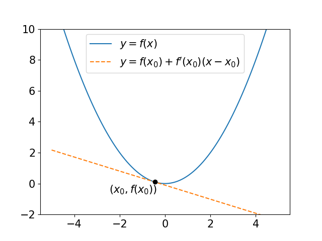

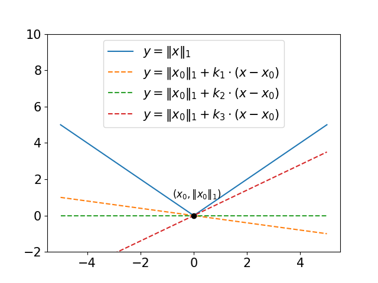

Kiri: gradien sebagai kemiringan garis singgung. Kanan: sebuah subgradien sebagai kemiringan garis pendukung.

**Deskripsi gambar.** Panel kiri memperlihatkan parabola halus dan satu garis singgung putus-putus pada titik yang ditandai. Panel kanan memperlihatkan grafik berbentuk V untuk norma satu dimensi dan tiga garis pendukung dengan kemiringan berbeda yang semuanya melalui titik sudut yang ditandai. Label matematis pada kedua figur dipertahankan persis dari aset sumber.

1. Untuk $f(x)=\|x\|_2$, diperoleh
   $$\partial f(x)
   = \begin{cases}
   \{\frac{x}{\|x\|_2}\}\quad& x\neq 0,\\
   \overline{B}_{\|\cdot\|_2,1}(0)\quad&\text{selain
   itu}.
   \end{cases}$$
2. Khususnya, untuk $d=1$ dan $f(x)=|x|$, diperoleh
   $$\partial f(x)
   = \begin{cases}
   \{\sign(x)\}\quad& x\neq 0,\\
   [-1,1]\quad&\text{selain itu}.
   \end{cases}$$

Jika domain $f:X\rightarrow(-\infty,\infty]$ konveks dan subdiferensialnya tak kosong di setiap titik dalam domain, maka $f$ konveks.

*Proof.* Misalkan $x,y\in \dom f$, $\lambda\in (0,1)$, dan $g\in \partial f(x+\lambda (y-x))$. Menurut definisi subdiferensial,
$$\begin{gather}
f(x+\lambda(y-x)) + \langle g, x - (x+\lambda(y-x))\rangle \leq
f(x),\\
f(x+\lambda(y-x)) + \langle g, y - (x+\lambda(y-x))\rangle \leq
f(y),
\end{gather}$$
atau, setara dengan itu,
$$\begin{gather}
f(x+\lambda(y-x)) + \langle g, -\lambda(y-x)\rangle \leq f(x),\\
f(x+\lambda(y-x)) + \langle g, (1-\lambda)(y - x) \rangle \leq
f(y).
\end{gather}$$
Dengan membagi ketaksamaan pertama oleh $\lambda$, membagi yang kedua oleh $1-\lambda$, lalu menjumlahkannya, diperoleh
$$\begin{equation}
\begin{aligned}
\frac{1}{\lambda} f(x+\lambda(y-x)) + \frac{1}{1-\lambda}
f(x+\lambda(y-x))\leq \frac{1}{\lambda} f(x) + \frac{1}{1-\lambda} f(y).
\end{aligned}
\end{equation}$$
Mengalikan dengan $\lambda (1-\lambda)$ menghasilkan
$$\begin{equation}
\begin{aligned}
f(x+\lambda(y-x)) \leq (1-\lambda) f(x) + \lambda f(y),
\end{aligned}
\end{equation}$$
sebagaimana yang diperlukan. ◻

Seperti disebutkan di atas, subdiferensial dapat kosong. Namun, bagi fungsi konveks berdimensi hingga kita mempunyai jaminan berikut.

Fungsi bernilai real diperluas disebut *sejati (proper)* apabila domain efektifnya tidak kosong dan fungsi itu tidak pernah bernilai minus tak hingga.

Misalkan $X$ ruang bernorma real berdimensi hingga dan $f:X\rightarrow\overline{\R}$ sejati dan konveks. Maka $\partial f(x)\neq \emptyset$ untuk setiap $x\in \dom(f)^\circ$.

Sebelum membuktikan hasil ini, kita memerlukan beberapa persiapan.

Interior suatu himpunan konveks adalah konveks.

*Proof.* Misalkan $C$ konveks. Jika $C^\circ=\emptyset$, tidak ada yang perlu dibuktikan; jadi anggap $C^\circ\neq \emptyset$. Ambil $x,y\in C^\circ$ dan $\lambda\in (0,1)$. Kita perlu menunjukkan bahwa $x_\lambda\coloneqq\lambda x + (1-\lambda)y\in C^\circ$. Terdapat $\epsilon>0$ sedemikian sehingga $B_\epsilon(x),B_\epsilon(y)\subset C^\circ$. Sekarang ambil $z\in B_{\epsilon}(x_\lambda)$. Dengan demikian, $z=x_\lambda + h$ untuk suatu $\|h\|<\epsilon$. Kita dapat menuliskan
$$\begin{equation}
z = \lambda x + (1-\lambda)y + h = \lambda (x+h) + (1-\lambda)(y
+ h).
\end{equation}$$
Karena $x+h\in B_\epsilon(x)\subset C$ dan $y+h\in B_\epsilon(y)\subset C$, kekonveksan $C$ memberikan $z\in C$. Jadi $B_\epsilon(x_\lambda)\subset C$ dan $x_\lambda\in C^\circ$. ◻

Jika $C\subset\R^d,\ d\geq 1$ konveks dan $C^\circ=\emptyset$, maka terdapat hiperbidang $H$ sedemikian sehingga $C\subset H$.

*Proof.* Jika $C$ kosong, sembarang hiperbidang memenuhi kesimpulan. Selanjutnya anggap $C$ tak kosong. Tanpa mengurangi keumuman, kita boleh menganggap $0\in C$. Jika tidak, pilih sembarang $x_0\in C$ dan tinjau $\widetilde{C}=C-x_0$; pada akhir bukti, hiperbidang yang diperoleh ditranslasikan kembali.

Kita akan menunjukkan bahwa $C$ merupakan himpunan bagian suatu subruang berdimensi paling besar $d-1$. Andaikan sebaliknya bahwa $C$ memuat $d$ unsur yang bebas linear, yaitu terdapat $x_1,\dots,x_d\in C$ yang bebas linear. Karena $C$ konveks, selubung konveks
$$\begin{equation}
\conv((x_i)_i)=\bigg\{ \sum_{i=1}^d\lambda_i x_i\;\bigg|\;
\lambda\in \Delta^d\bigg\}
\end{equation}$$
juga merupakan himpunan bagian $C$. Kita mengklaim bahwa $x_\star\coloneqq\frac{1}{2d}\sum_{i=1}^d x_i\in C^\circ$. Pertama, dari kekonveksan,
$$x_\star=\frac{1}{2d}\sum_{i=1}^d x_i =
\sum_{i=1}^d \frac{1}{2d} x_i + \frac{1}{2}0 \in C.$$
Karena $x_i$ bebas linear, setiap $h\in\R^d$ dapat ditulis sebagai $h=\sum_i \lambda_i x_i$. Pemetaan $\lambda\mapsto h$ adalah pemetaan linear bijektif $\R^d\rightarrow\R^d$. Oleh karena itu terdapat $\epsilon>0$ sedemikian sehingga $\|h\|<\epsilon$ mengakibatkan $|\lambda_i|<\frac{1}{2d}$ untuk semua $i$. Khususnya, $\frac{1}{2d}+\lambda_i\in[0,1]$ dan $\sum_{i=1}^d(\frac{1}{2d}+\lambda_i)\in[0,1]$. Akibatnya, untuk setiap $\|h\|<\epsilon$,
$$\begin{equation}
x_\star+h = \sum_{i=1}^d \big(\frac{1}{2d} + \lambda_i\big) x_i
+ \bigg(1 - \sum_i\big(\frac{1}{2d} + \lambda_i\big) \bigg)0\in C.
\end{equation}$$
Jadi, apabila $C$ memuat $d$ unsur bebas linear, interiornya tidak mungkin kosong, sebab $B_\epsilon(x_\star)\subset C$. Ini bertentangan dengan asumsi. Maka $C$ memuat paling banyak $d-1$ unsur bebas linear. Pilih himpunan bebas linear maksimal $x_1,\dots,x_k$ di dalam $C$; maksimalitas memberikan
$$C\subset \span \{ x_i\mid i=1,\dots,k\}.$$
Dimensi subruang ini kurang dari $d$, sehingga subruang tersebut termuat dalam suatu hiperbidang. Setelah translasi balik bila diperlukan, diperoleh hiperbidang afin yang memuat himpunan semula. ◻

Dengan kedua hasil sebelumnya, kita dapat membuktikan teorema hiperbidang pendukung.

Misalkan $V$ ruang bernorma real berdimensi hingga, $C\subset V$ tak kosong dan konveks, serta $x_0\in \partial C = \overline{C}\setminus C^\circ$[^7]. Maka terdapat $a\in V^*$, $a\neq 0$, sedemikian sehingga
$$\begin{equation}
\label{subgradient:eq:supporting}
\inner{a}{v}\leq \inner{a}{x_0},\quad v\in C.
\end{equation}$$

*Proof.* Hasil ini merupakan akibat teorema pemisahan Hahn–Banach. Kita membedakan dua kasus. Pertama, andaikan $C^\circ\neq \emptyset$. Himpunan $C^\circ$ terbuka, konveks, dan tak kosong. Teorema pemisahan Hahn–Banach dapat diterapkan pada $C^\circ$ dan $\{x_0\}$, sehingga ketaksamaan pendukung berlaku pada interior. Karena $C\subset\overline{C^\circ}$ dan fungsional pemisah kontinu, ketaksamaan itu meluas ke seluruh $C$.

Sebaliknya, jika $C^\circ$ kosong, lema sebelumnya memberikan hiperbidang afin $H$ yang memuat $C$. Karena $H$ tertutup dan $x_0\in\overline C$, hiperbidang ini juga memuat titik batas tersebut. Ambil $a\in V^*$ yang tak nol dan $b\in\R$ sedemikian sehingga
$$H=\{x\mid \inner{a}{x} = b\}.$$
Fungsional $a$ ini memenuhi [subgradient:eq:supporting]. ◻

Sekarang kita dapat membuktikan keberadaan subgradien.

*Bukti [convexity:thm:nonempty_subgrad].* Kita ingin menunjukkan bahwa terdapat $g\in X^*$ sedemikian sehingga
$$\begin{equation}
f(x)+\inner{g}{y-x}\leq f(y)
\end{equation}$$
untuk semua $y\in X$. Ini setara dengan
$$\begin{equation}
\label{subgrad:eq:nonempty_subdiff1}
\inner{g}{y} - f(y)\leq \inner{g}{x} - f(x).
\end{equation}$$
Bentuk ini menyerupai struktur pemisahan Hahn–Banach. Agar dapat menggunakannya, kita beralih ke epigraf. Perhatikan bahwa $(x,f(x))\in \partial \epi(f)$. Selain itu, kekonveksan $f$ mengakibatkan $\epi(f)$ konveks. Dengan menerapkan teorema hiperbidang pendukung, diperoleh unsur tak nol $(g,-\alpha)\in (X\times\R)^* = X^*\times\R$ sedemikian sehingga[^8]
$$\begin{equation}
\label{subgrad:eq:nonempty_subdiff2}
\inner{(g,-\alpha)}{(y,t)}\leq
\inner{(g,-\alpha)}{(x,f(x))},\quad (y,t)\in \epi(f).
\end{equation}$$
Ini setara dengan
$$\begin{equation}
\inner{g}{y}-\alpha t \leq \inner{g}{x} - \alpha f(x),\quad
(y,t)\in \epi(f).
\end{equation}$$
Kita akan menunjukkan bahwa $\alpha>0$. Andaikan $\alpha<0$. Karena $(x,t)\in \epi(f)$ untuk setiap $t>f(x)$, kita dapat membiarkan $t\rightarrow \infty$ dan memperoleh kontradiksi. Berikutnya, andaikan $\alpha=0$. Maka
$$\begin{equation}
\inner{g}{y-x} \leq 0
\end{equation}$$
bagi semua $y\in\dom(f)$. Karena $x\in \dom(f)^\circ$, hal ini memaksa $g=0$. Padahal teorema pemisahan menghasilkan unsur pemisah yang tak nol; sekali lagi kita memperoleh kontradiksi. Jadi $\alpha>0$, dan kita dapat membagi [subgrad:eq:nonempty_subdiff2] dengan $\alpha$ untuk memperoleh
$$\begin{equation}
\inner{\widetilde{g}}{y} - t \leq \inner{\widetilde{g}}{x} -
f(x),\quad (y,t)\in \epi(f),
\end{equation}$$
dengan $\widetilde{g} = g/\alpha$. Memilih $t=f(y)$ memberikan $\widetilde{g}\in\partial f(x)$. ◻

Seperti pada turunan biasa, kita dapat menurunkan beberapa aturan hitung untuk memperoleh subgradien dalam praktik.

Misalkan $f:V\rightarrow\R$ sejati dan konveks serta $\alpha\geq 0$. Maka, untuk setiap $x\in\dom(f)$,
$$\partial(\alpha f)(x) = \alpha\partial
f(x).$$

*Proof.* Latihan. ◻

Misalkan $f,g:V\rightarrow\R$ sejati dan konveks. Untuk setiap $x\in\dom(f)\cap\dom(g)$, berlaku
$$\partial f(x) + \partial g(x)\subset \partial
(f+g)(x).$$
Selain itu, jika terdapat $x_0\in \dom(f)^\circ \cap\dom(g)$, maka
$$\partial f(x) + \partial g(x) = \partial
(f+g)(x).$$

*Proof.* Kita hanya membuktikan inklusi pertama. Bukti arah kedua sedikit lebih rumit dan menggunakan teorema pemisahan Hahn–Banach dengan cara yang serupa dengan bukti keberadaan subgradien.

Ambil $p_1\in \partial f(x)$ dan $p_2\in \partial g(x)$, yaitu
$$\begin{equation}
\begin{aligned}
f(x) + \langle p_1, y-x\rangle&\leq f(y),\\
g(x) + \langle p_2, y-x\rangle&\leq g(y).
\end{aligned}
\end{equation}$$
Menjumlahkan kedua ketaksamaan memberikan
$$\begin{equation}
\begin{aligned}
f(x)+ g(x) + \langle p_1+p_2, y-x\rangle \leq f(y) + g(y),
\end{aligned}
\end{equation}$$
sehingga $p_1+p_2\in \partial(f+g)(x)$. ◻

Terakhir, kita mencatat beberapa *aturan hitung* subdiferensial tanpa bukti.

Misalkan $f:W\rightarrow\Rb$ sejati, konveks, dan semikontinu bawah, serta $A:V\rightarrow W$ transformasi linear. Definisikan $h(x)=f(Ax+b)$ untuk $b\in W$. Bagi setiap $x\in\dom(h)$ berlaku aturan lemah
$$A^\ast(\partial f(Ax+b))\subseteq\partial
h(x).$$
Kesamaan berlaku apabila terdapat $x_0\in V$ dengan $Ax_0+b\in\dom(f)^\circ$.

Turunan komposisi fungsi-fungsi terdiferensialkan dihitung dengan aturan rantai. Jadi, turunan $h(x)=g(f(x))$ adalah $D h(x) = Dg(f(x))Df(x)$. Rumus ini dapat diperluas ke kalkulus subdiferensial.

Misalkan $f:V\rightarrow \R$ konveks, $g:\R\rightarrow \R$ konveks dan tak menurun, serta $h=g\circ f$. Ambil $x\in\dom(f)^\circ$ dan andaikan $g$ terdiferensialkan di $f(x)$. Maka
$$\partial h(x)= g'(f(x))\partial
f(x).$$

Misalkan $f:V\to(-\infty, \infty]$ fungsi konveks sejati. Maka
$$x^\ast\in\arg\min_{x\in V} f(x)$$
jika dan hanya jika $0\in\partial f(x^\ast)$.

*Proof.* Pernyataan ini langsung mengikuti ketaksamaan subgradien
$$f(x)\geq
f(x^\ast)+\inner{0}{x-x^\ast}$$
bagi setiap $x\in\dom f$. ◻

Misalkan $f:V\rightarrow(-\infty,\infty]$ sejati dan konveks, serta $C\subseteq V$ konveks dengan $\dom(f)^\circ\cap C^\circ \neq\emptyset$. Titik $x^\ast\in C$ merupakan solusi persoalan optimisasi berkendala jika dan hanya jika terdapat $g\in \partial f(x^\ast)$ sedemikian sehingga
$$\inner{g}{x-x^\ast}\geq 0$$
bagi semua $x\in C$.

# Penurunan subgradien terproyeksi

Misalkan $V$ ruang Hilbert real, $C\subset V$ himpunan tak kosong, tertutup, dan konveks, serta $f:V\rightarrow\R$ fungsi konveks. Kita tertarik menyelesaikan masalah
$$\begin{equation}
\min_{x\in C} f(x).
\end{equation}$$
Kita mengasumsikan bahwa himpunan peminim tidak kosong dan menetapkan $x^*\in\arg\min_{x\in C}f(x)$. Masalah berkendala di atas selalu dapat ditulis sebagai masalah tak berkendala melalui
$$\begin{equation}
\min_{x\in V} f(x) + \delta_C(x),
\end{equation}$$
dengan $\delta_C$ fungsi indikator himpunan $C$.[^9]

Ingat kembali metode optimisasi numerik paling dasar untuk masalah semacam ini ketika $C=V$ dan $f$ terdiferensialkan: penurunan gradien (atau penurunan *tercuram*). Kita memilih nilai awal $x_0$, lalu untuk $k=0,1,\dots$ melakukan pembaruan
$$\begin{equation}
x_{k+1} = x_k-\tau_k \nabla f(x_k),
\end{equation}$$
dengan $\tau_k>0$ menyatakan ukuran langkah. Algoritma *baru* pertama yang kita tinjau ialah versi subgradien dari penurunan tercuram: untuk $k=0,1,\dots$,
$$\begin{equation}
\begin{cases}
g_k &\in \partial f(x_k),\\
x_{k+1} &= x_k-\tau_k g_k.
\end{cases}
\end{equation}$$
Jika $C\neq V$, masalah segera dapat muncul: mungkin saja $x_{k+1}\notin C$. Dalam hal itu, iterasi yang memakai subdiferensial $f+\delta_C$ tidak lagi terdefinisi karena $\partial\delta_C(x)=\emptyset$ untuk $x\notin C$. Karena itu, kita perlu memastikan setiap iterasi baru tetap berada di $C$; untuk tujuan ini kita memakai *proyeksi*.

Misalkan $V$ ruang Hilbert real dan $C\subset V$ tak kosong, tertutup, dan konveks. Fungsi berikut terdefinisi dengan baik:
$$\begin{equation}
\begin{aligned}
\proj_C:V&\rightarrow C,\\
x&\mapsto\arg\min_{y\in C}\|x-y\|.
\end{aligned}
\end{equation}$$

*Proof.* Kita perlu menunjukkan bahwa minimum tercapai secara tunggal. Tetapkan $d=\inf_{y\in C}\|y-x\|$, dan ambil barisan peminimum $(y_n)_n\subset C$, yaitu
$$\begin{equation}
\lim_n \|y_n-x\| = d.
\end{equation}$$
Karena $C$ konveks, $(y_n+y_m)/2\in C$. Identitas jajaran genjang memberi
$$\|y_n-y_m\|^2
=2\|y_n-x\|^2+2\|y_m-x\|^2
-4\left\|\frac{y_n+y_m}{2}-x\right\|^2
\leq 2\|y_n-x\|^2+2\|y_m-x\|^2-4d^2.$$
Ruas kanan menuju nol ketika $m,n\rightarrow\infty$, sehingga $(y_n)_n$ merupakan barisan Cauchy. Kelengkapan $V$ menghasilkan $y_n\rightarrow\widehat y\in V$, sedangkan ketertutupan $C$ menghasilkan $\widehat y\in C$. Dari kontinuitas norma diperoleh
$$\begin{equation}
\|\widehat y-x\| = \lim_n \|y_n-x\| = d,
\end{equation}$$
jadi peminim memang ada.

Untuk ketunggalan, andaikan $y_1\neq y_2$ keduanya peminim. Identitas jajaran genjang memberikan
$$\begin{equation}
\begin{aligned}
\left\|\frac{y_1+y_2}{2}-x\right\|^2
&=\frac{1}{2}\|y_1-x\|^2+\frac{1}{2}\|y_2-x\|^2
-\frac{1}{4}\|y_1-y_2\|^2\\
&<d^2.
\end{aligned}
\end{equation}$$
Namun $(y_1+y_2)/2\in C$, yang bertentangan dengan definisi $d$. Jadi peminimnya tunggal. ◻

Dengan proyeksi, kita memperoleh cara mengatasi masalah *keluar* dari $C$: metode subgradien terproyeksi. Pilih $x_0\in C$; kemudian, untuk $k=0,1,\dots$ dan $\tau_k\geq0$, tetapkan
$$\begin{equation}
\label{subgradient:eq:projectedSG}
\begin{cases}
g_k &\in \partial f(x_k),\\
x_{k+1} &= \proj_C( x_k-\tau_k g_k) .
\end{cases}
\end{equation}$$
Untuk membuktikan konvergensi metode ini, kita memerlukan beberapa hasil bantu.

Misalkan $V$ ruang Hilbert real dan $C\subset V$ tak kosong, tertutup, dan konveks. Maka
$$\begin{equation}
\inner{x-\proj_C(x)}{y-\proj_C(x)}\leq 0,\quad y\in C.
\end{equation}$$
Khususnya, jika $C$ subruang,[^10] maka
$$\begin{equation}
\inner{x-\proj_C(x)}{y}= 0,\quad y\in C.
\end{equation}$$

*Proof.* Untuk setiap $y\in C$, kita mempunyai
$$\begin{equation}
\begin{aligned}
\|\proj_C(x)-x\|^2
&\leq \|y-x\|^2\\
&= \|y - \proj_C(x) + \proj_C(x)-x\|^2\\
&= \|y-\proj_C(x)\|^2
+ 2 \inner{y-\proj_C(x)}{\proj_C(x)-x}
+ \|\proj_C(x)-x\|^2.
\end{aligned}
\end{equation}$$
Akibatnya,
$$\begin{equation}
\begin{aligned}
0\leq \|y-\proj_C(x)\|^2
+ 2 \inner{y-\proj_C(x)}{\proj_C(x)-x}.
\end{aligned}
\end{equation}$$
Ambil sebarang $z\in C$, lalu pada ketaksamaan di atas masukkan $y=\proj_C(x) + t(z-\proj_C(x))$ untuk $t\in (0,1)$. Kita memperoleh
$$\begin{equation}
\begin{aligned}
0\leq t^2 \|z-\proj_C(x)\|^2
+ 2 t\inner{z-\proj_C(x)}{\proj_C(x)-x}.
\end{aligned}
\end{equation}$$
Setelah dibagi dengan $t>0$,
$$\begin{equation}
\begin{aligned}
0\leq t \|z-\proj_C(x)\|^2
+ 2 \inner{z-\proj_C(x)}{\proj_C(x)-x}.
\end{aligned}
\end{equation}$$
Dengan mengambil limit $t\rightarrow 0$, kita memperoleh hasil yang diinginkan. Kesamaan untuk kasus subruang ditinggalkan sebagai latihan. ◻

Misalkan $V$ ruang Hilbert real dan $C\subset V$ tak kosong, tertutup, dan konveks. Proyeksi pada $C$ bersifat tak ekspansif, yaitu kontinu Lipschitz dengan konstanta satu:
$$\begin{equation}
\|\proj_C(x_1)-\proj_C(x_2)\|\leq \|x_1-x_2\|.
\end{equation}$$

*Proof.* Tanpa mengurangi keumuman, andaikan $\|\proj_C(x_2)-\proj_C(x_1)\|^2 \neq 0$, sebab jika tidak, tidak ada yang perlu dibuktikan. Kita memperoleh
$$\begin{equation}
\begin{aligned}
\|\proj_C(x_2)-\proj_C(x_1)\|^2
&=
\inner{\proj_C(x_2)-\proj_C(x_1)}{\proj_C(x_2)-x_1+x_1-\proj_C(x_1)}\\
&= \inner{\proj_C(x_2)-\proj_C(x_1)}{\proj_C(x_2)-x_1}\\
&\quad+
\inner{\proj_C(x_2)-\proj_C(x_1)}{x_1-\proj_C(x_1)}\\
&\leq
\inner{\proj_C(x_2)-\proj_C(x_1)}{\proj_C(x_2)-x_1}\\
&=
\inner{\proj_C(x_2)-\proj_C(x_1)}{\proj_C(x_2)-x_2+x_2-x_1}\\
&\leq
\inner{\proj_C(x_1)-\proj_C(x_2)}{x_2-\proj_C(x_2)}\\
&\quad+ \inner{\proj_C(x_2)-\proj_C(x_1)}{x_2-x_1}\\
&\leq \inner{\proj_C(x_2)-\proj_C(x_1)}{x_2-x_1}\\
&\leq \|\proj_C(x_2)-\proj_C(x_1)\|\|x_2-x_1\|.
\end{aligned}
\end{equation}$$
Membagi dengan $\|\proj_C(x_2)-\proj_C(x_1)\|\neq 0$ menghasilkan kesimpulan. ◻

Misalkan $x^*\in\arg\min_{x\in C}f(x)$, dan misalkan $x_k$ adalah iterasi metode subgradien terproyeksi [subgradient:eq:projectedSG], dengan $g_k\in\partial f(x_k)$ dan $\tau_k\geq0$. Maka
$$\begin{equation}
\|x_{k+1}-x^*\|^2
\leq \|x_k- x^*\|^2 - 2\tau_k (f(x_k)-f(x^*)) +
\tau_k^2\|g_k\|^2.
\end{equation}$$

*Proof.* Dari definisi subgradien, $f(x_k)+ \inner{g_k}{x^*-x_k}\leq f(x^*)$. Karena $x^*\in C$, kita mempunyai $\proj_C(x^*)=x^*$. Ketakspansifan proyeksi lalu memberikan
$$\begin{equation}
\label{eq:subgradient:fundamental}
\begin{aligned}
\|x_{k+1}-x^*\|^2
&= \|\proj_C(x_k-\tau_kg_k) - \proj_C(x^*)\|^2\\
&\leq \|x_k-\tau_k g_k - x^*\|^2\\
&= \|x_k- x^*\|^2 - 2\tau_k \inner{g_k}{x_k-x^*} +
\tau_k^2\|g_k\|^2\\
&\leq \|x_k- x^*\|^2 - 2\tau_k (f(x_k)-f(x^*)) +
\tau_k^2\|g_k\|^2.
\end{aligned}
\end{equation}$$
◻

Hal yang wajar dilakukan sekarang ialah memakai hasil sebelumnya untuk menentukan ukuran langkah optimal. Lebih tepatnya, dengan meminimumkan ruas kanan [eq:subgradient:fundamental] terhadap $\tau_k$, kita memperoleh
$$\begin{equation}
\tau_k = \frac{f(x_k)-f(x^*)}{\|g_k\|^2}
\end{equation}$$
jika $g_k\neq 0$, dan kita menetapkan $\tau_k=0$ jika $g_k=0$. Ukuran langkah ini disebut aturan ukuran langkah Polyak.

Sebagai latihan, buktikan bahwa jika fungsi konveks $f:V\rightarrow\R$ bersifat $L$-Lipschitz secara global pada $V$, maka setiap $g\in\partial f(x)$ memenuhi $\|g\|\leq L$. Pada hasil-hasil berikut, kita memakai langsung batas pada subgradien yang dipilih, sehingga juga mencakup situasi berkendala yang tidak memenuhi asumsi Lipschitz global tersebut.

Andaikan subgradien yang dipilih pada iterasi memenuhi $\|g_k\|\leq L$. Dengan aturan ukuran langkah Polyak
$$\begin{equation}
\tau_k = \frac{f(x_k)-f(x^*)}{\|g_k\|^2}\quad\text{jika
}g_k\neq0,
\qquad \tau_k=0\quad\text{jika }g_k=0.
\end{equation}$$
metode subgradien terproyeksi [subgradient:eq:projectedSG] memenuhi

1. $\|x_{k+1}-x^*\|^2\leq \|x_k-x^*\|^2$, dengan ketaksamaan ketat jika $f(x_k)>f(x^*)$;
2. $f(x_k)\rightarrow f(x^*)$ ketika $k\rightarrow\infty$; dan
3. $f_{\mathrm{best}}^N-f(x^*)\leq \dfrac{L\|x_1-x^*\|}{\sqrt{N}}$, dengan $f_{\mathrm{best}}^N = \min_{k=1,\dots,N}f(x_k)$.

*Proof.* Tanpa mengurangi keumuman, kita boleh mengasumsikan $f(x^*)=0$. Jika tidak, cukup tinjau $\widetilde f(x)\coloneq f(x)-f(x^*)$. Dari [lemma:subgradient:fundamental] dan aturan ukuran langkah diperoleh
$$\begin{equation}
\begin{aligned}
\|x_{k+1}-x^*\|^2
&\leq \|x_k - x^*\|^2 - 2\tau_k f(x_k)
+\tau_k^2\|g_k\|^2\\
&= \|x_k - x^*\|^2 - a_k,
\end{aligned}
\end{equation}$$
dengan $a_k=f(x_k)^2/\|g_k\|^2$ jika $g_k\neq0$, dan nol jika $g_k=0$. Jika $g_k=0$, kekonveksan memberi $f(x_k)=f(x^*)$. Karena itu, pengurangan bersifat ketat tepat ketika celah nilai fungsi positif.

Dengan menata ulang dan menjumlahkan untuk $k=1,\dots,N$, kita memperoleh
$$\begin{equation}
\sum_{k=1}^{N} a_k
\leq \|x_1-x^*\|^2 - \|x_{N+1}-x^*\|^2
\leq \|x_1-x^*\|^2.
\end{equation}$$
Karena $\|g_k\|\leq L$,
$$\begin{equation}
\sum_{k=1}^{N} f(x_k)^2
\leq \sum_{k=1}^{N} L^2 a_k
\leq L^2 \|x_1-x^*\|^2.
\end{equation}$$
Batas ini berlaku untuk setiap $N$, sehingga $f(x_k)\rightarrow0$. Selain itu,
$$\begin{equation}
N (f_{\mathrm{best}}^N)^2
\leq \sum_{k=1}^{N} f(x_k)^2
\leq L^2\|x_1-x^*\|^2,
\end{equation}$$
yaitu
$$\begin{equation}
f_{\mathrm{best}}^N\leq \frac{L\|x_1-x^*\|}{\sqrt{N}}.
\end{equation}$$
◻

Untuk mencapai ketelitian $f_{\mathrm{best}}^N - f(x^*)\leq \epsilon$, kita memerlukan
$$N=\Oc\!\left(\frac{L^2\|x_1-x^*\|^2}{\epsilon^2}\right)$$
iterasi.

Ingat bahwa metode gradien mulus standar mencapai kompleksitas $\Oc(1/\epsilon)$.

Walaupun hasil konvergensi dengan aturan ukuran langkah Polyak menarik secara teoretis dan memberi batas kasus terburuk untuk iterasi terbaik, dalam praktiknya ukuran langkah tersebut tidak dapat dihitung tanpa mengetahui $f(x^*)$. Berikut ini kita berikan hasil konvergensi yang lebih umum.

Andaikan subgradien yang dipilih memenuhi $\|g_k\|\leq L$, dan ukuran langkah $\tau_k>0$ memenuhi
$$\frac{\sum_{k=1}^n\tau_k}{\sum_{k=1}^n\tau_k^2}\rightarrow
\infty
\qquad\text{ketika }n\rightarrow\infty.$$
Maka
$$f^n_{\mathrm{best}}-f(x^*)
\leq
\frac{\|x_1-x^*\|^2+L^2\sum_{k=1}^n\tau_k^2}
{2\sum_{k=1}^n\tau_k}
\longrightarrow0.$$

*Proof.* Sekali lagi, untuk menyederhanakan notasi, andaikan $f(x^*)=0$. Dengan memakai $\|g_k\|\leq L$ dan menjumlahkan ketaksamaan fundamental [lemma:subgradient:fundamental] untuk $k=1,\dots,n$, kita memperoleh
$$\begin{equation}
2\sum_{k=1}^n\tau_k f(x_k)
\leq \|x_1-x^*\|^2 + L^2 \sum_{k=1}^n \tau_k^2.
\end{equation}$$
Tuliskan
$$\sigma_n =
\frac{\sum_{k=1}^n\tau_k}{\sum_{k=1}^n\tau_k^2}.$$
Karena $f^n_{\mathrm{best}}\leq f(x_k)$,
$$\begin{equation}
f^n_{\mathrm{best}}
\leq \frac{\sum_{k=1}^n\tau_kf(x_k)}{\sum_{k=1}^n\tau_k}
\leq \frac{\|x_1-x^*\|^2}{2\sum_{k=1}^n\tau_k}
+\frac{L^2}{2\sigma_n}.
\end{equation}$$
Hipotesis $\sigma_n\rightarrow\infty$ juga memaksa $\sum_{k=1}^n\tau_k\rightarrow\infty$; karena itu, kedua suku pada ruas kanan menuju nol. ◻

Varian hasil konvergensi juga dapat diperoleh, misalnya jika $C$ kompak; lihat untuk perinciannya.

Konvergensi dapat dipercepat dan juga *ditransfer* dari nilai fungsi ke iterasi $(x_k)_k$ jika kita menambahkan asumsi bahwa $f$ konveks kuat.

Andaikan $f$ konveks kuat dengan parameter $\mu>0$ pada $C$, dan subgradien yang dipilih memenuhi $\|g_k\|\leq L$.[^11] Mulai dari $x_1\in C$, gunakan ukuran langkah $\tau_k = \dfrac{2}{\mu k}$ untuk $k\geq1$. Untuk $n\geq2$, metode subgradien terproyeksi [subgradient:eq:projectedSG] memenuhi

1. $f^n_{\mathrm{best}}-f(x^*)\leq \dfrac{2L^2}{\mu (n-1)}$; dan
2. $\|x_n-x^*\|\leq \dfrac{2L}{\mu \sqrt{n-1}}$.

*Proof.* Seperti sebelumnya, tanpa mengurangi keumuman, tetapkan $f(x^*)=0$. Kekonveksan kuat memperbaiki ketaksamaan fundamental menjadi
$$\begin{equation}
\begin{aligned}
\|x_{k+1}-x^*\|^2
&\leq (1-\mu\tau_k)\|x_k- x^*\|^2 - 2\tau_k f(x_k) +
\tau_k^2\|g_k\|^2\\
&\leq (1-\mu\tau_k)\|x_k- x^*\|^2 - 2\tau_k f(x_k) +
\tau_k^2L^2.
\end{aligned}
\end{equation}$$
Dengan menata ulang dan membagi dengan $2\tau_k$, diperoleh
$$\begin{equation}
\begin{aligned}
f(x_k)
\leq -\frac{\tau_k^{-1}}{2}\|x_{k+1}-x^*\|^2
+ \frac{\tau_k^{-1}-\mu}{2}\|x_k- x^*\|^2
+ \frac{\tau_k}{2}L^2.
\end{aligned}
\end{equation}$$
Memasukkan $\tau_k = 2/(\mu k)$ menghasilkan
$$\begin{equation}
\begin{aligned}
f(x_k)
\leq -\frac{\mu k}{4} \|x_{k+1}-x^*\|^2
+ \frac{\mu(k-2)}{4}\|x_k- x^*\|^2
+ \frac{1}{\mu k}L^2.
\end{aligned}
\end{equation}$$
Kalikan dengan $k-1$, lalu jumlahkan terhadap $k=1,\dots,n$. Suku jarak meneleskop, sehingga
$$\begin{equation}
\sum_{k=1}^{n} (k-1)f(x_k)
\leq -\frac{\mu n(n-1)}{4} \|x_{n+1}-x^*\|^2
+ \frac{1}{\mu}\sum_{k=1}^{n}\frac{k-1}{k}L^2.
\end{equation}$$
Karena $\sum_{k=1}^{n} (k-1)=n(n-1)/2$ dan $\sum_{k=1}^{n}(k-1)/k\leq n$, kita memperoleh
$$\begin{equation}
\label{subgradient:eq:strongly}
\frac{n(n-1)}{2} f^n_{\mathrm{best}}
\leq \sum_{k=1}^{n} (k-1)f(x_k)
\leq -\frac{\mu n(n-1)}{4} \|x_{n+1}-x^*\|^2
+ \frac{nL^2}{\mu}.
\end{equation}$$
Dengan membuang suku jarak yang tak positif, diperoleh
$$\begin{equation}
f^n_{\mathrm{best}} \leq \frac{2L^2}{\mu(n-1)}.
\end{equation}$$

Untuk batas iterasi, buang suku $-2\tau_k f(x_k)\leq0$ dari ketaksamaan fundamental yang diperbaiki. Dengan $d_k=\|x_k-x^*\|$,
$$\begin{equation}
d_{k+1}^2\leq\left(1-\frac{2}{k}\right)d_k^2
+\frac{4L^2}{\mu^2k^2}.
\end{equation}$$
Untuk $k=1$, ketaksamaan ini memberi $d_2^2\leq4L^2/\mu^2$. Jika $d_k^2\leq4L^2/[\mu^2(k-1)]$, substitusi pada relasi di atas memberikan
$$d_{k+1}^2
\leq \frac{4L^2}{\mu^2}
\left(\frac{k-2}{k(k-1)}+\frac{1}{k^2}\right)
\leq \frac{4L^2}{\mu^2k}.$$
Induksi membuktikan $\|x_n-x^*\|\leq2L/[\mu\sqrt{n-1}]$ untuk setiap $n\geq2$. ◻

# Metode gradien proksimal

Kita telah melihat dalam bukti (dan latihan praktis) bahwa metode subgradien tidak memberikan konvergensi yang ideal. Dalam kasus dasar atau terburuk, nilai fungsi berkonvergensi dengan orde $\Oc(1/\sqrt{k})$, dan konvergensi memerlukan ukuran langkah yang mengecil. Dalam bab ini, kita akan memperkenalkan alternatif bagi subgradien (eksplisit) dalam optimisasi.

Perhatikan masalah tak berkendala
$$\begin{equation}
\label{proximal:eq:problem}
\min_x f(x),
\end{equation}$$
dengan $f:\R^d\rightarrow(-\infty,\infty]$ proper, semikontinu bawah, dan konveks. Ingat pembaruan metode subgradien $x_{k+1}=x_k-\tau_k g_k$, $g_k\in\partial f(x_k)$, atau, secara ekuivalen, $x_{k+1}\in x_k-\tau_k\partial f(x_k)$. Untuk $\tau_k>0$, kita usulkan pembaruan implisit
$$\begin{equation}
\label{proximal:eq:intro}
x_{k+1}\in x_k-\tau_k\partial f(x_{k+1}).
\end{equation}$$
Pada tahap ini belum jelas apakah metode tersebut terdefinisi dengan baik. Namun, jika memang terdefinisi, secara intuitif kestabilannya dapat membaik karena arah pembaruan dipilih dengan *melihat ke masa depan*. Gagasan ini selaras dengan kestabilan metode implisit untuk mendiskretkan persamaan diferensial ( *Euler implisit*).

Jika kita amati [proximal:eq:intro] lebih dekat, aturan itu dapat ditulis sebagai
$$\begin{equation}
0\in\partial\biggl(\frac{1}{2}\|\cdot-x_k\|^2+\tau_k
f\biggr)(x_{k+1}),
\end{equation}$$
yang merupakan kondisi optimalitas untuk
$$\begin{equation}
\min_x\frac{1}{2}\|x-x_k\|^2+\tau_k f(x).
\end{equation}$$
Hal ini membawa kita pada definisi berikut.

Operator atau pemetaan proksimal dari $f:\R^d\rightarrow(-\infty,\infty]$ didefinisikan sebagai pemetaan
$$\begin{equation}
\begin{aligned}
\prox_f:\R^d&\rightarrow 2^{\R^d},\\
x&\mapsto\arg\min_{y\in\R^d}\frac{1}{2}\|y-x\|^2+f(y).
\end{aligned}
\end{equation}$$

Kita biasanya menyebut $\prox_f$ sebagai “proks”. Sebagai pemetaan bernilai himpunan, proks selalu dapat dituliskan; tetapi pemetaan itu baru berguna ketika $\prox_f(x)\neq\emptyset$. Kita dapat membuktikan hasil berikut.

Misalkan $f:\R^d\rightarrow(-\infty,\infty]$ proper, konveks, dan semikontinu bawah. Pemetaan proksimal bernilai tunggal. Lebih lanjut, $y=\prox_f(x)$ jika dan hanya jika $0\in(y-x)+\partial f(y)$.

Berdasarkan karakterisasi $0\in(y-x)+\partial f(y)$, kita sering menulis proks sebagai $\prox_f(x)=(\Id+\partial f)^{-1}(x)$.

*Proof.* Demi kesederhanaan, andaikan $\dom(f)^\circ\neq\emptyset$; untuk kasus umum, lihat .

Ambil $g\in\partial f(y_0)$ untuk suatu $y_0\in\dom(f)^\circ$. Kita mempunyai
$$\begin{equation}
f(y_0)+\inner{g}{y-y_0}+\frac{1}{2}\|x-y\|^2
\leq f(y)+\frac{1}{2}\|x-y\|^2.
\end{equation}$$
Oleh karena itu (mengapa?), pemetaan $y\mapsto f(y)+\frac{1}{2}\|x-y\|^2$ bersifat koersif. Pemetaan ini juga mewarisi sifat semikontinu bawah dan proper dari $f$. Dengan metode langsung untuk fungsi proper, semikontinu bawah, dan koersif di ruang berdimensi hingga, terdapat solusi bagi
$$\begin{equation}
\label{proximal:eq:prox_proof}
\min_{y\in\R^d}\frac{1}{2}\|y-x\|^2+f(y).
\end{equation}$$
Untuk keunikan, definisikan $q_x(y)=\frac{1}{2}\|y-x\|^2+f(y)$ dan andaikan $y_1\neq y_2$ adalah dua peminim. Karena suku kuadrat konveks ketat dan $f$ konveks, untuk $\bar y=(y_1+y_2)/2$ berlaku
$$\begin{equation}
\begin{aligned}
q_x(\bar y)
<&\frac{1}{2}\bigl(q_x(y_1)+q_x(y_2)\bigr)\\
=&\min_{y\in\R^d}q_x(y),
\end{aligned}
\end{equation}$$
sebuah kontradiksi. Pernyataan terakhir merupakan kondisi optimalitas bagi [proximal:eq:prox_proof]. ◻

Setelah mengetahui bahwa proks terdefinisi dengan baik, kita dapat mendefinisikan metode gradien proksimal. Secara khusus, perhatikan masalah
$$\begin{equation}
\label{proximal:eq:composite}
\min_{x\in\R^d}F(x)\coloneqq f(x)+g(x),
\end{equation}$$
dengan $f$ konveks dan $L$-halus, yakni terdiferensialkan dengan gradien $L$-Lipschitz, sedangkan $g$ proper, konveks, dan semikontinu bawah. Masalah semacam ini sering muncul dalam praktik dan mencakup masalah semula dengan mengambil $f\equiv0$. Untuk $k=0,1,\dots$, metode gradien proksimal didefinisikan oleh
$$\begin{equation}
\label{proximal:eq:prox_grad}
\begin{aligned}
x_{k+1}=\prox_{\tau_k g}\bigl(x_k-\tau_k\nabla f(x_k)\bigr).
\end{aligned}
\end{equation}$$
Jadi, kita melakukan langkah gradien atau eksplisit terhadap $f$, lalu langkah proksimal atau implisit terhadap $g$.

Sebagai hasil sederhana pertama, kita menunjukkan bahwa titik tetap metode gradien proksimal tepat sama dengan titik optimal.

Untuk suatu $\tau>0$ yang tetap dan $x\in\R^d$, pernyataan berikut ekuivalen:
$$\begin{equation}
x=\prox_{\tau g}\bigl(x-\tau\nabla f(x)\bigr)
\quad\Longleftrightarrow\quad
0\in\partial(f+g)(x).
\end{equation}$$
Dengan demikian, $x$ adalah titik tetap jika dan hanya jika $x$ menyelesaikan [proximal:eq:composite].

*Proof.* Karakterisasi optimalitas proks memberikan ekuivalensi
$$\begin{equation}
x=\prox_{\tau g}\bigl(x-\tau\nabla f(x)\bigr)
\quad\Longleftrightarrow\quad
0\in\tau\nabla f(x)+\tau\partial g(x).
\end{equation}$$
Karena $\tau>0$, serta menurut aturan jumlah dan aturan skala untuk subdiferensial,
$$\begin{equation}
0\in\tau\bigl(\nabla f(x)+\partial g(x)\bigr)
\quad\Longleftrightarrow\quad
0\in\partial(f+g)(x).
\end{equation}$$
Untuk fungsi konveks $F=f+g$, kondisi terakhir ekuivalen dengan optimalitas $x$. ◻

Selain proks, kita mendefinisikan selubung Moreau sebagai nilai infimum dari objektif yang digunakan untuk proks.

Misalkan $f:\R^d\rightarrow(-\infty,\infty]$ dan $\tau>0$. Selubung Moreau $M_f^\tau:\R^d\rightarrow[-\infty,\infty]$ didefinisikan oleh
$$\begin{equation}
M_f^\tau(x)\coloneqq\inf_{y\in\R^d}\frac{1}{2\tau}\|x-y\|^2+f(y).
\end{equation}$$

Misalkan $f:\R^d\rightarrow(-\infty,\infty]$ proper, konveks, dan semikontinu bawah, serta $\tau>0$. Selubung Moreau selalu bernilai real (yakni berhingga), dan
$$\begin{equation}
M_f^\tau(x)
=\frac{1}{2\tau}\bigl\|x-\prox_{\tau f}(x)\bigr\|^2
+f\bigl(\prox_{\tau f}(x)\bigr).
\end{equation}$$

*Proof.* Latihan. Terapkan lemma keberadaan dan keunikan proks pada $\tau f$, lalu substitusikan peminim unik tersebut ke dalam definisi infimum. ◻

Kita tinjau beberapa contoh pemetaan proksimal dan selubung Moreau yang sering muncul:

1. Misalkan $C\subset\R^d$ tak kosong, tertutup, dan konveks, dan perhatikan fungsi indikator $\delta_C$. Maka
   $$\begin{equation}
   \prox_{\tau\delta_C}(x)=\proj_C(x),
   \qquad
   M_{\delta_C}^{\tau}(x)=\frac{1}{2\tau}\operatorname{dist}(x,C)^2.
   \end{equation}$$
2. Secara khusus, jika $C=\{x\in\R^d\mid\|x\|_\infty\leq1\}$, maka
   $$\begin{equation}
   \bigl(\prox_{\tau\delta_C}(x)\bigr)_i
   =\frac{x_i}{\max\{1,|x_i|\}}.
   \end{equation}$$
3. Jika $f(x)=\|x\|_1$, pemetaan proksimalnya adalah operator *ambang lunak*
   $$\begin{equation}
   \bigl(\prox_{\tau f}(x)\bigr)_i=
   \begin{cases}
   x_i-\tau & x_i>\tau,\\
   x_i+\tau & x_i<-\tau,\\
   0 & x_i\in[-\tau,\tau].
   \end{cases}
   \end{equation}$$
   Untuk $d=1$, selubung Moreau-nya tepat merupakan fungsi Huber
   $$\begin{equation}
   M_{|\cdot|}^{\tau}(x)=
   \begin{cases}
   \dfrac{|x|^2}{2\tau} & |x|\leq\tau,\\
   |x|-\dfrac{\tau}{2} & |x|>\tau.
   \end{cases}
   \end{equation}$$

Misalkan semua fungsi dasar yang muncul di bawah proper, semikontinu bawah, dan konveks pada domain berdimensi hingga yang dinyatakan. Aturan berikut berlaku:

1. Jika $x=(x_1,\dots,x_m)\in\R^{d_1}\times\cdots\times\R^{d_m}\cong\R^d$, $x_i\in\R^{d_i}$, $\sum_i d_i=d$, dan $f(x)=\sum_i f_i(x_i)$, maka $\prox_f(x)=\bigl(\prox_{f_i}(x_i)\bigr)_i$.
2. Jika $f(x)=\alpha g(x)+b$ dengan $\alpha>0$ dan $b\in\R$, maka $\prox_f=\prox_{\alpha g}$.
3. Jika $f(x)=g(\alpha x+b)$ dengan $\alpha\neq0$ dan $b\in\R^d$, maka $\prox_f(x)=\alpha^{-1}\bigl(\prox_{\alpha^2g}(\alpha x+b)-b\bigr)$.
4. Jika $f(x)=g(Qx)$ dengan $Q\in\R^{d\times d}$ ortogonal, maka $\prox_f(x)=Q^\top\prox_g(Qx)$.
5. Jika $f(x)=g(x)+\inner{a}{x}+b$ dengan $a\in\R^d$ dan $b\in\R$, maka $\prox_f(x)=\prox_g(x-a)$.
6. Jika $f(x)=g(x)+\frac{\gamma}{2}\|x-a\|^2$ dengan $a\in\R^d$ dan $\gamma\geq0$, maka $\prox_f(x)=\prox_{\widetilde\gamma g}(\widetilde\gamma x+\gamma\widetilde\gamma a)$, dengan $\widetilde\gamma=(1+\gamma)^{-1}$.

Selubung Moreau memberikan efek penghalusan pada fungsi $f$, sebagaimana ditunjukkan oleh hasil berikut.

Misalkan $f:\R^d\rightarrow(-\infty,\infty]$ proper, konveks, dan semikontinu bawah, serta $\tau>0$. Selubung Moreau bersifat konveks dan terdiferensialkan. Gradiennya $1/\tau$-Lipschitz dan dapat ditulis sebagai
$$\begin{equation}
\nabla M_f^\tau(x)=\frac{1}{\tau}\bigl(x-\prox_{\tau
f}(x)\bigr).
\end{equation}$$

*Proof.* Untuk $q(x,y)=\frac{1}{2\tau}\|x-y\|^2+f(y)$, fungsi $q$ konveks secara bersama pada $(x,y)$. Jika $p_i=\prox_{\tau f}(x_i)$ dan $t\in[0,1]$, evaluasi $q$ di $\bigl(tx_1+(1-t)x_2,tp_1+(1-t)p_2\bigr)$ menunjukkan bahwa $M_f^\tau(tx_1+(1-t)x_2)\leq tM_f^\tau(x_1)+(1-t)M_f^\tau(x_2)$. Jadi, argumen ini tetap sah untuk fungsi $f$ bernilai diperluas.

Tetapkan $p(x)=\prox_{\tau f}(x)$. Dari definisi proks,
$$\begin{equation}
\begin{aligned}
M_f^\tau(x+h)
=&\frac{1}{2\tau}\|x+h-p(x+h)\|^2+f(p(x+h))\\
\leq&\frac{1}{2\tau}\|x+h-p(x)\|^2+f(p(x)),\\
M_f^\tau(x)
=&\frac{1}{2\tau}\|x-p(x)\|^2+f(p(x)).
\end{aligned}
\end{equation}$$
Dengan mengurangkan dua hubungan itu, kita memperoleh
$$\begin{equation}
\begin{aligned}
M_f^\tau(x+h)-M_f^\tau(x)
\leq&\frac{1}{2\tau}\bigl(\|x+h-p(x)\|^2-\|x-p(x)\|^2\bigr)\\
=&\inner{h}{\frac{1}{\tau}(x-p(x))}
+\frac{1}{2\tau}\|h\|^2.
\end{aligned}
\end{equation}$$
Secara ekuivalen,
$$\begin{equation}
\begin{aligned}
M_f^\tau(x+h)-M_f^\tau(x)
-\inner{h}{\frac{1}{\tau}(x-p(x))}
\leq&\frac{1}{2\tau}\|h\|^2.
\end{aligned}
\end{equation}$$
Definisikan residu keterdiferensialan
$$\begin{equation}
\label{proximal:eq:moreau_diff}
r_x(h)\coloneqq
M_f^\tau(x+h)-M_f^\tau(x)
-\inner{h}{\frac{1}{\tau}(x-p(x))}.
\end{equation}$$
Kurangkan dua kondisi optimalitas proks, lalu gunakan monotonisitas $\partial f$ dan ketaksamaan Cauchy–Schwarz. Hasilnya ialah $\|p(x)-p(y)\|\leq\|x-y\|$, sehingga $p$ tak ekspansif. Dengan mengevaluasi $M_f^\tau(x)$ pada $p(x+h)$, kita juga mendapatkan
$$\begin{equation}
r_x(h)
\geq\inner{h}{\frac{1}{\tau}\bigl(p(x)-p(x+h)\bigr)}
+\frac{1}{2\tau}\|h\|^2
\geq-\frac{1}{2\tau}\|h\|^2.
\end{equation}$$
Secara keseluruhan,
$$\begin{equation}
\begin{aligned}
\left|M_f^\tau(x+h)-M_f^\tau(x)
-\inner{h}{\frac{1}{\tau}(x-p(x))}\right|
\leq&\frac{1}{2\tau}\|h\|^2.
\end{aligned}
\end{equation}$$
Jadi, $\nabla M_f^\tau(x)=\tau^{-1}(x-p(x))$. Untuk membuktikan kekontinuan Lipschitz gradien, perhatikan bahwa
$$\begin{equation}
\label{proximal:eq:moreau_diff2}
\begin{aligned}
\|\nabla M_f^\tau(x)-\nabla M_f^\tau(y)\|^2
=&\frac{1}{\tau}
\inner{\nabla M_f^\tau(x)-\nabla M_f^\tau(y)}
{(x-p(x))-(y-p(y))}\\
=&\frac{1}{\tau}
\inner{\nabla M_f^\tau(x)-\nabla M_f^\tau(y)}{x-y}\\
&-\frac{1}{\tau}
\inner{\nabla M_f^\tau(x)-\nabla M_f^\tau(y)}{p(x)-p(y)}.
\end{aligned}
\end{equation}$$
Kondisi optimalitas memberi $\nabla M_f^\tau(x)=\tau^{-1}(x-p(x))\in\partial f(p(x))$. Karena itu, hasil kali dalam terakhir tidak negatif menurut monotonisitas subdiferensial, sehingga
$$\begin{equation}
\label{proximal:eq:moreau_diff2_bound}
\begin{aligned}
\|\nabla M_f^\tau(x)-\nabla M_f^\tau(y)\|^2
\leq&\frac{1}{\tau}
\inner{\nabla M_f^\tau(x)-\nabla M_f^\tau(y)}{x-y}\\
\leq&\frac{1}{\tau}
\|\nabla M_f^\tau(x)-\nabla M_f^\tau(y)\|\,\|x-y\|.
\end{aligned}
\end{equation}$$
Setelah membagi dengan norma gradien yang berbeda dari nol (kasus nol langsung), diperoleh sifat $1/\tau$-Lipschitz. ◻

Dengan representasi gradien selubung Moreau di atas, proks dapat ditulis kembali sebagai
$$\begin{equation}
\prox_{\tau f}(x)
=x-\tau\biggl(\frac{1}{\tau}\bigl(x-\prox_{\tau
f}(x)\bigr)\biggr)
=x-\tau\nabla M_f^\tau(x).
\end{equation}$$
Jadi, satu langkah proksimal ekuivalen dengan satu langkah gradien pada selubung Moreau.

Untuk fungsi indikator himpunan tak kosong, tertutup, dan konveks $C$, rumusnya adalah $\prox_{\tau\delta_C}(x)=\proj_C(x)$. Untuk $f(x)=\|x\|_1$, setiap koordinat diberikan oleh ambang lunak $(\prox_{\tau f}(x))_i=\operatorname{sign}(x_i)\max\{|x_i|-\tau,0\}$, dengan $\operatorname{sign}(0)=0$. Untuk $f(x)=\|x\|_2$, penyusutan Euklides adalah $\prox_{\tau f}(x)=(1-\tau/\|x\|_2)_+x$ jika $x\neq0$, dan $\prox_{\tau f}(0)=0$. Verifikasikan ketiga rumus ini langsung dari kondisi optimalitas proks.

Sekarang kita akan membuktikan konvergensi metode gradien proksimal. Mula-mula kita turunkan lemma penting: untuk fungsi $L$-halus, galat antara fungsi dan hampiran linearnya dibatasi dari atas oleh suku kuadrat.

Misalkan $F:\R^d\rightarrow\R$ terdiferensialkan kontinu dan gradiennya $L$-Lipschitz. Maka
$$\begin{equation}
F(y)\leq F(x)+\inner{\nabla F(x)}{y-x}+\frac{L}{2}\|y-x\|^2.
\end{equation}$$

*Proof.* Dari teorema dasar kalkulus dan sifat $L$-halus, kita mempunyai
$$\begin{equation}
\begin{aligned}
F(y)-F(x)
=&\int_0^1\frac{\dd}{\dd t}F(x+t(y-x))\dd t\\
=&\int_0^1\inner{\nabla F(x+t(y-x))}{y-x}\dd t\\
=&\int_0^1\inner{\nabla F(x+t(y-x))-\nabla F(x)}{y-x}\dd
t
+\int_0^1\inner{\nabla F(x)}{y-x}\dd t\\
\leq&\int_0^1Lt\|y-x\|^2\dd t+\inner{\nabla F(x)}{y-x}\\
=&\frac{L}{2}\|y-x\|^2+\inner{\nabla F(x)}{y-x}.
\end{aligned}
\end{equation}$$
◻

Untuk bukti konvergensi metode gradien proksimal, bagi $\tau>0$ kita perkenalkan notasi
$$\begin{equation}
T_\tau(x)=\frac{1}{\tau}\bigl(x-\prox_{\tau g}(x-\tau\nabla
f(x))\bigr).
\end{equation}$$
Dengan fungsi ini, pembaruan gradien proksimal dapat ditulis sebagai
$$\begin{equation}
x_{k+1}=x_k-\tau_kT_{\tau_k}(x_k).
\end{equation}$$

Misalkan $f:\R^d\rightarrow\R$ konveks dan $L$-halus dengan $L>0$, serta $g:\R^d\rightarrow(-\infty,\infty]$ proper, semikontinu bawah, dan konveks. Andaikan $\arg\min_xF(x)\neq\emptyset$ dan terdapat $\tau_{\min}>0$ sedemikian sehingga $0<\tau_{\min}\leq\tau_k\leq L^{-1}$ untuk semua $k$. Untuk setiap $x^*\in\arg\min_xF(x)$, algoritma gradien proksimal memenuhi
$$\begin{equation}
F(x_n)-F(x^*)\leq\frac{\|x_0-x^*\|^2}{2\tau_{\min}n}
\qquad(n\geq1).
\end{equation}$$
Selain itu, $x_k$ berkonvergensi menuju suatu $\hat x\in\arg\min_xF(x)$.

*Proof.* Dari definisi $T_\tau$, kita mempunyai
$$\begin{equation}
T_{\tau_k}(x_k)-\nabla f(x_k)
\in\partial g\bigl(x_k-\tau_kT_{\tau_k}(x_k)\bigr)
=\partial g(x_{k+1}).
\end{equation}$$
Dengan memakai hubungan ini, kekonveksan $f$, Lemma [proximal_gradient:lemma:Lsmoothness], dan $\tau_k\leq L^{-1}$, untuk setiap $z\in\R^d$ diperoleh
$$\begin{equation}
\begin{aligned}
F(x_{k+1})
\leq& f(x_k)-\tau_k\inner{\nabla
f(x_k)}{T_{\tau_k}(x_k)}
+\frac{\tau_k}{2}\|T_{\tau_k}(x_k)\|^2\\
&+g(z)-\inner{T_{\tau_k}(x_k)-\nabla f(x_k)}
{z-\bigl(x_k-\tau_kT_{\tau_k}(x_k)\bigr)}\\
\leq& f(z)+g(z)-\inner{\nabla f(x_k)}{z-x_k}
-\tau_k\inner{\nabla f(x_k)}{T_{\tau_k}(x_k)}
+\frac{\tau_k}{2}\|T_{\tau_k}(x_k)\|^2\\
&-\inner{T_{\tau_k}(x_k)-\nabla f(x_k)}
{z-\bigl(x_k-\tau_kT_{\tau_k}(x_k)\bigr)}\\
=&F(z)-\inner{T_{\tau_k}(x_k)}{z-x_k}
-\frac{\tau_k}{2}\|T_{\tau_k}(x_k)\|^2.
\end{aligned}
\end{equation}$$
Dengan mengambil $z=x_k$, kita memperoleh
$$\begin{equation}
F(x_{k+1})\leq F(x_k)
-\frac{\tau_k}{2}\|T_{\tau_k}(x_k)\|^2.
\end{equation}$$
Jadi, nilai objektif tidak meningkat dan turun ketat kecuali jika $T_{\tau_k}(x_k)=0$; menurut lemma titik tetap, kasus terakhir berarti $x_k$ optimal. Di sisi lain, ambil $z=x^*$ dan gunakan $T_{\tau_k}(x_k)=\tau_k^{-1}(x_k-x_{k+1})$. Maka
$$\begin{equation}
\begin{aligned}
0\leq F(x_{k+1})-F(x^*)
\leq&\inner{T_{\tau_k}(x_k)}{x_k-x^*}
-\frac{\tau_k}{2}\|T_{\tau_k}(x_k)\|^2\\
=&\frac{1}{2\tau_k}
\left(2\inner{x_k-x_{k+1}}{x_k-x^*}
-\|x_k-x_{k+1}\|^2\right)\\
=&\frac{1}{2\tau_k}
\left(\|x_k-x^*\|^2-\|x_{k+1}-x^*\|^2\right).
\end{aligned}
\end{equation}$$
Khususnya, $\|x_k-x^*\|^2-\|x_{k+1}-x^*\|^2\geq0$, sehingga jarak ke setiap peminim tidak meningkat. Dengan menjumlahkan untuk $k=0,\dots,n-1$, kita memperoleh
$$\begin{equation}
\begin{aligned}
\sum_{k=0}^{n-1}\bigl(F(x_{k+1})-F(x^*)\bigr)
\leq&\sum_{k=0}^{n-1}\frac{1}{2\tau_k}
\left(\|x_k-x^*\|^2-\|x_{k+1}-x^*\|^2\right)\\
\leq&\frac{1}{2\tau_{\min}}\sum_{k=0}^{n-1}
\left(\|x_k-x^*\|^2-\|x_{k+1}-x^*\|^2\right)\\
=&\frac{1}{2\tau_{\min}}
\left(\|x_0-x^*\|^2-\|x_n-x^*\|^2\right).
\end{aligned}
\end{equation}$$
Karena $F(x_k)-F(x^*)$ juga tidak meningkat,
$$\begin{equation}
n\bigl(F(x_n)-F(x^*)\bigr)
\leq\sum_{k=0}^{n-1}\bigl(F(x_{k+1})-F(x^*)\bigr)
\leq\frac{\|x_0-x^*\|^2}{2\tau_{\min}}.
\end{equation}$$
Jadi,
$$\begin{equation}
F(x_n)-F(x^*)\leq
\frac{\|x_0-x^*\|^2}{2\tau_{\min}n}.
\end{equation}$$
Terakhir, kita buktikan konvergensi $(x_k)_k$. Perhitungan di atas menunjukkan bahwa $\|x_k-x^*\|$ tidak meningkat untuk setiap peminim $x^*$. Dengan demikian, $(x_k)_k$ terbatas dan, di ruang berdimensi hingga, mempunyai subbarisan konvergen. Misalkan $\hat x=\lim_jx_{n(j)}$ adalah suatu titik akumulasi. Karena $F(x_k)\rightarrow\min F$ dan $F=f+g$ semikontinu bawah,
$$F(\hat
x)\leq\liminf_jF(x_{n(j)})=\lim_kF(x_k)=\min F.$$
Jadi, $\hat x$ adalah peminim dan $\|x_k-\hat x\|$ tidak meningkat. Karena itu, terdapat $c\geq0$ dengan $\|x_k-\hat x\|\rightarrow c$. Namun,
$$\begin{equation}
c=\lim_k\|x_k-\hat x\|
=\lim_j\|x_{n(j)}-\hat x\|=0.
\end{equation}$$
Maka seluruh barisan berkonvergensi ke $\hat x$, dan bukti selesai. ◻

# Akselerasi

Untuk setiap $L>0$, titik awal $x_0\in\R^d$, bilangan bulat $k\geq1$, dan $d\geq2k+1$, serta untuk setiap metode orde pertama yang iterasinya memenuhi
$$\begin{equation}
x_k\in x_0+\mathrm{span}\{\nabla f(x_0),\dots,\nabla f(x_{k-1})\}
\end{equation}$$
terdapat fungsi konveks $f:\R^d\rightarrow\R$ yang bergradien $L$-Lipschitz dan mempunyai peminim $x^*$, sedemikian sehingga
$$\begin{equation}
f(x_k)-f(x^*)\geq\frac{3L\|x_0-x^*\|^2}{32(k+1)^2}.
\end{equation}$$
Perhatikan bahwa sejauh ini kita belum memperoleh laju konvergensi yang lebih baik daripada $\Oc(1/k)$. Menutup kesenjangan menuju $\Oc(1/k^2)$ merupakan tujuan bab ini.

## Metode bola berat Polyak

Penurunan gradien untuk meminimumkan masalah tak berkendala
$$\begin{equation}
\min_x f(x)
\end{equation}$$
dapat ditafsirkan sebagai diskretisasi dari *aliran gradien*
$$\begin{equation}
\dot x=-\nabla f(x).
\end{equation}$$
Jika fungsi $f$ ditafsirkan sebagai potensial, maka $-\nabla f$ merupakan gaya yang ditimbulkan potensial tersebut pada sebuah partikel bermassa satu. Secara alami kita dapat menambahkan gesekan ke dalam model ini. Gaya gesek biasanya dimodelkan sebanding dengan kecepatan, sehingga diperoleh
$$\begin{equation}
\label{acceleration:eq:friction_ode}
\ddot x=-\gamma\dot x-\nabla f(x).
\end{equation}$$
Kita mendiskretkan persamaan diferensial biasa ini melalui $\dot x(t)\approx\frac{x(t)-x(t-h)}{h}$ dan
$$\begin{equation}
\ddot x(t)
\approx\frac{\dot x(t+h)-\dot x(t)}{h}
\approx\frac{x(t+h)-2x(t)+x(t-h)}{h^2}.
\end{equation}$$
Dengan menamai $x(t-h)=x_{k-1}$, $x(t)=x_k$, dan $x(t+h)=x_{k+1}$, substitusi ke dalam [acceleration:eq:friction_ode] memberikan
$$\begin{equation}
x_{k+1}-2x_k+x_{k-1}
=-h\gamma(x_k-x_{k-1})-h^2\nabla f(x_k).
\end{equation}$$
Setelah ditata ulang, pembaruannya menjadi
$$\begin{equation}
x_{k+1}=x_k+(1-\gamma h)(x_k-x_{k-1})-h^2\nabla f(x_k).
\end{equation}$$
Dengan menamai ulang konstanta dan mengizinkannya bergantung pada iterasi, kita sampai pada *metode bola berat Polyak*
$$\begin{equation}
x_{k+1}=x_k+\beta_k(x_k-x_{k-1})-\tau_k\nabla f(x_k).
\end{equation}$$
Bahkan tanpa penurunan dari sudut pandang persamaan diferensial, aturan pembaruan ini cukup intuitif: selain arah penurunan bagi $f$, pembaruan tersebut memuat suku *inersia* yang menambahkan komponen searah dengan langkah sebelumnya.

Bukti konvergensi metode bola berat akan memakai hasil dasar aljabar linear berikut, yang disertakan demi kelengkapan.

Untuk setiap $A\in\R^{d\times d}$, dengan $\|\cdot\|$ norma operator yang diinduksi oleh norma Euclidean, berlaku $\lim_{n\rightarrow\infty}\|A^n\|^{1/n}=\rho(A)$, dengan
$$\begin{equation}
\rho(A)=\max_i|\lambda_i(A)|
\end{equation}$$
dan $\lambda_i(A)$ nilai eigen $A$. Kesimpulan yang sama berlaku bagi setiap norma matriks yang kompatibel, karena semua norma pada ruang matriks berdimensi hingga ekuivalen.

*Proof.* Kompleksifikasikan $A$ ke operator pada $\mathbb{C}^d$. Norma operator Euclidean untuk matriks real sama pada $\R^d$ dan $\mathbb{C}^d$. Ambil nilai eigen kompleks $\lambda$ dengan $|\lambda|=\rho(A)$ serta vektor eigennya $v\in\mathbb{C}^d$ yang dinormalisasi. Maka
$$\begin{equation}
\|A^n\|^{1/n}\geq\|A^nv\|^{1/n}=|\lambda|=\rho(A),
\end{equation}$$
sehingga $\liminf_{n\rightarrow\infty}\|A^n\|^{1/n}\geq\rho(A)$.

Untuk ketaksamaan sebaliknya, gunakan bentuk normal Jordan kompleks
$$\begin{equation}
A=BDB^{-1}.
\end{equation}$$
Setelah blok-blok Jordan diurutkan, matriks $D$ dapat ditulis sebagai
$$\begin{equation}
D=\begin{pmatrix}
\lambda_1&\varepsilon_1&\dots&\dots&\\
0&\lambda_2&\varepsilon_2&\dots&\\
&&\ddots&\ddots&\\
&&\dots&\lambda_{d-1}&\varepsilon_{d-1}\\
&&&0&\lambda_d
\end{pmatrix},
\end{equation}$$
dengan $\varepsilon_i\in\{0,1\}$, dan $\varepsilon_i=1$ hanya jika posisi $i$ dan $i+1$ berada dalam blok Jordan yang sama sehingga $\lambda_i=\lambda_{i+1}$. Tuliskan $D=\Lambda+N$, dengan $\Lambda$ diagonal dan $N$ bagian nilpoten. Kedua matriks ini komutatif. Jika ukuran blok Jordan terbesar adalah $m$, maka $N^m=0$. Untuk $\rho(A)>0$ dan $n\geq m-1$, ekspansi binomial memberi
$$\begin{equation}
\begin{aligned}
\|D^n\|
&=\left\|\sum_{j=0}^{m-1}
\begin{pmatrix}
n\\
j
\end{pmatrix}\Lambda^{n-j}N^j\right\|\\
&\leq\sum_{j=0}^{m-1}
\begin{pmatrix}
n\\
j
\end{pmatrix}\|\Lambda^{n-j}\|\,\|N^j\|\\
&\leq C_{\rho}\,n^{m-1}\rho(A)^{\,n-m+1},
\end{aligned}
\end{equation}$$
untuk suatu konstanta $C_{\rho}>0$ yang tidak bergantung pada $n$. Jika $\rho(A)=0$, semua elemen diagonal nol, sehingga $D=N$ dan $D^n=0$ bagi $n\geq m$; jadi kesimpulan langsung berlaku. Untuk $\rho(A)>0$, batas di atas menghasilkan
$$\begin{equation}
\begin{aligned}
\|D^n\|^{1/n}
\leq C_{\rho}^{1/n}n^{(m-1)/n}
\rho(A)^{\,1-(m-1)/n}.
\end{aligned}
\end{equation}$$
Karena $C_{\rho}^{1/n}\rightarrow1$, $n^{1/n}\rightarrow1$, dan $\rho(A)^{-(m-1)/n}\rightarrow1$, kita memperoleh
$$\begin{equation}
\begin{aligned}
\limsup_{n\rightarrow\infty}\|D^n\|^{1/n}
\leq\rho(A).
\end{aligned}
\end{equation}$$
Akhirnya,
$$\begin{equation}
\limsup_{n\rightarrow\infty}\|A^n\|^{1/n}
=\limsup_{n\rightarrow\infty}\|BD^nB^{-1}\|^{1/n}
\leq\limsup_{n\rightarrow\infty}
\|B\|^{1/n}\|D^n\|^{1/n}\|B^{-1}\|^{1/n}
\leq\rho(A),
\end{equation}$$
yang, bersama batas bawah, membuktikan hasilnya. ◻

Berlaku $\lim_{k\rightarrow\infty}A^k=0$ jika dan hanya jika $\rho(A)<1$. Selain itu, dalam hal ini, untuk setiap $\epsilon>0$ terdapat $c(\epsilon)>0$ sedemikian sehingga $\|A^k\|\leq c(\epsilon)(\rho(A)+\epsilon)^k$.

*Proof.* Jika $A^k\rightarrow0$, maka untuk setiap pasangan eigen kompleks $(\lambda,v)$ berlaku $A^kv=\lambda^kv\rightarrow0$; akibatnya $|\lambda|<1$ dan $\rho(A)<1$. Sebaliknya, jika $\rho(A)<1$, pilih $0<\epsilon_0<1-\rho(A)$. Berdasarkan [acceleration:lemma:spectral_radius], terdapat $n$ sedemikian sehingga untuk $k\geq n$,
$$\begin{equation}
\|A^k\|\leq(\rho(A)+\epsilon_0)^k,
\end{equation}$$
yang menuju nol. Untuk pernyataan kuantitatif dan sembarang $\epsilon>0$, [acceleration:lemma:spectral_radius] memberikan batas tersebut untuk semua $k$ yang cukup besar. Dengan memperbesar konstanta untuk indeks awal yang berhingga banyaknya, kita dapat memilih
$$\begin{equation}
c(\epsilon)\geq
\max_{0\leq k<n}
\frac{\|A^k\|}{(\rho(A)+\epsilon)^k},
\end{equation}$$
sehingga batas berlaku bagi setiap $k\geq0$. ◻

Sekarang kita dapat membuktikan konvergensi metode bola berat. Tekniknya baku: kita menganalisis nilai eigen linearisasi aturan pembaruan.

Misalkan $f\in C^2(U)$ pada suatu lingkungan $U\subset\R^d$ dari peminim stasioner lokal $x^*$, dengan
$$\begin{equation}
\nabla f(x^*)=0,\qquad
0<\mu\leq L,\qquad
\mu\Id\preceq\nabla^2f(x^*)\preceq L\Id,
\qquad 0\leq\beta<1,\quad
0<\tau<\frac{2(1+\beta)}{L}.
\end{equation}$$
Gunakan parameter konstan $\beta_k=\beta$ dan $\tau_k=\tau$. Terdapat $\varepsilon>0$ sedemikian sehingga, jika $x_0,x_1\in B_\varepsilon(x^*)$, maka $x_k\rightarrow x^*$. Lebih khusus, dengan
$$\begin{equation}
q=\rho(\mathcal{H})<1,\qquad
\|x_k-x^*\|\leq
c(\delta)(q+\delta)^{k-1}
\|(x_1-x^*,x_0-x^*)\|
\end{equation}$$
untuk setiap $0<\delta<1-q$. Jika yang diketahui tentang kurvatur hanya selang $[\mu,L]$, parameter yang meminimumkan radius spektral kasus terburuk dari model kuadratik atau linearisasi lokal adalah
$$\begin{equation}
q_{\mathrm{wc}}=
\frac{\sqrt{L}-\sqrt{\mu}}{\sqrt{L}+\sqrt{\mu}},
\qquad
\tau=\frac{4}{(\sqrt{L}+\sqrt{\mu})^2},
\qquad
\beta=
\left(\frac{\sqrt{L}-\sqrt{\mu}}
{\sqrt{L}+\sqrt{\mu}}\right)^2.
\end{equation}$$

*Proof.* Tetapkan $u_k=x_k-x^*$. Karena $\nabla f(x^*)=0$, rekursi kedalaman dua dapat ditulis tepat sebagai
$$\begin{equation}
\begin{aligned}
\begin{bmatrix}
u_{k+1}\\
u_k
\end{bmatrix}
&=
\begin{bmatrix}
(1+\beta)u_k-\beta u_{k-1}
-\tau\bigl(\nabla f(x^*+u_k)-\nabla f(x^*)\bigr)\\
u_k
\end{bmatrix}\\
&=
\begin{pmatrix}
(1+\beta)\Id&-\beta\Id\\
\Id&0
\end{pmatrix}
\begin{bmatrix}
u_k\\
u_{k-1}
\end{bmatrix}
-\tau\bigl(\nabla f(x^*+u_k)-\nabla f(x^*),0\bigr).
\end{aligned}
\end{equation}$$
Untuk menyiapkan linearisasi, definisikan vektor keadaan dan matriks linear
$$\begin{equation}
\begin{aligned}
s_k&\coloneqq
\begin{bmatrix}
u_k\\
u_{k-1}
\end{bmatrix},
\qquad
\mathcal{H}&\coloneqq
\begin{pmatrix}
(1+\beta)\Id-\tau\nabla^2f(x^*)&-\beta\Id\\
\Id&0
\end{pmatrix},
\qquad
s_{k+1}\coloneqq
\begin{bmatrix}
u_{k+1}\\
u_k
\end{bmatrix}.
\end{aligned}
\end{equation}$$
Teorema dasar kalkulus memberikan
$$\begin{equation}
\begin{aligned}
\nabla f(x^*+u_k)-\nabla f(x^*)
&=\int_0^1\nabla^2f(x^*+tu_k)\,u_k\,\dd t\\
&=\nabla^2f(x^*)u_k+r_k,\qquad
r_k\coloneqq
\left[\int_0^1
\bigl(\nabla^2f(x^*+tu_k)-\nabla^2f(x^*)\bigr)\dd
t\right]u_k.
\end{aligned}
\end{equation}$$
Dengan demikian, rekursi keadaan yang tepat ialah
$$\begin{equation}
\begin{aligned}
\begin{bmatrix}
u_{k+1}\\
u_k
\end{bmatrix}
&=
\underbrace{\begin{pmatrix}
(1+\beta)\Id-\tau\nabla^2f(x^*)&-\beta\Id\\
\Id&0
\end{pmatrix}}_{\mathcal{H}}
\begin{bmatrix}
u_k\\
u_{k-1}
\end{bmatrix}
+
\begin{bmatrix}
-\tau r_k\\
0
\end{bmatrix}.
\end{aligned}
\end{equation}$$
Kontinuitas Hessian menunjukkan $r_k=o(\|u_k\|)$ ketika $u_k\rightarrow0$.

Berdasarkan [acceleration:cor:spectral_radius], kita menganalisis nilai eigen $\mathcal{H}$. Jika $(v,w)$ merupakan vektor eigen dengan nilai eigen $\lambda$, maka
$$\begin{equation}
\begin{cases}
\bigl((1+\beta)\Id-\tau\nabla^2f(x^*)\bigr)v-\beta w
&=\lambda v,\\
v&=\lambda w.
\end{cases}
\end{equation}$$
Dengan menghitung determinan blok, atau mengeliminasi relasi di atas tanpa pernah membagi dengan $\lambda$, setiap nilai eigen berkaitan dengan suatu $\eta\in[\mu,L]$ dan memenuhi
$$\begin{equation}
p_\eta(\lambda)
\coloneqq\lambda^2-(1+\beta-\tau\eta)\lambda+\beta=0.
\end{equation}$$
Jadi, dengan $a_\eta=1+\beta-\tau\eta$, penyempurnaan kuadrat memberikan
$$\begin{equation}
\label{acceleration:eq:heavy_ball1}
\left(\lambda-\frac{a_\eta}{2}\right)^2
=\left(\frac{a_\eta}{2}\right)^2-\beta.
\end{equation}$$
Akar dalam [acceleration:eq:heavy_ball1] berada ketat di dalam lingkaran satuan jika dan hanya jika kriteria Schur–Jury untuk polinom monik kuadrat real berikut terpenuhi:
$$\begin{equation}
|\beta|<1,\qquad
1-a_\eta+\beta>0,\qquad
1+a_\eta+\beta>0,
\quad\Longleftrightarrow\quad
\beta<1,\quad\tau\eta>0,\quad
\tau\eta<2(1+\beta).
\end{equation}$$
Hipotesis teorema memenuhi syarat ini bagi semua $\eta\in[\mu,L]$, termasuk kasus $\beta=0$; oleh sebab itu $q=\rho(\mathcal{H})<1$.

Ambil $0<\delta<1-q$. Terdapat norma ekuivalen $\|\cdot\|_\delta$ pada $\R^{2d}$ yang norma operator terinduksinya memenuhi $\|\mathcal{H}\|_\delta\leq q+\delta/2$. Karena $r(u)=o(\|u\|)$ dan semua norma berdimensi hingga ekuivalen, lingkungan $x^*$ dapat diperkecil sehingga suku gangguan memenuhi batas yang diperlukan. Maka rekursi keadaan menghasilkan
$$\begin{equation}
\|s_{k+1}\|_\delta
\leq\|\mathcal{H}\|_\delta\|s_k\|_\delta
+\|(-\tau r_k,0)\|_\delta
\leq(q+\delta)\|s_k\|_\delta,
\qquad
\|s_k\|_\delta
\leq(q+\delta)^{k-1}\|s_1\|_\delta.
\end{equation}$$
Dengan memilih $x_0,x_1$ cukup dekat ke $x^*$, bola kecil yang digunakan di atas tetap invarian. Ekuivalensi norma lalu memberikan estimasi dalam pernyataan teorema dan konvergensi lokal.

Tinggal membuktikan optimalitas kasus terburuk yang dinyatakan. Kasus $L=\mu$ langsung: pilihan $\beta=0$ dan $\tau=1/L$ membuat $a_\eta=0$ dan kedua akar nol. Sekarang andaikan $L>\mu$. Untuk setiap radius kasus terburuk yang diklaim $r>0$, kasus $r\geq1$ tidak dapat memperbaiki laju yang akan diperoleh, jadi cukup tinjau $0<r<1$. Terapkan kriteria Schur–Jury setelah penskalaan $\lambda=rz$. Agar kedua akar setiap polinom $p_\eta$ bermodulus paling besar $r$, perlu $0\leq\beta\leq r^2$ dan $\lvert a_\mu\rvert,\lvert a_L\rvert\leq R$, dengan $R\coloneqq r+\beta/r$.

Tetapkan $h=(L-\mu)/(L+\mu)$. Karena $L a_\mu-\mu a_L=(L-\mu)(1+\beta)$, kelayakan kedua titik ujung mengharuskan $R\geq h(1+\beta)$. Selisih $R-h(1+\beta)=r-h+\beta(1/r-h)$ meningkat terhadap $\beta$ pada $0\leq\beta\leq r^2$, sebab $0<r<1$ dan $0<h<1$. Oleh karena itu, bahkan nilai maksimumnya harus tak negatif: $2r-h(1+r^2)\geq0$. Jadi $2r\geq h(1+r^2)$, yang pada $0<r<1$ ekuivalen dengan $r\geq(\sqrt L-\sqrt\mu)/(\sqrt L+\sqrt\mu)$.

Kesamaan memaksa $\beta=r^2$ serta $a_\mu=2r$ dan $a_L=-2r$. Menyelesaikan kedua hubungan ujung tersebut menghasilkan
$$\begin{equation}
\begin{aligned}
1+\beta-\tau\mu&=2\sqrt{\beta},\qquad
1+\beta-\tau L=-2\sqrt{\beta}\\
&\Longrightarrow\quad
\sqrt{\beta}=q_{\mathrm{wc}}
=\frac{\sqrt L-\sqrt\mu}{\sqrt L+\sqrt\mu},
\qquad
\tau=\frac{4}{(\sqrt L+\sqrt\mu)^2}.
\end{aligned}
\end{equation}$$
Dengan pilihan ini, $a_\eta$ bergerak linear dari $2q_{\mathrm{wc}}$ ke $-2q_{\mathrm{wc}}$, sehingga semua akar untuk $\eta\in[\mu,L]$ bermodulus paling besar $q_{\mathrm{wc}}$. Batas bawah di atas membuktikan bahwa nilai maksimum tersebut tidak dapat diperkecil. Optimalitas ini merupakan optimalitas radius spektral kasus terburuk bagi fungsi kuadratik dan bagi model asimtotik lokal $C^2$, bukan jaminan konvergensi global bagi semua fungsi konveks mulus. ◻

##### Latihan verifikasi.

Verifikasikan kriteria Schur–Jury di atas langsung dari rumus akar, termasuk kasus $\beta=0$, dan turunkan kembali parameter kasus terburuk dengan menyamakan perilaku pada $\eta=\mu$ dan $\eta=L$.

## Akselerasi Nesterov

Metode Polyak optimal dalam arti radius spektral kasus terburuk bagi fungsi kuadratik konveks kuat, dan secara lokal bagi model $C^2$ di sekitar peminim. Akselerasi berikut mencapai laju orde optimal di bawah asumsi global yang lebih lemah. Kita kembali meninjau masalah
$$\begin{equation}
\min_{x\in\R^d}F(x)\coloneqq f(x)+g(x),
\end{equation}$$
dengan $f:\R^d\rightarrow\R$ konveks, terdiferensialkan, dan bergradien $L$-Lipschitz untuk $L>0$, sedangkan $g:\R^d\rightarrow(-\infty,\infty]$ proper, semikontinu bawah, dan konveks. Andaikan $\arg\min F\neq\emptyset$. Dengan $x_0=x_1$, $t_1=1$, ukuran langkah tetap $0<\tau\leq1/L$, dan $k=1,2,\dots$, pembaruan *fast iterative shrinkage-thresholding algorithm* (FISTA, atau metode gradien proksimal cepat) ialah
$$\begin{equation}
\begin{cases}
t_{k+1}&=\dfrac{1+\sqrt{1+4t_k^2}}{2},\\
\beta_k&=\dfrac{t_k-1}{t_{k+1}},\\
y_k&=x_k+\beta_k(x_k-x_{k-1}),\\
x_{k+1}&=\prox_{\tau g}\bigl(y_k-\tau\nabla f(y_k)\bigr).
\end{cases}
\end{equation}$$
Jika $g\equiv0$, metode ini sangat mirip dengan algoritma bola berat. Namun, gradien kini dievaluasi setelah suku inersia ditambahkan, dan konvergensinya bergantung pada pemilihan adaptif parameter inersia yang cermat.

Tetapkan $t_1=1$. Maka
$$\begin{equation}
t_k\geq\frac{k+1}{2}
\end{equation}$$
untuk setiap $k\geq1$.

*Proof.* Bukti mengikuti induksi langsung. Pernyataan benar untuk $k=1$. Dengan memakai hipotesis induksi, kita memperoleh
$$\begin{equation}
t_{k+1}
=\frac{1+\sqrt{1+4t_k^2}}{2}
\geq\frac{1+\sqrt{1+(k+1)^2}}{2}
\geq\frac{k+2}{2}.
\end{equation}$$
◻

Definisikan
$$\begin{equation}
P_\tau(x)=\prox_{\tau g}\bigl(x-\tau\nabla f(x)\bigr).
\end{equation}$$
Di bawah hipotesis komposit di atas, untuk setiap $x,y\in\R^d$ dan $0<\tau\leq1/L$, berlaku
$$\begin{equation}
F(x)-F(P_\tau(y))
\geq\frac{1}{2\tau}\|x-P_\tau(y)\|^2
-\frac{1}{2\tau}\|x-y\|^2+\ell_f(x,y),
\end{equation}$$
dengan $\ell_f(x,y)=f(x)-f(y)-\langle x-y,\nabla f(y)\rangle$.

*Proof.* Pertama, kita dapat menulis
$$\begin{equation}
\begin{aligned}
P_\tau(y)
&=\arg\min_z
\frac{1}{2\tau}\|z-(y-\tau\nabla f(y))\|^2+g(z)\\
&=\arg\min_z
f(y)+\langle z-y,\nabla f(y)\rangle
+\frac{1}{2\tau}\|z-y\|^2+g(z).
\end{aligned}
\end{equation}$$
Sebagai catatan, identitas ini menunjukkan bahwa metode gradien proksimal dapat ditafsirkan sebagai langkah proksimal terhadap $g$ ditambah pendekatan linear terhadap $f$. Definisikan
$$\begin{equation}
\phi(z)=f(y)+\langle z-y,\nabla f(y)\rangle
+\frac{1}{2\tau}\|z-y\|^2+g(z).
\end{equation}$$
Karena $g$ konveks, $\phi$ bersifat $1/\tau$-konveks kuat. Oleh karena itu,
$$\begin{equation}
\phi(x)-\phi(P_\tau(y))
\geq\frac{1}{2\tau}\|x-P_\tau(y)\|^2.
\end{equation}$$
Lebih lanjut, karena $f$ konveks dan $L$-halus serta $1/\tau\geq L$, lema penurunan memberikan
$$\begin{equation}
f(z)\leq f(y)+\langle z-y,\nabla f(y)\rangle
+\frac{L}{2}\|z-y\|^2
\leq f(y)+\langle z-y,\nabla f(y)\rangle
+\frac{1}{2\tau}\|z-y\|^2.
\end{equation}$$
Khususnya, $\phi(P_\tau(y))\geq F(P_\tau(y))$, sehingga
$$\begin{equation}
\phi(x)-F(P_\tau(y))
\geq\frac{1}{2\tau}\|x-P_\tau(y)\|^2.
\end{equation}$$
Dengan memasukkan definisi $\phi$ dan memakai $f(y)+\langle x-y,\nabla f(y)\rangle=f(x)-\ell_f(x,y)$, penataan ulang hubungan terakhir tepat memberikan
$$\begin{equation}
F(x)-F(P_\tau(y))
\geq\frac{1}{2\tau}\|x-P_\tau(y)\|^2
-\frac{1}{2\tau}\|x-y\|^2+\ell_f(x,y),
\end{equation}$$
dan bukti selesai. ◻

Misalkan $f:\R^d\rightarrow\R$ konveks, terdiferensialkan, dan bergradien $L$-Lipschitz dengan $L>0$; misalkan $g:\R^d\rightarrow(-\infty,\infty]$ proper, semikontinu bawah, dan konveks; serta ambil $x^*\in\arg\min F$. Inisialisasikan FISTA dengan $x_0=x_1$, $t_1=1$, dan ukuran langkah tetap $0<\tau\leq1/L$. Untuk setiap $k\geq2$,
$$\begin{equation}
F(x_k)-F(x^*)\leq\frac{C}{\tau k^2},
\qquad
C=2\left(t_2^2\|x^*-x_1\|^2+
\|t_2(x^*-x_2)+(t_2-1)(x_1-x^*)\|^2\right).
\end{equation}$$

*Proof.* Pilih $x=t_{k+1}^{-1}x^*+(1-t_{k+1}^{-1})x_k$ dan $y=y_k$ dalam ketaksamaan fundamental gradien proksimal. Karena $f$ konveks, $\ell_f(x,y)\geq0$. Maka
$$\begin{equation}
\label{eq:fista1}
\begin{aligned}
F(t_{k+1}^{-1}x^*+&(1-t_{k+1}^{-1})x_k)-F(x_{k+1})\\
\geq{}&
\frac{1}{2\tau}
\|t_{k+1}^{-1}x^*+(1-t_{k+1}^{-1})x_k-x_{k+1}\|^2\\
&-\frac{1}{2\tau}
\|t_{k+1}^{-1}x^*+(1-t_{k+1}^{-1})x_k-y_k\|^2\\
={}&
\frac{1}{2\tau t_{k+1}^2}
\|x^*+(t_{k+1}-1)x_k-t_{k+1}x_{k+1}\|^2\\
&-\frac{1}{2\tau t_{k+1}^2}
\|x^*+(t_{k+1}-1)x_k-t_{k+1}y_k\|^2.
\end{aligned}
\end{equation}$$
Di sisi lain, menurut kekonveksan $F$ dan fakta $t_k\geq1$,
$$\begin{equation}
\label{eq:fista2}
\begin{aligned}
F(t_{k+1}^{-1}x^*+(1-t_{k+1}^{-1})x_k)-F(x_{k+1})
\leq{}&t_{k+1}^{-1}F(x^*)
+(1-t_{k+1}^{-1})F(x_k)-F(x_{k+1})\\
={}&(1-t_{k+1}^{-1})(F(x_k)-F(x^*))
-(F(x_{k+1})-F(x^*)).
\end{aligned}
\end{equation}$$
Karena $y_k=x_k+\frac{t_k-1}{t_{k+1}}(x_k-x_{k-1})$, kita mempunyai
$$\begin{equation}
\label{eq:fista3}
\begin{aligned}
\|x^*+(t_{k+1}-1)x_k-t_{k+1}y_k\|^2
=\|x^*-t_kx_k+(t_k-1)x_{k-1}\|^2.
\end{aligned}
\end{equation}$$
Menggabungkan [eq:fista1], [eq:fista2], dan [eq:fista3] memberikan
$$\begin{equation}
\begin{aligned}
t_{k+1}^2(1-t_{k+1}^{-1})
&(F(x_k)-F(x^*))
-t_{k+1}^2(F(x_{k+1})-F(x^*))\\
\geq{}&
\frac{1}{2\tau}
\|x^*-t_{k+1}x_{k+1}+(t_{k+1}-1)x_k\|^2\\
&-\frac{1}{2\tau}
\|x^*-t_kx_k+(t_k-1)x_{k-1}\|^2.
\end{aligned}
\end{equation}$$
Dari pembaruan FISTA berlaku $t_{k+1}^2(1-t_{k+1}^{-1})=t_k^2$. Jadi,
$$\begin{equation}
\begin{aligned}
t_k^2&(F(x_k)-F(x^*))
-t_{k+1}^2(F(x_{k+1})-F(x^*))\\
\geq{}&
\frac{1}{2\tau}
\|x^*-t_{k+1}x_{k+1}+(t_{k+1}-1)x_k\|^2\\
&-\frac{1}{2\tau}
\|x^*-t_kx_k+(t_k-1)x_{k-1}\|^2.
\end{aligned}
\end{equation}$$
Dengan demikian,
$$\begin{equation}
\begin{aligned}
t_k^2&(F(x_k)-F(x^*))
+\frac{1}{2\tau}
\|x^*-t_kx_k+(t_k-1)x_{k-1}\|^2\\
\geq{}&
t_{k+1}^2(F(x_{k+1})-F(x^*))
+\frac{1}{2\tau}
\|x^*-t_{k+1}x_{k+1}+(t_{k+1}-1)x_k\|^2.
\end{aligned}
\end{equation}$$
Dengan mengiterasikan ketaksamaan ini, untuk $k\geq2$ diperoleh
$$\begin{equation}
\begin{aligned}
t_2^2&(F(x_2)-F(x^*))
+\frac{1}{2\tau}
\|t_2(x^*-x_2)+(t_2-1)(x_1-x^*)\|^2\\
\geq{}&
t_k^2(F(x_k)-F(x^*))
+\frac{1}{2\tau}
\|x^*-t_kx_k+(t_k-1)x_{k-1}\|^2.
\end{aligned}
\end{equation}$$
Selain itu, ketaksamaan fundamental gradien proksimal dengan $x=x^*$ dan $y=y_1=x_0=x_1$ memberikan
$$\begin{equation}
F(x^*)-F(x_2)
\geq\frac{1}{2\tau}\|x^*-x_2\|^2
-\frac{1}{2\tau}\|x^*-x_1\|^2.
\end{equation}$$
Dengan membuang suku kuadrat nonnegatif pada ruas kanan estimasi energi dan memakai batas terakhir, kita menemukan
$$\begin{equation}
\begin{aligned}
F(x_k)-F(x^*)
\leq t_k^{-2}\left(
\frac{t_2^2}{2\tau}\|x^*-x_1\|^2
+\frac{1}{2\tau}
\|t_2(x^*-x_2)+(t_2-1)(x_1-x^*)\|^2
\right).
\end{aligned}
\end{equation}$$
Karena $t_k\geq(k+1)/2$, batas dalam pernyataan teorema mengikuti. ◻

# Dualitas

Dalam bab ini, semua ruang vektor dipahami sebagai ruang Hilbert riil berdimensi hingga. Dual yang digunakan adalah dual kontinu; melalui representasi Riesz kita mengidentifikasi $V^*\cong V$ dan, khususnya, $V^{**}\cong V$. Untuk setiap ruang demikian $H$, tuliskan $\Gamma_0(H)$ bagi kelas fungsi $H\rightarrow(-\infty,+\infty]$ yang proper, konveks, dan semikontinu bawah.

## Dualitas Fenchel

Misalkan $f:V\rightarrow(-\infty,+\infty]$ proper. Konjugat Fenchel, atau konjugat konveks, didefinisikan sebagai
$$\begin{equation}
\begin{aligned}
f^*:V^*&\rightarrow(-\infty,+\infty]\\
f^*(x^*) &= \sup_{x\in V} \inner{x^*}{x} - f(x).
\end{aligned}
\end{equation}$$

1. Fungsi indikator: Misalkan $f=\delta_C$ dengan $C\subset V$ tak kosong dan konveks. Maka $f^*(x^*) = \sup_{x\in C}\inner{x^*}{x}$ adalah apa yang disebut fungsi pendukung.
2. Norma: Misalkan $f = \|\emptyarg\|$ adalah suatu norma. Maka $f^* = \delta_{\overline{B}_{\|\emptyarg\|_*,1}(0)}$. Artinya, $f^*$ adalah fungsi indikator pada bola satuan tertutup terhadap norma dual.
3. Sebaliknya, konjugat dari $f = \delta_{\overline{B}_{\|\emptyarg\|_*,1}(0)}$ adalah $f^* = \|\emptyarg\|$ setelah identifikasi $V^{**}\cong V$.

Misalkan $f$ proper dan konveks, serta andaikan bahwa $\partial f(\hat x) \neq \emptyset$ untuk suatu $\hat x\in V$. Dalam dimensi hingga, syarat tambahan ini otomatis dipenuhi pada suatu titik di interior relatif domain efektif; . Maka $f^*$ proper, konveks, dan semikontinu bawah (lsc).

*Proof.* Karena $f$ proper, terdapat $x_0\in V$ sedemikian sehingga $f(x_0)\in \R$. Akibatnya, untuk setiap $x^*$,
$$\begin{equation}
f^*(x^*)\geq \inner{x^*}{x_0} - f(x_0)> -\infty.
\end{equation}$$
Ambil $g\in \partial f(\hat x)$. Berdasarkan definisi subgradien, kita mempunyai
$$\begin{equation}
f(\hat x) + \inner{g}{x-\hat x}\leq f(x)
\end{equation}$$
dan, dengan demikian,
$$\begin{equation}
\begin{aligned}
f^*(g)
=& \sup_{x\in V}\inner{g}{x} - f(x)\\
\leq& \sup_{x\in V}f(x) - f(\hat x) + \inner{g}{\hat x}
- f(x)\\
\leq& \sup_{x\in V}- f(\hat x) + \inner{g}{\hat x}
<\infty.
\end{aligned}
\end{equation}$$
Kekonveksan dan semikontinuitas bawah langsung mengikuti fakta bahwa konjugat konveks merupakan supremum titik demi titik dari fungsi-fungsi afin kontinu, yang karena itu konveks dan lsc[^12]. ◻

Misalkan $f$ proper. Maka
$$\begin{equation}
f^*(x^*) + f(x)\geq \inner{x^*}{x}.
\end{equation}$$

*Proof.* Latihan. ◻

Untuk fungsi proper $f$ dengan $f^*$ proper, proses pengambilan konjugat dapat kita *iterasikan* untuk memperoleh *bikonjugat*. Kondisi ini dijamin oleh lema sebelumnya pada kasus konveks yang memenuhi hipotesisnya. Demi kesederhanaan, kita tulis $f^{**} \coloneq (f^*)^*$. Karena diasumsikan $V^{**}=V$, bikonjugat kembali terdefinisi pada ruang asal $V$.

Misalkan $f$ dan $f^*$ proper. Untuk setiap $x\in V$ berlaku $f^{**}(x)\leq f(x)$.

*Proof.* Pertama, perhatikan bahwa untuk setiap $x$, konjugat memenuhi
$$\begin{equation}
f^*(x^*)\geq \inner{x^*}{x}-f(x).
\end{equation}$$
Oleh karena itu,
$$\begin{equation}
\begin{aligned}
f^{**}(x)
=& \sup_{x^*\in V^*}\inner{x^*}{x} - f^*(x^*)\\
=& \sup_{x^*\in V^*}\inf_y \inner{x^*}{x-y} + f(y)\\
\leq& \sup_{x^*\in V^*} \inner{x^*}{x-x} + f(x)\\
=& f(x).
\end{aligned}
\end{equation}$$
◻

Misalkan $f$ proper, konveks, dan lsc. Maka $f^{**} = f$.

*Proof.* Karena selalu berlaku $f^{**}\leq f$, tinggal ditunjukkan bahwa $f^{**}\geq f$. Andaikan sebaliknya: terdapat $x_0\in V$ sedemikian sehingga
$$\begin{equation}
f^{**}(x_0) < f(x_0).
\end{equation}$$
Ini berarti $(x_0, f^{**}(x_0))\not\in \epi(f)$. Karena $\epi(f)$ tertutup dan konveks berdasarkan asumsi, teorema Hahn–Banach dapat diterapkan untuk mendapatkan $(g,\alpha)\in V^*\times \R$ dan $c_1,c_2\in \R$ sedemikian sehingga
$$\begin{equation}
\inner{(g,\alpha)}{(x_0,f^{**}(x_0))}<c_1<c_2<\inner{(g,\alpha)}{(x,t)},\quad
(x,t)\in \epi(f).
\end{equation}$$
Karena $f$ proper, pilih $\bar x\in\dom(f)$. Dengan memasukkan $(\bar x,t)\in\epi(f)$ dan membiarkan $t\rightarrow\infty$, diperoleh $\alpha\geq 0$. Sekarang andaikan $\alpha>0$. Kita dapat membagi dengan $\alpha$ dan memperoleh
$$\begin{equation}
\inner{\frac{g}{\alpha}}{x_0-x} + f^{**}(x_0)-f(x)\leq
\frac{c_1-c_2}{\alpha}<0.
\end{equation}$$
Ketaksamaan di atas berlaku untuk setiap $x\in \dom(f)$ dan juga secara otomatis untuk setiap $x$ dengan $f(x)=\infty$. Mengambil supremum terhadap $x$ menghasilkan
$$\begin{equation}
\inner{\frac{g}{\alpha}}{x_0} +
f^{**}(x_0)+f^*(-\frac{g}{\alpha})<0,
\end{equation}$$
yang bertentangan dengan ketaksamaan Fenchel. Pada kasus yang tersisa, yaitu $\alpha=0$, kita mempunyai
$$\begin{equation}
\inner{g}{x_0-x} < c_1-c_2<0.
\end{equation}$$
Ambil sembarang $\hat y\in \dom(f^*)$. Untuk $\hat g = g-\epsilon \hat y$, kita memperoleh
$$\begin{equation}
\begin{aligned}
\inner{\hat g}{x_0-x} + \epsilon(f^{**}(x_0)-f(x))
\leq& \inner{g}{x_0-x} + \epsilon( \inner{-\hat
y}{x_0-x} + f^{**}(x_0)-f(x))\\
\leq& c_1-c_2 + \epsilon( \inner{\hat y}{-x_0} +
f^{**}(x_0)+f^*(\hat y)).
\end{aligned}
\end{equation}$$
Perhatikan bahwa $\hat y$ dan $x_0$ tetap. Karena itu, $\epsilon>0$ dapat dipilih cukup kecil agar ruas kanan tetap negatif ketat. Tuliskan $c \coloneq c_1-c_2 + \epsilon( \inner{-\hat y}{x_0} + f^{**}(x_0)+f^*(\hat y))<0$. Setelah membagi dengan $\epsilon$, diperoleh
$$\begin{equation}
\begin{aligned}
\inner{\frac{\hat g}{\epsilon}}{x_0-x} + f^{**}(x_0)-f(x)
\leq \frac{c}{\epsilon}<0.
\end{aligned}
\end{equation}$$
Sekali lagi mengambil supremum terhadap semua $x$ menghasilkan
$$\begin{equation}
\begin{aligned}
\inner{\frac{\hat g}{\epsilon}}{x_0} +
f^{**}(x_0)+f^*(-\frac{\hat g}{\epsilon})
\leq \frac{c}{\epsilon}<0,
\end{aligned}
\end{equation}$$
Hal ini bertentangan dengan ketaksamaan Fenchel. Jadi, asumsi $f^{**}(x_0)<f(x_0)$ selalu menimbulkan kontradiksi. Karena itu, $f^{**}(x_0)\geq f(x_0)$, dan bukti selesai. ◻

Jika $f$ tidak sekaligus konveks dan tertutup, maka, selama keluarga minoran proper di bawah tidak kosong, $f^{**}$ merupakan minoran konveks semikontinu bawah terbesar dari $f$, yang disebut regularisasi $\Gamma$. Lebih tepatnya, tuliskan
$$\begin{equation}
\Gamma(V)=\{\ell:V\rightarrow(-\infty,+\infty]\;|\; \ell\text{
proper, tertutup, dan konveks}\}.
\end{equation}$$
Jika $\{\ell\in\Gamma(V):\ell\leq f\}\neq\emptyset$, maka
$$\begin{equation}
f^{**}(x) = \sup_{\substack{\ell\in \Gamma(V),\\
\ell\leq f}}\ell (x).
\end{equation}$$
Jika keluarga minoran tersebut kosong, supremum pada ruas kanan dipahami sebagai fungsi yang identik $-\infty$. Fungsi ini tidak termasuk dalam $\Gamma(V)$ dan, di bawah konvensi bab ini yang mendefinisikan konjugasi hanya bagi masukan proper, tidak dinotasikan sebagai $f^{**}$.

Konjugat mempunyai hubungan yang erat dengan subgradien, sebagaimana ditunjukkan oleh lema berikut.

Misalkan $f$ proper, konveks, dan tertutup. Pernyataan-pernyataan berikut ekuivalen:

1. $f(x) + f^*(x^*) = \inner{x^*}{x}$.
2. $x^*\in \partial f(x)$.
3. $x\in \partial f^*(x^*)$.

*Proof.*

1. Pernyataan [duality:item1] menyiratkan bahwa untuk setiap $z\in V$,
   $$\begin{equation}
   \begin{aligned}
   -f(x) + \inner{x^*}{x} = f^*(x^*) \geq \inner{x^*}{z} -
   f(z).
   \end{aligned}
   \end{equation}$$
   Berdasarkan definisi, ini menyiratkan $x^*\in \partial f(x)$.
2. Sebaliknya, pernyataan [duality:item2] menghasilkan, untuk setiap $z$,
   $$\begin{equation}
   \begin{aligned}
   -f(x) + \inner{x^*}{x} \geq \inner{x^*}{z} - f(z).
   \end{aligned}
   \end{equation}$$
   Dengan mengambil supremum terhadap $z$, diperoleh $\inner{x^*}{x} \geq f(x) + f^*(x^*)$. Bersama ketaksamaan Fenchel, ini membuktikan hasilnya.
3. Karena $f$ proper, konveks, dan tertutup, pernyataan [duality:item1] ekuivalen dengan
   $$\begin{equation}
   f^{**}(x) + f^*(x^*) = \inner{x^*}{x}.
   \end{equation}$$
   Bukti kemudian diperoleh dengan mengulangi argumen di atas.

◻

Misalkan $f\in\Gamma_0(V)$. Maka
$$\begin{equation}
x = \prox_f(x) + \prox_{f^*}(x).
\end{equation}$$

*Proof.* Pertama, perhatikan bahwa kedua pemetaan proksimal terdefinisi dengan baik dan bernilai tunggal (mengapa?). Demi kesederhanaan, tuliskan $p = \prox_f(x)$. Dari syarat optimalitas diperoleh $x-p\in\partial f(p)$ dan, berdasarkan [duality:lemma:subdiff_conjugate], $p = x - (x-p)\in \partial f^*(x-p)$. Pernyataan terakhir menyiratkan $\prox_{f^*}(x) = x-p$, sehingga bukti selesai. ◻

Misalkan $X$ dan $Y$ ruang Hilbert riil berdimensi hingga, $f\in\Gamma_0(X)$, $g\in\Gamma_0(Y)$, dan $K:X\rightarrow Y$ operator linear terbatas. Selain itu, andaikan terdapat $x_0 \in \dom(f) \cap \dom(g\circ K)$ dengan $K x_0 \in \dom(g)^\circ$. Andaikan masalah (primal)
$$\begin{equation}
\min_{x} f(x) + g(Kx)
\end{equation}$$
mempunyai solusi $\hat x$. Maka masalah dual
$$\begin{equation}
\begin{aligned}
\max_{x^*} -f^*(-K^*x^*) - g^*(x^*)
\end{aligned}
\end{equation}$$
juga mempunyai solusi $\hat x^*$, dan berlaku dualitas kuat, yaitu
$$\begin{equation}
\begin{aligned}
\min_{x} f(x) + g(Kx)
= \max_{x^*} -f^*(-K^*x^*) - g^*(x^*).
\end{aligned}
\end{equation}$$
Selain itu, solusi primal dan dual memenuhi
$$\begin{equation}
\begin{cases}
-K^*\hat x^*&\in \partial f(\hat x),\\
\hat x^* &\in \partial g(K\hat x).
\end{cases}
\end{equation}$$

*Proof.* Pertama, secara langsung diperoleh
$$\begin{equation}
\label{duality:eq:fenchel_rocka}
\begin{aligned}
\inf_{x} f(x) + g(Kx)
=& \inf_{x} f(x) + g^{**}(Kx)\\
=& \inf_{x}\sup_{x^*} f(x) + \inner{Kx}{x^*} -
g^*(x^*)\\
\geq & \sup_{x^*} \inf_{x} f(x) + \inner{Kx}{x^*} -
g^*(x^*)\\
= & \sup_{x^*} -\sup_{x} -f(x) + \inner{x}{-K^*x^*} -
g^*(x^*)\\
= & \sup_{x^*} -f^*(-K^*x^*) - g^*(x^*).
\end{aligned}
\end{equation}$$
Jadi, tinggal dibuktikan ketaksamaan sebaliknya. Hipotesis interior di atas memenuhi syarat kualifikasi bagi aturan jumlah dan rantai subdiferensial. Karena itu, kaidah Fermat pada peminimum $\hat x$ memberikan

$\displaystyle 0 \in \partial f(\hat x) + K^*\partial g(K\hat x)$.

Dengan kata lain, terdapat $\hat x^*\in \partial g(K\hat x)$ sedemikian sehingga $-K^*\hat x^*\in \partial f (\hat x)$. Berdasarkan [duality:lemma:subdiff_conjugate], hal ini menyiratkan
$$\begin{equation}
\begin{aligned}
g(K\hat x) + g^*(\hat x^*) =& \inner{\hat x^*}{K\hat
x},\\
f(\hat x) + f^*(-K^*\hat x^*)
=& -\inner{K^*\hat x^*}{\hat x} = -\inner{\hat
x^*}{K\hat x}.
\end{aligned}
\end{equation}$$
Oleh karena itu,
$$\begin{equation}
\begin{aligned}
\inf_x f(x) + g(Kx)
=& f(\hat x) + g(K\hat x) \\
=& \big(-f^*(-K^*\hat x^*) - \inner{\hat x^*}{K\hat
x}\big) + \big(-g^*(\hat x^*) + \inner{\hat x^*}{K\hat x}\big)\\
=& -f^*(-K^*\hat x^*) -g^*(\hat x^*)\\
\leq& \sup_{x^*} -f^*(-K^*x^*) - g^*(x^*).
\end{aligned}
\end{equation}$$
Ini membuktikan kesamaan dalam [duality:eq:fenchel_rocka] sekaligus menunjukkan bahwa $\hat x^*$ adalah solusi masalah dual. ◻

## Optimisasi primal–dual

[duality:eq:fenchel_duality] membuka kemungkinan beberapa metode untuk mencari solusi masalah berbentuk
$$\begin{equation}
\label{duality:qe:problem}
\min_x f(x) + g(Kx).
\end{equation}$$
Memang, berdasarkan dualitas kuat, kita dapat menangani masalah primal, masalah dual, atau masalah titik pelana
$$\begin{equation}
\label{duality:qe:saddlepoint}
\min_x \sup_y \Lc(x,y)\coloneqq f(x) -g^*(y) + \inner{Kx}{y}.
\end{equation}$$
Tujuan utama peralihan di antara formulasi primal dan dual adalah untuk *memindahkan* operator $K$. Misalnya, jika $g$ tidak terdiferensialkan sehingga kita ingin menerapkan langkah proksimal pada $g$, operator $K$ dalam [duality:qe:problem] pada umumnya membuat $\prox_{g\circ K}$ tidak mempunyai bentuk eksplisit. Sebaliknya, dalam formulasi titik pelana [duality:qe:saddlepoint], operator $K$ hanya muncul dalam hasil kali skalar. Selain itu, perhatikan bahwa menurut [duality:thm:Moreau:id], proksimal suatu fungsi konjugat sama mudah atau sama sulit dihitung dengan proksimal fungsi asalnya. Lebih tepatnya, untuk $\sigma>0$ berlaku $\prox_{\sigma g^*}(y)=y-\sigma\prox_{g/\sigma}(y/\sigma)$.

Kesenjangan primal–dual didefinisikan sebagai
$$\begin{equation}
\Gc(x,y) = (f(x) + g(Kx)) - (-f^*(-K^*y) - g^*(y)).
\end{equation}$$

Di bawah hipotesis dualitas kuat dan ketercapaian primal–dual yang baru saja dinyatakan, kita mempunyai $\Gc(x,y)\geq 0$, dan $\Gc(\hat x,\hat y) = 0$ jika dan hanya jika $\hat x$ menyelesaikan masalah primal dan $\hat y$ menyelesaikan masalah dual. Kesenjangan tersebut mempunyai representasi
$$\begin{equation}
\Gc(x,y) = \sup_{y'}\Lc(x,y') -
\inf_{x'}\Lc(x',y).
\end{equation}$$
Khususnya, $(\hat x,\hat y)$ masing-masing optimal untuk masalah primal dan dual jika dan hanya jika, untuk setiap $x,y$,
$$\begin{equation}
\Lc(\hat x,y)\leq \Lc(\hat x,\hat y)\leq \Lc(x,\hat y).
\end{equation}$$

*Proof.* Latihan. ◻

Dengan melakukan optimisasi bergantian dalam [duality:qe:saddlepoint], memakai langkah proksimal terhadap $f$ dan $g^*$ serta langkah gradien terhadap hasil kali dalam, kita memperoleh aturan pembaruan berikut yang dikenal sebagai metode Arrow–Hurwicz:
$$\begin{equation}
\label{duality:eq:AH}
\begin{cases}
x_{k+1} =& \prox_{\tau f}(x_k-\tau K^*y_k)\\
y_{k+1} =& \prox_{\sigma g^*}(y_k+\sigma Kx_{k+1}).
\end{cases}
\end{equation}$$
Ternyata, dalam bentuk ini metode tersebut mempunyai sifat konvergensi yang lebih buruk. Untuk memperoleh pembaruan yang lebih baik, algoritme ditulis ulang secara cermat. Dengan memakai $\prox_{\tau f}(x) = (\Id + \tau \partial f)^{-1}(x)$, dapat diperiksa secara langsung bahwa [duality:eq:AH] ekuivalen dengan
$$\begin{equation}
\begin{cases}
x_{k+1} +\tau \partial f(x_{k+1}) =& x_k - \tau K^*y_k\\
y_{k+1} +\sigma \partial g^*(y_{k+1}) =& y_k + \sigma
Kx_{k+1}.
\end{cases}
\end{equation}$$
Setelah membagi masing-masing persamaan dengan $\tau$ dan $\sigma$, serta menggunakan notasi $z=(x,y)$, bentuk ini dapat ditulis sebagai
$$\begin{equation}
\begin{bmatrix}
\frac{1}{\tau}\Id+ \partial f&0\\
-K&\frac{1}{\sigma}\Id + \partial g^*
\end{bmatrix}
z_{k+1} =
\begin{bmatrix}
\frac{1}{\tau}\Id& - K^*\\
0& \frac{1}{\sigma}\Id
\end{bmatrix}
z_k.
\end{equation}$$
Bahkan tanpa menelaah rincian bukti, wajar diharapkan bahwa pembaruan yang lebih *simetris* akan lebih baik, khususnya karena sifat menguntungkan matriks simetris. Karena itu, kita mempertimbangkan skema berikut, yang tidak mengubah titik tetap yang mungkin:
$$\begin{equation}
\begin{bmatrix}
\frac{1}{\tau}\Id+ \partial f&0\\
-2K&\frac{1}{\sigma}\Id + \partial g^*
\end{bmatrix}
z_{k+1} =
\begin{bmatrix}
\frac{1}{\tau}\Id& -K^*\\
-K & \frac{1}{\sigma}\Id
\end{bmatrix}
z_k.
\end{equation}$$
Matriks pada ruas kanan kini simetris dan definit positif selama $\sigma\tau \|K\|^2<1$. Kembali ke operator proksimal, metode gradien hibrida primal–dual ini, yang sering disebut metode Chambolle–Pock berdasarkan , berbentuk
$$\begin{equation}
\label{duality:eq:pdhg}
\begin{cases}
x_{k+1} =& \prox_{\tau f}(x_k-\tau K^*y_k)\\
y_{k+1} =& \prox_{\sigma g^*}(y_k+\sigma K(2x_{k+1}-x_k)).
\end{cases}
\end{equation}$$

Untuk analisis, PDHG akan ditulis dalam bentuk abstrak
$$\begin{equation}
\label{duality:eq:pdhg2}
\begin{cases}
x^+ =& \arg\min_x \frac{1}{2\tau}|x-x^-|^2 +
\inner{x}{K^*\bar y} + f(x)\\
y^+ =& \arg\min_y \frac{1}{2\sigma}|y-y^-|^2 -
\inner{y}{K\bar x} + g^*(y).
\end{cases}
\end{equation}$$
Di sini, superskrip plus menyatakan variabel yang telah diperbarui, superskrip minus menyatakan iterasi lama, sedangkan garis atas masing-masing menyatakan nilai $x$ yang digunakan untuk pembaruan $y$ dan nilai $y$ yang digunakan untuk pembaruan $x$.

Misalkan $X$ dan $Y$ ruang Hilbert riil berdimensi hingga, $f\in\Gamma_0(X)$, $g\in\Gamma_0(Y)$, $K:X\rightarrow Y$ linear terbatas, serta $\tau,\sigma>0$. Aturan pembaruan [duality:eq:pdhg2] memenuhi
$$\begin{equation}
\begin{aligned}
\Lc(x^+,y) - \Lc(x,y^+)\leq& \frac{1}{2\tau}|x-x^-|^2 +
\frac{1}{2\sigma}|y-y^-|^2\\
&-\frac{1}{2\tau}|x-x^+|^2 - \frac{1}{2\sigma}|y-y^+|^2
-\frac{1}{2\tau}|x^+-x^-|^2 - \frac{1}{2\sigma}|y^+-y^-|^2\\
&+\inner{x^+-x}{K^*(y-\bar{y})} -
\inner{y^+-y}{K(x-\bar{x})}.
\end{aligned}
\end{equation}$$

*Proof.* Berdasarkan kekonveksan kuat, pembaruan $x^+$ dan $y^+$ memenuhi
$$\begin{equation}
\begin{aligned}
\frac{1}{2\tau}|x^+-x^-|^2 + \inner{x^+}{K^*\bar y} + f(x^+)
+ \frac{1}{2\tau}|x-x^+|^2
\leq& \frac{1}{2\tau}|x-x^-|^2 + \inner{x}{K^*\bar y} +
f(x)\\
\frac{1}{2\sigma}|y^+-y^-|^2 - \inner{y^+}{K\bar x} +
g^*(y^+) + \frac{1}{2\sigma}|y-y^+|^2
\leq& \frac{1}{2\sigma}|y-y^-|^2 - \inner{y}{K\bar x} +
g^*(y).
\end{aligned}
\end{equation}$$
Menjumlahkan kedua ketaksamaan dan menyusun ulang suku-sukunya memberikan hasil yang diinginkan. ◻

Misalkan $X$ dan $Y$ ruang Hilbert riil berdimensi hingga, $f\in\Gamma_0(X)$, $g\in\Gamma_0(Y)$, $K:X\rightarrow Y$ linear terbatas, serta $\tau,\sigma>0$. Perhatikan pembaruan [duality:eq:pdhg] dan andaikan ukuran langkah memenuhi $\tau\sigma\leq \|K\|^{-2}$; untuk $K=0$, syarat ini dipahami otomatis terpenuhi. Untuk $N\geq1$, definisikan rerata ergodik $X_N = \frac{1}{N}\sum_{k=1}^{N}x_k$ dan $Y_N = \frac{1}{N}\sum_{k=1}^{N}y_k$. Maka
$$\begin{equation}
\Lc(X_{N},y) - \Lc(x,Y_{N})\leq
\frac{1}{N}\bigg[\frac{1}{2\tau}|x-x_0|^2 + \frac{1}{2\sigma}|y-y_0|^2 -
\inner{y-y_0}{K(x-x_{0})}\bigg].
\end{equation}$$

Perhatikan bahwa ukuran langkah sama sekali tidak bergantung pada fungsi $f$ dan $g$, melainkan hanya pada operator $K$.

*Proof.*
$$\begin{equation}
\begin{aligned}
\Lc(x_{k+1},y) - \Lc(x,y_{k+1})
\leq& \frac{1}{2\tau}|x-x_k|^2 +
\frac{1}{2\sigma}|y-y_k|^2\\
&-\frac{1}{2\tau}|x-x_{k+1}|^2 -
\frac{1}{2\sigma}|y-y_{k+1}|^2
-\frac{1}{2\tau}|x_{k+1}-x_k|^2 -
\frac{1}{2\sigma}|y_{k+1}-y_k|^2\\
&+\inner{x_{k+1}-x}{K^*(y-y_k)} -
\inner{y_{k+1}-y}{K(x-x_{k+1})}\\
&\quad + \inner{y_{k+1}-y}{K(x_{k+1}-x_k)}\\
\leq& \bigg[\frac{1}{2\tau}|x-x_k|^2 +
\frac{1}{2\sigma}|y-y_k|^2 - \inner{y-y_k}{K(x-x_{k})}\bigg]\\
&-\bigg[\frac{1}{2\tau}|x-x_{k+1}|^2 +
\frac{1}{2\sigma}|y-y_{k+1}|^2 - \inner{y-y_{k+1}}{K(x-x_{k+1})}\bigg]\\
&-\bigg[ \frac{1}{2\tau}|x_{k+1}-x_k|^2 +
\frac{1}{2\sigma}|y_{k+1}-y_k|^2\\
&\qquad - \inner{x_{k+1}-x_k}{K^*(y_{k+1}-y_{k})}\bigg].
\end{aligned}
\end{equation}$$
Jika $K=0$, suku campuran dalam setiap tanda kurung siku lenyap, sehingga semua ekspresi itu tidak negatif. Jika $K\neq0$, nonnegativitas mengikuti

$\displaystyle \inner{Kx}{y}\leq \|Kx\|\|y\|\leq\|K\| \big(\frac{\delta}{2}\|x\|^2 + \frac{1}{2\delta}\|y\|^2\big)\leq \frac{1}{2\tau}\|x\|^2 + \frac{1}{2\sigma}\|y\|^2$,

dengan ketaksamaan terakhir diperoleh dari pilihan $\delta = \frac{1}{\tau\|K\|}$ dan fakta bahwa $\|K\|^2\leq \frac{1}{\tau\sigma}$. Penjumlahan terhadap $k$ menghasilkan
$$\begin{equation}
\sum_{k=0}^{N-1} \Lc(x_{k+1},y) - \Lc(x,y_{k+1}) \leq
\bigg[\frac{1}{2\tau}|x-x_0|^2 + \frac{1}{2\sigma}|y-y_0|^2 -
\inner{y-y_0}{K(x-x_{0})}\bigg].
\end{equation}$$
Karena pemetaan $(x,y)\mapsto \Lc(x,y') - \Lc(x',y)$ konveks untuk $x',y'$ tetap, kita memperoleh
$$\begin{equation}
\resizebox{0.88\linewidth}{!}{$\displaystyle
\Lc(X_{N},y) - \Lc(x,Y_{N})\leq \frac{1}{N}\sum_{k=0}^{N-1}
\big(\Lc(x_{k+1},y) - \Lc(x,y_{k+1})\big) \leq
\frac{1}{N}\bigg[\frac{1}{2\tau}|x-x_0|^2 + \frac{1}{2\sigma}|y-y_0|^2 -
\inner{y-y_0}{K(x-x_{0})}\bigg].
$}
\end{equation}$$
◻

## Metode pengali arah bergantian (ADMM)

Misalkan $f,g\in\Gamma_0(\R^d)$, $A,B:\R^d\rightarrow\R^m$ linear, dan $z\in\R^m$. Perhatikan masalah optimisasi berkendala
$$\begin{equation}
\label{eq:admm1}
\min_{Ax + By = z} f(x) + g(y).
\end{equation}$$
Masalah ini dapat dirumuskan ulang sebagai masalah titik pelana tak berkendala untuk *Lagrangian teraugmentasi*; yaitu, untuk setiap $\gamma>0$, kita mempertimbangkan
$$\begin{equation}
\label{eq:admm2}
\min_{x,y}\sup_{\lambda} L_\gamma (x,y,\lambda) \coloneqq f(x) +
g(y) + \inner{\lambda}{Ax + By - z} + \frac{\gamma}{2}\|Ax + By - z\|^2.
\end{equation}$$
Pernyataan berikut dapat ditunjukkan secara langsung.

Masalah [eq:admm1] dan [eq:admm2] ekuivalen.

*Proof.* Latihan! ◻

Salah satu cara langsung untuk menyelesaikan masalah titik pelana tersebut adalah mengoptimalkan secara bergantian terhadap $x$ dan $y$, lalu melakukan langkah kenaikan gradien terhadap $\lambda$:
$$\begin{equation}
\label{duality:eq:admm_algo}
\begin{cases}
x_{k+1} = \arg\min_{x} f(x) + \inner{\lambda_k}{Ax} +
\frac{\gamma}{2}\|Ax + By_k - z\|^2\\
y_{k+1} = \arg\min_{y} g(y) + \inner{\lambda_k}{By} +
\frac{\gamma}{2}\|Ax_{k+1} + By - z\|^2\\
\lambda_{k+1} = \lambda_k + \gamma (Ax_{k+1} + By_{k+1} - z).
\end{cases}
\end{equation}$$
Perhatikan bahwa $\gamma$ digunakan sebagai ukuran langkah untuk kenaikan gradien. Pilihan ini dapat dimotivasi secara intuitif oleh fakta bahwa, berdasarkan definisi pembaruan,
$$\begin{equation}
\label{duality:eq:admm3}
\begin{aligned}
0 \in \partial g(y_{k+1}) + B^* \lambda_k + \gamma B^*(Ax_{k+1}
+ By_{k+1}-z).
\end{aligned}
\end{equation}$$
Dengan mengalikan pembaruan $\lambda$ oleh $B^*$ dan memasukkannya ke [duality:eq:admm3], diperoleh
$$\begin{equation}
B^*\lambda_{k+1} \in -\partial g(y_{k+1}).
\end{equation}$$
Dengan demikian, tripel ADMM yang benar-benar diperbarui melalui [duality:eq:admm_algo] memenuhi $0\in\partial_y L_0(x_{k+1},y_{k+1},\lambda_{k+1})$. Pembaruan bergantian tersebut pada umumnya tidak memberikan stasioneritas terhadap $x$, karena submasalah $x$ masih memakai $y_k$. Hanya dalam skema hipotetis yang meminimumkan $x$ dan $y$ secara bersama kondisi serupa diperoleh terhadap $x$, sehingga tripel hasil pembaruan bersama itu memenuhi stasioneritas primal penuh untuk $L_0$. Kita dapat menunjukkan hasil konvergensi dasar berikut untuk ADMM.

Ambil $\gamma>0$. Andaikan terdapat suatu titik pelana dari $L_0(x,y,\lambda)$ dan, pada setiap iterasi, kedua submasalah minimisasi dalam algoritme ADMM di atas mencapai minimumnya; pilih sembarang peminimum tersebut. Dengan $r_k\coloneq Ax_k+By_k-z$, berlaku $r_k\rightarrow0$, $B(y_{k+1}-y_k)\rightarrow0$, dan
$$\begin{equation}
f(x_k)+g(y_k) \rightarrow \min_{Ax + By = z} f(x) + g(y).
\end{equation}$$

*Proof.* Bukti menggunakan suatu teknik penting, yaitu *fungsional Lyapunov*. Kita mendefinisikan fungsional $V(y,\lambda)$ yang tidak negatif (terbatas dari bawah) dan menurun sepanjang iterasi. Pada dasarnya, fungsional Lyapunov menggantikan fungsi objektif ketika penurunan objektif itu sendiri tidak dapat dibuktikan. Dalam kasus ini, kita menggunakan
$$\begin{equation}
V(y,\lambda) = \gamma \|B(y-y^*)\|^2 + \gamma^{-1}
\|\lambda-\lambda^*\|^2,
\end{equation}$$
dengan $(x^*,y^*,\lambda^*)$ suatu titik pelana bagi $L_0$. Penurunan fungsional Lyapunov akan memberikan konvergensi melalui argumen penjumlahan teleskopik yang lazim. Akan tetapi, pembuktian penurunan ini memerlukan beberapa taksiran teknis. Demi kesederhanaan, tuliskan residu $r_k \coloneq Ax_k + By_k-z$ dan nilai objektif $p_k \coloneq f(x_k) + g(y_k)$; gunakan pula $r^*$ dan $p^*$ untuk titik pelana. Bukti dibagi menjadi tiga langkah.

##### Langkah 1

Karena $(x^*,y^*,\lambda^*)$ merupakan titik pelana bagi $L_0$, untuk setiap $k$ berlaku $L_0(x^*,y^*,\lambda^*)\leq L_0(x_{k+1},y_{k+1},\lambda^*)$. Pernyataan ini ekuivalen dengan
$$\begin{equation}
\label{duality:eq:proof_admm1}
p^*-p_{k+1}\leq \inner{\lambda^*}{r_{k+1}}.
\end{equation}$$

##### Langkah 2

Di sisi lain, berdasarkan optimalitas $x_{k+1}$ dan $y_{k+1}$ dalam [duality:eq:admm_algo], kita memperoleh
$$\begin{equation}
\label{duality:eq:proof_admm2}
\begin{aligned}
0 &\in \partial f(x_{k+1}) + A^*\lambda_k + \gamma
A^*(r_{k+1} + B(y_k-y_{k+1}))\\
0 &\in \partial g(y_{k+1}) + B^*\lambda_k + \gamma
B^*r_{k+1}.
\end{aligned}
\end{equation}$$
Selain itu, pembaruan $\lambda$ dapat ditulis sebagai $\lambda_{k+1} = \lambda_k + \gamma r_{k+1}$, sehingga
$$\begin{equation}
\begin{aligned}
A^* \lambda_{k+1} &= A^*\lambda_k + \gamma A^*r_{k+1}\\
B^* \lambda_{k+1} &= B^*\lambda_k + \gamma B^*r_{k+1}.
\end{aligned}
\end{equation}$$
Ketika dimasukkan ke [duality:eq:proof_admm2], persamaan ini memberikan
$$\begin{equation}
\begin{aligned}
0 &\in \partial f(x_{k+1}) + A^*(\lambda_{k+1} + \gamma
B(y_k-y_{k+1}))\\
0 &\in \partial g(y_{k+1}) + B^*\lambda_{k+1}.
\end{aligned}
\end{equation}$$
Hal ini menyiratkan bahwa $x_{k+1}$ meminimumkan
$$\begin{equation}
x\mapsto f(x) + \inner{A x}{\lambda_{k+1} + \gamma
B(y_k-y_{k+1})},
\end{equation}$$
sedangkan $y_{k+1}$ meminimumkan
$$\begin{equation}
y\mapsto g(y) + \inner{By}{\lambda_{k+1}}.
\end{equation}$$
Akibatnya, dari optimalitas diperoleh
$$\begin{equation}
\begin{aligned}
f(x_{k+1}) + &\inner{A x_{k+1}}{\lambda_{k+1} + \gamma
B(y_k-y_{k+1})} + g(y_{k+1}) + \inner{By_{k+1}}{\lambda_{k+1}}\\
&\leq
f(x^*) + \inner{Ax^*}{\lambda_{k+1} + \gamma B(y_k-y_{k+1})}
+ g(y^*) + \inner{By^*}{\lambda_{k+1}}.
\end{aligned}
\end{equation}$$
Karena titik pelana pasti memenuhi $Ax^* + By^* = z$, sedikit penyusunan ulang memberikan
$$\begin{equation}
\begin{aligned}
p_{k+1} - p^*
\leq \gamma \inner{A (x^*-x_{k+1})}{B(y_k-y_{k+1})} -
\inner{r_{k+1}}{\lambda_{k+1}}.
\end{aligned}
\end{equation}$$
Terakhir, kita dapat memasukkan $A(x^* - x_{k+1}) = z - By^* - (r_{k+1} + z - By_{k+1}) = -r_{k+1} + B(y_{k+1}-y^*)$ untuk memperoleh
$$\begin{equation}
\label{duality:eq:proof_admm3}
\begin{aligned}
p_{k+1} - p^*
\leq -\gamma \inner{-r_{k+1} +
B(y_{k+1}-y^*)}{B(y_{k+1}-y_k)} - \inner{r_{k+1}}{\lambda_{k+1}}.
\end{aligned}
\end{equation}$$

##### Langkah 3

Dengan menjumlahkan [duality:eq:proof_admm1] dan [duality:eq:proof_admm3], lalu mengalikan dengan $2$, diperoleh
$$\begin{equation}
\label{duality:eq:proof_admm4}
-2\gamma \inner{r_{k+1}}{B(y_{k+1}-y_k)} +
2\gamma\inner{B(y_{k+1}-y^*)}{B(y_{k+1}-y_k)} +
2\inner{r_{k+1}}{\lambda_{k+1}-\lambda^*}\leq 0.
\end{equation}$$
Kita akan mengolah ketaksamaan ini. Suku ketiga dapat ditulis ulang menggunakan $\lambda_{k+1} = \lambda_k + \gamma r_{k+1}$ sebagai
$$\begin{equation}
2\inner{r_{k+1}}{\lambda_{k+1}-\lambda^*}
= \gamma\|r_{k+1}\|^2 + \gamma\|r_{k+1}\|^2 +
2\inner{r_{k+1}}{\lambda_k -\lambda^*}.
\end{equation}$$
Dengan mengganti $r_{k+1} = (\lambda_{k+1}-\lambda_k)/\gamma$ pada dua suku terakhir, diperoleh
$$\begin{equation}
\gamma\|r_{k+1}\|^2 + \gamma^{-1}\|\lambda_{k+1}-\lambda_k\|^2 +
2\gamma^{-1}\inner{\lambda_{k+1}-\lambda_k}{\lambda_k -\lambda^*}.
\end{equation}$$
Dengan mengganti $\lambda_{k+1}-\lambda_k = \lambda_{k+1}-\lambda^* + \lambda^* - \lambda_k$ di atas, bentuk ini ekuivalen dengan
$$\begin{equation}
\gamma\|r_{k+1}\|^2 +
\gamma^{-1}\big(\|\lambda_{k+1}-\lambda^*\|^2 -
\|\lambda_{k}-\lambda^*\|^2\big).
\end{equation}$$
Jadi, [duality:eq:proof_admm4] ekuivalen dengan
$$\begin{equation}
\label{duality:eq:proof_admm5}
\begin{aligned}
0\geq&-2\gamma \inner{r_{k+1}}{B(y_{k+1}-y_k)} +
2\gamma\inner{B(y_{k+1}-y^*)}{B(y_{k+1}-y_k)} + \gamma\|r_{k+1}\|^2 \\
&+ \gamma^{-1}\big(\|\lambda_{k+1}-\lambda^*\|^2 -
\|\lambda_{k}-\lambda^*\|^2\big).
\end{aligned}
\end{equation}$$
Sekarang kita tulis ulang tiga suku pertama,
$$\begin{equation}
\label{duality:eq:proof_admm6}
-2\gamma \inner{r_{k+1}}{B(y_{k+1}-y_k)} +
2\gamma\inner{B(y_{k+1}-y^*)}{B(y_{k+1}-y_k)} + \gamma\|r_{k+1}\|^2.
\end{equation}$$
Dengan memperhatikan bahwa
$$\begin{equation}
-2\inner{r_{k+1}}{B(y_{k+1}-y_k)} + \|r_{k+1}\|^2
= \|r_{k+1} - B(y_{k+1}-y_k)\|^2 - \|B(y_{k+1}-y_k)\|^2,
\end{equation}$$
kita mendapatkan bahwa [duality:eq:proof_admm5] ekuivalen dengan
$$\begin{equation}
\gamma \|r_{k+1} - B(y_{k+1}-y_k)\|^2 -
\gamma\|B(y_{k+1}-y_k)\|^2 +
2\gamma\inner{B(y_{k+1}-y^*)}{B(y_{k+1}-y_k)},
\end{equation}$$
yang ekuivalen dengan
$$\begin{equation}
\gamma \|r_{k+1} - B(y_{k+1}-y_k)\|^2 + \gamma\big(
\|B(y_{k+1}-y^*)\|^2 - \|B(y_{k}-y^*)\|^2\big).
\end{equation}$$
Secara keseluruhan, [duality:eq:proof_admm5] kemudian menghasilkan
$$\begin{equation}
0\geq \gamma \|r_{k+1} - B(y_{k+1}-y_k)\|^2 + \gamma\big(
\|B(y_{k+1}-y^*)\|^2 - \|B(y_{k}-y^*)\|^2\big) +
\gamma^{-1}\big(\|\lambda_{k+1}-\lambda^*\|^2 -
\|\lambda_{k}-\lambda^*\|^2\big).
\end{equation}$$
Terakhir, perhatikan bahwa
$$\begin{equation}
\|r_{k+1} - B(y_{k+1}-y_k)\|^2
=\|r_{k+1}\|^2 + \|B(y_{k+1}-y_k)\|^2 -
2\inner{r_{k+1}}{B(y_{k+1}-y_k)}.
\end{equation}$$
Kita ingin menunjukkan bahwa suku
$$\begin{equation}
\inner{r_{k+1}}{B(y_{k+1}-y_k)} \leq 0.
\end{equation}$$
Untuk $k\geq 1$, ingat bahwa $y_k$ meminimumkan $g(y) + \inner{By}{\lambda_k}$. Dengan demikian,
$$\begin{equation}
\begin{aligned}
g(y_k) + \inner{By_k}{\lambda_k}
&\leq g(y_{k+1}) + \inner{By_{k+1}}{\lambda_k}\\
g(y_{k+1}) + \inner{By_{k+1}}{\lambda_{k+1}}
&\leq g(y_k) + \inner{By_k}{\lambda_{k+1}}.
\end{aligned}
\end{equation}$$
Penjumlahan kedua ketaksamaan memberikan
$$\begin{equation}
\begin{aligned}
\inner{B(y_{k+1}-y_k)}{\lambda_{k+1}-\lambda_k}
\leq 0.
\end{aligned}
\end{equation}$$
Dengan memasukkan $\lambda_{k+1}-\lambda_k = \gamma r_{k+1}$, diperoleh tanda yang diinginkan. Oleh karena itu,
$$\begin{equation}
V(y_{k+1},\lambda_{k+1}) + \gamma\|r_{k+1}\|^2 +
\gamma\|B(y_{k+1}-y_k)\|^2 \leq V(y_{k},\lambda_{k}),\qquad k\geq1.
\end{equation}$$
Menjumlahkan terhadap $k$ menghasilkan, untuk $K\geq2$,
$$\begin{equation}
\sum_{k=1}^{K-1}\gamma\big(\|r_{k+1}\|^2 +
\|B(y_{k+1}-y_k)\|^2\big) \leq V(y_{1},\lambda_{1}).
\end{equation}$$
Dari penurunan fungsional Lyapunov, segera diperoleh bahwa $\lambda_k$ dan $By_k$ merupakan barisan terbatas. Selain itu,
$$\begin{equation}
\label{duality:eq:proof_admm7}
\begin{cases}
r_k&\rightarrow 0\\
B(y_{k+1}-y_k)&\rightarrow 0.
\end{cases}
\end{equation}$$
Berdasarkan [duality:eq:proof_admm1] dan [duality:eq:proof_admm3], kita mempunyai
$$\begin{equation}
\begin{aligned}
-\inner{\lambda^*}{r_{k+1}}\leq p_{k+1}-p^*\leq
-\gamma\inner{-r_{k+1} + B(y_{k+1}-y^*)}{B(y_{k+1}-y_k)} -
\inner{r_{k+1}}{\lambda_{k+1}}.
\end{aligned}
\end{equation}$$
Kemudian [duality:eq:proof_admm7] dan keterbatasan $By_k$ menyiratkan bahwa $p_{k}\rightarrow p^*$. ◻

# Penurunan Gradien Stokastik

Andaikan kita ingin menyelesaikan
$$\begin{equation}
\min_x f(x),
\end{equation}$$
tetapi hanya mempunyai akses ke estimasi acak yang tak bias bagi suatu subgradien $f$. Artinya, kita mengandaikan dapat mengevaluasi $G(x,z)$ yang memenuhi
$$\begin{equation}
\label{stochastic:eq:gradient}
\E[G(x,Z)] \in \partial f(x),
\end{equation}$$
dengan $Z$ suatu peubah acak. Ternyata banyak bukti konvergensi dapat dialihkan ke latar stokastik ini dengan hampir tanpa upaya tambahan. Sebelum menunjukkannya, mari kita berikan motivasi untuk latar ini.

Dalam pembelajaran mesin modern, banyak masalah pembelajaran dapat dirumuskan sebagai masalah jumlah hingga. Agar pengambilan sampel seragam menghasilkan estimator gradien yang tak bias, kita memakai normalisasi rerata
$$\begin{equation}
\min_x f(x)\coloneqq \frac{1}{N}\sum_{i=1}^N f_i(x),
\end{equation}$$
dengan $N$ biasanya merupakan banyaknya sampel pelatihan. Sebagai contoh, andaikan kita ingin mempelajari pemetaan berparameter $f_\theta$ yang seharusnya menghampiri relasi $x\mapsto y$ berdasarkan data pelatihan $(x_i,y_i)_{i=1}^N$. Masalah pelatihannya dapat berupa
$$\begin{equation}
\min_\theta \frac{1}{N}\sum_{i=1}^N \|y_i-f_\theta(x_i)\|^2.
\end{equation}$$
Karena ukuran data pelatihan yang dijumpai, sering kali gradien penuh $f$ tidak dapat dihitung secara langsung akibat keterbatasan memori. Jika semua $f_i$ terdiferensialkan, salah satu jalan keluarnya adalah pembaruan stokastik
$$\begin{equation}
\begin{cases}
\text{Pilih $i\in\Ic$ secara seragam}\\
x_{k+1} = x_k - \tau \nabla f_i(x_k)
\end{cases}
\end{equation}$$
dengan $\Ic=\{1,\dots,N\}$. Dengan mendefinisikan $(Z_k)_k$ sebagai barisan peubah acak iid yang berdistribusi seragam pada $\Ic$, pembaruan di atas dapat ditulis sebagai
$$\begin{equation}
x_{k+1} = x_k - \tau G(x_k,Z_k)
\end{equation}$$
dengan $G(x,z) \coloneqq \nabla f_z(x)$. Memang, $\E[G(x,Z)]=N^{-1}\sum_{i=1}^N\nabla f_i(x)=\nabla f(x)$, sehingga $G$ memenuhi [stochastic:eq:gradient].

Misalkan $C\subseteq\R^d$ tak kosong, tertutup, dan konveks, serta misalkan $f:\R^d\rightarrow\R$ konveks dan $L$-Lipschitz. Andaikan masalah $\min_{x\in C}f(x)$ mempunyai solusi, pilih $x^*\in\arg\min_{x\in C}f(x)$, dan ambil $x_0\in C$. Untuk $k\geq0$, misalkan $G_k\coloneqq G(x_k,Z_k)$ dan jalankan iterasi terproyeksi $x_{k+1}=\proj_C(x_k-\tau_kG_k)$ dengan $\tau_k>0$.

Tuliskan $\mathcal F_k=\sigma(x_0,Z_0,\dots,Z_{k-1})$, sehingga $x_k$ terukur terhadap $\mathcal F_k$, dan definisikan $\bar g_k\coloneqq\E[G_k\mid\mathcal F_k]$. Andaikan, hampir pasti untuk setiap $k$,
$$\begin{equation}
\begin{cases}
\bar g_k \in \partial f(x_k),\\
\E[\|G_k-\bar g_k\|^2\mid\mathcal F_k]\leq
\sigma^2<\infty.
\end{cases}
\end{equation}$$
Andaikan pula ukuran langkah memenuhi
$$\sum_{k=0}^{K-1}\tau_k\longrightarrow\infty,
\qquad
\frac{\sum_{k=0}^{K-1}\tau_k^2}{\sum_{k=0}^{K-1}\tau_k}\longrightarrow0
\quad\text{ketika }K\longrightarrow\infty.$$
Untuk $K\geq1$, definisikan $f_{\mathrm{best}}^K\coloneqq\min_{0\leq k\leq K-1}f(x_k)$. Maka $\E[f_{\mathrm{best}}^K-f(x^*)]\rightarrow0$ ketika $K\rightarrow\infty$.

*Proof.* Karena $x^*\in C$, kita mempunyai $\proj_C(x^*)=x^*$. Ketakmembangan proyeksi metrik memberikan
$$\begin{equation}
\begin{aligned}
\|x_{k+1}-x^*\|^2
&= \|\proj_C(x_{k}-\tau_k G_k)-\proj_C(x^*)\|^2\\
&\leq \|x_{k}-\tau_k G_k-x^*\|^2\\
&= \|x_{k}-x^*\|^2 - 2\tau_k\inner{x_k-x^*}{G_k} +
\tau_k^2\|G_k\|^2.
\end{aligned}
\end{equation}$$
Perhatikan bahwa sifat terukur $x_k$ dan ketakbiasan bersyarat memberi
$$\begin{equation}
\begin{aligned}
\E[\inner{x_k-x^*}{G_k}]
&= \E\!\left[\E[\inner{x_k-x^*}{G_k}\mid\mathcal
F_k]\right]\\
&= \E[\inner{x_k-x^*}{\bar g_k}]\\
&\geq \E[f(x_k)-f(x^*)]\\
&= \E[f(x_k)]-f(x^*),
\end{aligned}
\end{equation}$$
dengan ketaksamaan subgradien pada baris ketiga. Karena fungsi konveks $f$ bersifat $L$-Lipschitz pada $\R^d$, setiap subgradiennya mempunyai norma paling besar $L$. Identitas momen kedua bersyarat kemudian menghasilkan
$$\begin{equation}
\E[\|G_k\|^2\mid\mathcal F_k]
= \E[\|G_k-\bar g_k\|^2\mid\mathcal F_k]+\|\bar g_k\|^2
\leq \sigma^2+L^2\coloneqq M^2.
\end{equation}$$
Dengan mengambil ekspektasi pada ketaksamaan pertama, diperoleh
$$\begin{equation}
\begin{aligned}
\E[\|x_{k+1}-x^*\|^2]
\leq \E[\|x_k-x^*\|^2]
-2\tau_k\big(\E[f(x_k)]-f(x^*)\big)
+\tau_k^2M^2.
\end{aligned}
\end{equation}$$
Selebihnya mengikuti argumen pada kasus deterministik. Menjumlahkan dari $k=0$ sampai $K-1$, memakai ketaknegatifan suku jarak terakhir, lalu membagi dengan $2$ memberikan
$$\begin{equation}
\begin{aligned}
\sum_{k=0}^{K-1}\tau_k\big(\E[f(x_k)]-f(x^*)\big)
\leq \frac{1}{2}\|x_0-x^*\|^2
+\frac{M^2}{2}\sum_{k=0}^{K-1}\tau_k^2.
\end{aligned}
\end{equation}$$
Definisikan
$$\begin{equation}
S_K\coloneqq\sum_{k=0}^{K-1}\tau_k,
\qquad
Q_K\coloneqq\sum_{k=0}^{K-1}\tau_k^2.
\end{equation}$$
Karena $\tau_k>0$, minimum terbaik tidak melebihi rerata berbobot. Oleh karena itu,
$$\begin{equation}
\begin{aligned}
\E[f_{\mathrm{best}}^K-f(x^*)]
&\leq
\frac{\sum_{k=0}^{K-1}\tau_k\E[f(x_k)-f(x^*)]}{S_K}\\
&\leq \frac{\|x_0-x^*\|^2}{2S_K}
+\frac{M^2Q_K}{2S_K}.
\end{aligned}
\end{equation}$$
Berdasarkan kedua syarat ukuran langkah,
$$\begin{equation}
0\leq\E[f_{\mathrm{best}}^K-f(x^*)]
\leq\frac{\|x_0-x^*\|^2}{2S_K}
+\frac{M^2Q_K}{2S_K}
\longrightarrow0
\qquad(K\rightarrow\infty).
\end{equation}$$
◻

# Selingan tentang Transportasi Optimal

Meskipun tidak sepenuhnya menyatu dengan kuliah ini, kita menutupnya dengan suatu selingan mengenai ot, bidang yang sangat penting dalam matematika modern dan pembelajaran mesin. Perlu ditekankan sejak awal bahwa uraian ini hanya pengantar singkat; sejumlah rincian teori ukuran dan topologi yang mendasarinya akan dinyatakan seperlunya.

##### Notasi

Dalam bagian berikut, $(X,\Sigma_X)$ dan $(Y,\Sigma_Y)$ adalah ruang terukur[^13]. Tuliskan $\Pc(X)$ dan $\Pc(Y)$ untuk himpunan semua ukuran probabilitas, $\Mc(X)$ dan $\Mc(Y)$ untuk ruang ukuran bertanda hingga, serta $\Mc_+(X)$ dan $\Mc_+(Y)$ untuk kerucut ukuran tak negatif hingga. Ingat bahwa ukuran bertanda $\mu$ pada $X$ adalah fungsi $\mu:\Sigma_X\rightarrow\R$, sedangkan ukuran tak negatif bernilai dalam $[0,\infty)$, dengan $\Sigma_X\subseteq2^X$ suatu aljabar-$\sigma$[^14], dan memenuhi

1. $\mu(\emptyset)=0$;
2. untuk setiap barisan $(A_n)_{n\in\N}\subset\Sigma_X$ yang saling lepas, berlaku $\mu(\bigcup_n A_n)=\sum_n\mu(A_n)$.

Ukuran probabilitas adalah ukuran tak negatif dengan $\mu(X)=1$.

## Transportasi optimal Monge dan Kantorovich

Motivasi khas untuk ot adalah sebagai berikut. Bayangkan kita ingin memindahkan setumpuk pasir dari satu tempat ke tempat lain. Berdasarkan kekekalan massa, kedua tumpukan mempunyai massa total yang sama; tanpa mengurangi keumuman, kita andaikan massanya satu. Karena itu, tumpukan awal dapat digambarkan oleh distribusi probabilitas $\alpha\in\Pc(X)$ dan tumpukan akhir oleh distribusi probabilitas $\beta\in\Pc(Y)$. Pertanyaan yang hendak dijawab dalam ot adalah:

> *Bagaimana kita dapat mengangkut tumpukan $\alpha$ ke $\beta$ dengan biaya minimum?*

Pembaca yang teliti mungkin menyadari bahwa *biaya* belum ditentukan. Andaikan tersedia fungsi biaya terukur yang terbatas dari bawah, $c:X\times Y\rightarrow(-\infty,+\infty]$, dengan $c(x,y)$ menyatakan biaya untuk mengangkut satu satuan massa dari $x\in X$ ke $y\in Y$. Setiap transportasi deterministik dari $\alpha$ ke $\beta$ dimodelkan oleh pemetaan terukur $T:X\rightarrow Y$. Syarat pengangkutan dapat dirumuskan dengan meminta $\alpha(T^{-1}(A))=\beta(A)$ untuk setiap $A\in\Sigma_Y$. Ini mengantar kita pada definisi berikut.

Misalkan $\alpha\in\Pc(X)$ dan $T:X\rightarrow Y$ terukur. Ukuran hasil dorong $T_\sharp\alpha\in\Pc(Y)$ didefinisikan oleh $T_\sharp\alpha(A)=\alpha(T^{-1}(A))$ untuk setiap $A\in\Sigma_Y$.

Sekarang kita dapat memperkenalkan secara formal masalah Monge untuk ot:

Misalkan $X$ dan $Y$ ruang terukur, $\alpha\in\Pc(X)$, $\beta\in\Pc(Y)$, dan $c$ fungsi biaya terukur yang terbatas dari bawah. Masalah Monge untuk ot adalah
$$\begin{equation}
\label{ot:eq:monge}
\inf_{\substack{T:X\rightarrow Y\
\mathrm{terukur}\\T_\sharp\alpha=\beta}}
\int c(x,T(x))\dd\alpha(x),
\qquad \inf\emptyset\coloneqq+\infty.
\end{equation}$$

Masalah Monge untuk ot mempunyai beberapa kekurangan. Sebagai contoh, setiap $x$ hanya dapat dipetakan oleh $T$ ke *satu* titik $y$, sehingga massa pada satu titik $x$ tidak dapat dibagi ke beberapa titik $y$. Karena itu, apabila $\alpha$ memberikan massa tak nol pada suatu titik, $Y\subseteq\R^q$, dan $\beta$ kontinu mutlak terhadap ukuran Lebesgue[^15], tidak ada peta $T$ yang memenuhi syarat. Selain itu, bergantung pada pilihan $c$, masalah ini umumnya sulit dianalisis karena peubah tak diketahui $T$ muncul di dalam biaya $c$.

Perumusan yang lebih umum dan lebih mudah dianalisis adalah ot Kantorovich. Alih-alih memakai peta $T:X\rightarrow Y$, transportasi juga dimodelkan oleh suatu distribusi. Suatu rencana transportasi adalah distribusi probabilitas $\gamma$ pada ruang hasil kali terukur $X\times Y$ yang mempunyai $\alpha$ dan $\beta$ sebagai marginalnya: $\gamma(A\times Y)=\alpha(A)$ dan $\gamma(X\times B)=\beta(B)$ untuk semua $A\in\Sigma_X$ dan $B\in\Sigma_Y$. Secara intuitif, $\gamma(A\times B)$ adalah massa yang diangkut dari $A$ ke $B$. Himpunan semua distribusi dengan marginal $\alpha,\beta$ dilambangkan dengan $\Pi(\alpha,\beta)$ dan anggotanya disebut kopling (*coupling*). Sekarang kita dapat mendefinisikan masalah Kantorovich untuk ot.

Misalkan $X$ dan $Y$ ruang terukur, $\alpha\in\Pc(X)$, $\beta\in\Pc(Y)$, dan $c$ fungsi biaya terukur. Masalah Kantorovich untuk ot adalah
$$\begin{equation}
\label{ot:eq:K_ot}
\inf_{\gamma\in\Pi(\alpha,\beta)}
\int c(x,y)\dd\gamma(x,y).
\end{equation}$$

Perhatikan bahwa [ot:eq:K_ot] jauh lebih menguntungkan daripada [ot:eq:monge]. Secara khusus, objektifnya kini linear.

Kita juga dapat merumuskan [ot:eq:K_ot] dengan peubah acak. Setiap kopling $\gamma$ dapat *direalisasikan* sebagai vektor acak $(X,Y)\sim\gamma$ dengan $X\sim\alpha$ dan $Y\sim\beta$. Biayanya kemudian memenuhi
$$\begin{equation}
\int c(x,y)\dd\gamma(x,y)=\E[c(X,Y)].
\end{equation}$$

Kita nyatakan hasil berikut.

Misalkan $X$ dan $Y$ ruang Polish yang dilengkapi aljabar-$\sigma$ Borelnya, $\alpha\in\Pc(X)$, dan $\beta\in\Pc(Y)$. Jika $c:X\times Y\rightarrow(-\infty,+\infty]$ terbatas dari bawah dan semikontinu bawah, maka terdapat rencana transportasi optimal $\hat\gamma\in\Pi(\alpha,\beta)$, yaitu solusi untuk [ot:eq:K_ot].

*Sketsa bukti.* Untuk bukti terperinci, lihat misalnya . Argumennya adalah metode langsung. Ambil barisan $(\gamma_n)_n\subset\Pi(\alpha,\beta)$ yang nilai biayanya menuju infimum. Karena $\alpha$ dan $\beta$ ketat pada ruang Polish, keluarga kopling dengan kedua marginal tetap juga ketat. Himpunan $\Pi(\alpha,\beta)$ tertutup terhadap konvergensi lemah; teorema Prokhorov karena itu menyatakan bahwa himpunan tersebut kompak secara lemah. Setelah mengambil suatu subbarisan, diperoleh $\gamma_n\rightharpoonup\hat\gamma\in\Pi(\alpha,\beta)$. Karena $c$ semikontinu bawah dan terbatas dari bawah, pemetaan $\gamma\mapsto\int c(x,y)\dd\gamma(x,y)$ semikontinu bawah secara lemah. Maka $\hat\gamma$ meminimumkan biaya dan bukti selesai. ◻

Satu kasus khusus penting dari transportasi optimal perlu disoroti.

Misalkan $(X,d)$ ruang metrik Polish dan $p\in[1,\infty)$. Tetapkan $x_0\in X$ dan tuliskan $\Pc_p(X)\coloneqq\{\mu\in\Pc(X):\int d(x,x_0)^p\dd\mu(x)<\infty\}$; definisi ini tidak bergantung pada pilihan $x_0$. Untuk $\alpha,\beta\in\Pc_p(X)$ dan biaya $c(x,y)=d(x,y)^p$, besaran
$$\begin{equation}
W_p(\alpha,\beta)\coloneqq
\bigg(\inf_{\gamma\in\Pi(\alpha,\beta)}
\int d(x,y)^p\dd\gamma(x,y)\bigg)^{1/p}
\end{equation}$$
disebut jarak Wasserstein-$p$.

Secara khusus, $W_p$ adalah metrik pada ruang ukuran probabilitas bermomen ke-$p$ hingga, yaitu $\Pc_p(X)$.

## Dualitas Kantorovich

Dari 7 kita telah mengenal konsep dualitas. Dualitas memainkan peran penting dalam ot dan menghasilkan teorema terkenal berikut.

Misalkan $X$ dan $Y$ ruang Polish dengan aljabar-$\sigma$ Borelnya, $\alpha\in\Pc(X)$, $\beta\in\Pc(Y)$, dan $c:X\times Y\rightarrow[0,\infty]$ semikontinu bawah. Tuliskan $C_b(X)$ dan $C_b(Y)$ untuk fungsi kontinu terbatas bernilai riil. Maka
$$\begin{equation}
\begin{aligned}
\inf_{\gamma\in\Pi(\alpha,\beta)}\int c(x,y)\dd\gamma(x,y)
= \sup_{\substack{\phi\in C_b(X),\ \psi\in C_b(Y)\\
\phi(x)+\psi(y)\leq c(x,y)\ \forall(x,y)}}
\int\phi(x)\dd\alpha(x)+\int\psi(y)\dd\beta(y).
\end{aligned}
\end{equation}$$

*Sketsa bukti.* Kita mulai dengan ketaksamaan yang mudah. Ambil $(\phi,\psi)\in C_b(X)\times C_b(Y)$ sedemikian sehingga $\phi(x)+\psi(y)\leq c(x,y)$ untuk semua $(x,y)$, dan ambil sembarang $\gamma\in\Pi(\alpha,\beta)$. Maka
$$\begin{equation}
\begin{aligned}
\int\phi(x)\dd\alpha(x)+\int\psi(y)\dd\beta(y)
&= \int\phi(x)\dd\gamma(x,y)+\int\psi(y)\dd\gamma(x,y)\\
&= \int\big(\phi(x)+\psi(y)\big)\dd\gamma(x,y)\\
&\leq \int c(x,y)\dd\gamma(x,y).
\end{aligned}
\end{equation}$$
Karena $\gamma$ dan $(\phi,\psi)$ sembarang, kita dapat mengambil infimum di ruas kanan dan supremum di ruas kiri untuk memperoleh
$$\begin{equation}
\begin{aligned}
\sup_{\substack{\phi\in C_b(X),\ \psi\in C_b(Y)\\
\phi(x)+\psi(y)\leq c(x,y)\ \forall(x,y)}}
\int\phi(x)\dd\alpha(x)+\int\psi(y)\dd\beta(y)
\leq \inf_{\gamma\in\Pi(\alpha,\beta)}
\int c(x,y)\dd\gamma(x,y).
\end{aligned}
\end{equation}$$
Ketaksamaan sebaliknya lebih rumit. Pertama, kita dapat menulis ulang [ot:eq:K_ot] sebagai
$$\begin{equation}
\inf_{\gamma\in\Mc_+(X\times Y)}
\left\{\int
c(x,y)\dd\gamma+\delta_{\Pi(\alpha,\beta)}(\gamma)\right\},
\end{equation}$$
dengan $\delta_{\Pi(\alpha,\beta)}$ fungsi indikator seperti biasa. Untuk $\gamma\in\Mc_+(X\times Y)$, berlaku
$$\begin{equation}
\label{ot:eq:duality}
\begin{aligned}
\delta_{\Pi(\alpha,\beta)}(\gamma)
&= \sup_{\phi\in C_b(X),\ \psi\in C_b(Y)}
\bigg\{\int\phi(x)\dd\alpha(x)+\int\psi(y)\dd\beta(y)\\
&\qquad-\int\big(\phi(x)+\psi(y)\big)\dd\gamma(x,y)\bigg\}.
\end{aligned}
\end{equation}$$
Jika $\gamma\in\Pi(\alpha,\beta)$, ekspresi di dalam supremum pada ruas kanan bernilai nol untuk setiap $(\phi,\psi)$, sehingga supremumnya nol. Sebaliknya, jika $\gamma\notin\Pi(\alpha,\beta)$, sedikitnya satu marginal berbeda. Ukuran Borel hingga yang berbeda pada ruang Polish dapat dipisahkan oleh suatu fungsi kontinu terbatas; tanpa mengurangi keumuman, terdapat $\phi\in C_b(X)$ sedemikian sehingga
$$\begin{equation}
\int\phi\dd(\alpha-\gamma_x)\neq0,
\end{equation}$$
dengan $\gamma_x$ marginal-$x$ dari $\gamma$. Mengganti $\phi$ dengan $t\phi$ dan memilih tanda $t$ ketika $|t|\rightarrow\infty$ menunjukkan bahwa supremumnya adalah $+\infty$.

Langkah taktrivial untuk ketaksamaan sebaliknya adalah pertukaran infimum dan supremum. Pertukaran itu tidak mengikuti perhitungan formal semata; di bawah hipotesis ruang Polish dan biaya semikontinu bawah tak negatif di atas, pertukaran tersebut dijamin oleh teorema dualitas Kantorovich standar, lihat . Dengan justifikasi dualitas kuat ini, diperoleh
$$\begin{equation}
\begin{aligned}
\inf_{\gamma\in\Pi(\alpha,\beta)}
\int c(x,y)\dd\gamma(x,y)
&= \inf_{\gamma\in\Mc_+(X\times Y)}
\sup_{\phi\in C_b(X),\ \psi\in C_b(Y)}
\\
&\quad\bigg\{\int c(x,y)\dd\gamma(x,y)\\
&\quad+\int\phi(x)\dd\alpha(x)+\int\psi(y)\dd\beta(y)
\\
&\quad-\int\big(\phi(x)+\psi(y)\big)\dd\gamma(x,y)\bigg\}\\
&= \sup_{\phi\in C_b(X),\ \psi\in C_b(Y)}
\bigg\{\int\phi(x)\dd\alpha(x)+\int\psi(y)\dd\beta(y)\\
&\quad+\inf_{\gamma\in\Mc_+(X\times Y)}
\int\big(c(x,y)-\phi(x)-\psi(y)\big)\dd\gamma(x,y)\bigg\}\\
&= \sup_{\substack{\phi\in C_b(X),\ \psi\in C_b(Y)\\
\phi(x)+\psi(y)\leq c(x,y)\ \forall(x,y)}}
\int\phi(x)\dd\alpha(x)+\int\psi(y)\dd\beta(y).
\end{aligned}
\end{equation}$$
Pada persamaan terakhir, infimum terhadap ukuran tak negatif bernilai nol jika $c-\phi-\psi\geq0$ di setiap titik (ambil $\gamma=0$), dan bernilai $-\infty$ jika ketaksamaan itu gagal (skalakan massa Dirac pada titik pelanggaran). Ini sama dengan fungsi indikator kendala dual, sebagaimana pada [ot:eq:duality]. ◻

## Diskretisasi transportasi optimal: Algoritme Sinkhorn–Knopp

Untuk mendiskretisasi [ot:eq:K_ot], kita modelkan $\alpha$ dan $\beta$ sebagai ukuran diskret. Tuliskan $\Delta_n\coloneqq\{r\in\R_+^n:\1_n^\top r=1\}$ dan $\Delta_n^\circ\coloneqq\{r\in\R_{++}^n:\1_n^\top r=1\}$. Untuk suatu vektor $a=(a_1,\dots,a_n)\in\Delta_n$ dan titik $x_i\in X$, tetapkan
$$\begin{equation}
\alpha=\sum_{i=1}^n a_i\delta_{x_i},
\end{equation}$$
dan, serupa dengan itu, untuk $b=(b_1,\dots,b_m)\in\Delta_m$ dan $y_j\in Y$, tetapkan
$$\begin{equation}
\beta=\sum_{j=1}^m b_j\delta_{y_j}.
\end{equation}$$
Selanjutnya, definisikan $C=[C_{i,j}]_{i,j}=[c(x_i,y_j)]_{i,j}$. Rencana transportasi adalah matriks $P\in\R^{n\times m}$ sedemikian sehingga
$$\begin{equation}
\begin{cases}
\sum_{j=1}^mP_{i,j}&=a_i,\\
\sum_{i=1}^nP_{i,j}&=b_j,\\
P_{i,j}&\geq0.
\end{cases}
\end{equation}$$
Kendala marginal dapat ditulis ringkas sebagai $P\1_m=a$ dan $P^\top\1_n=b$. Masalah ot diskret kemudian berbentuk
$$\begin{equation}
\begin{aligned}
\min_{P\in\R^{n\times m}}\inner{C}{P}
&=\sum_{i,j}C_{i,j}P_{i,j}\\
\text{dengan syarat }&
P\1_m=a,\quad P^\top\1_n=b,\quad P_{i,j}\geq0.
\end{aligned}
\end{equation}$$
Dalam praktik, masalah ini sering diregularisasi. Untuk pembahasan regularisasi entropik berikut, andaikan $C\in\R^{n\times m}$, sehingga semua biaya diskret berhingga. Untuk $P\in\R_+^{n\times m}$, definisikan regularisasi entropik
$$\begin{equation}
E(P)\coloneqq\sum_{i,j}P_{i,j}\big(\log(P_{i,j})-1\big),
\end{equation}$$
dengan konvensi kontinu $0\log0=0$; di luar ortan tak negatif, tetapkan $E(P)=+\infty$. Untuk $\epsilon>0$, pertimbangkan masalah
$$\begin{equation}
\label{ot:eq:disc_entropic}
\begin{aligned}
\min_{P\in\R_+^{n\times m}}\inner{C}{P}+\epsilon E(P)
\quad\text{dengan syarat }P\1_m=a,\quad P^\top\1_n=b.
\end{aligned}
\end{equation}$$

Andaikan $a\in\Delta_n^\circ$, $b\in\Delta_m^\circ$, $C\in\R^{n\times m}$, dan $\epsilon>0$. Solusi masalah [ot:eq:disc_entropic] unik dan mempunyai representasi
$$\begin{equation}
P_{i,j}=u_iK_{i,j}v_j,
\end{equation}$$
dengan $u_i,v_j>0$ dan $K_{i,j}=\exp\left(-\frac{C_{i,j}}{\epsilon}\right)>0$. Vektor penskalaan $(u,v)$ unik hingga transformasi $(u,v)\mapsto(tu,t^{-1}v)$ untuk $t>0$.

*Proof.* Himpunan layak adalah politop transportasi tak kosong dan kompak: matriks $Q=ab^\top$ layak, bahkan $Q_{i,j}>0$. Karena fungsi objektif kontinu pada politop ini, suatu peminimum ada. Fungsi $h(t)=t(\log t-1)$ dengan $h(0)=0$ bersifat konveks ketat pada $[0,\infty)$; karena itu, jumlah entropik bersifat konveks ketat dan peminimumnya unik.

Peminimum $P$ tidak dapat mempunyai entri nol. Memang, jika $P_{i,j}=0$ untuk sedikitnya satu pasangan $(i,j)$, maka $P_t=(1-t)P+tQ$ tetap layak untuk $t\in(0,1)$. Pada setiap entri nol, turunan searah satu sisi dari suku entropi memenuhi $\frac{\dd}{\dd t}h(tQ_{i,j})=Q_{i,j}\log(tQ_{i,j}) \rightarrow-\infty$ ketika $t\downarrow0$, sedangkan kontribusi biaya linear dan turunan pada entri positif tetap hingga. Jadi, untuk $t>0$ yang cukup kecil, nilai objektif pada $P_t$ lebih kecil daripada pada $P$, suatu kontradiksi. Dengan demikian, $P_{i,j}>0$ untuk semua $i,j$, dan kondisi pengali Lagrange untuk kendala marginal afin dapat diterapkan.

Lagrangian masalah ini adalah
$$\begin{equation}
L(P,\lambda,\mu)
=\inner{C}{P}+\epsilon E(P)
+\inner{\lambda}{P\1_m-a}
+\inner{\mu}{P^\top\1_n-b}.
\end{equation}$$
Kondisi optimalitasnya adalah
$$\begin{equation}
\begin{cases}
0&=C_{i,j}+\epsilon\log(P_{i,j})+\lambda_i+\mu_j,\\
0&=P\1_m-a,\\
0&=P^\top\1_n-b.
\end{cases}
\end{equation}$$
Kondisi pertama menyiratkan
$$\begin{equation}
P_{i,j}
=\exp\left(-\frac{\lambda_i}{\epsilon}\right)
\exp\left(-\frac{C_{i,j}}{\epsilon}\right)
\exp\left(-\frac{\mu_j}{\epsilon}\right).
\end{equation}$$
Dengan $u_i=\exp(-\lambda_i/\epsilon)$ dan $v_j=\exp(-\mu_j/\epsilon)$, diperoleh representasi yang dinyatakan. Jika pasangan positif $(\tilde u,\tilde v)$ menghasilkan rencana yang sama, maka dari $u_iK_{i,j}v_j=\tilde u_iK_{i,j}\tilde v_j$ dan $K_{i,j}>0$ diperoleh $\tilde u_i/u_i=v_j/\tilde v_j$ untuk setiap $i,j$. Karena ruas kiri hanya bergantung pada $i$ dan ruas kanan hanya pada $j$, semua rasio itu sama dengan suatu $t>0$; jadi $(\tilde u,\tilde v)=(tu,t^{-1}v)$. ◻

Kendala yang masih harus dipenuhi adalah $P\1_m=\diag(u)K\diag(v)\1_m=\diag(u)Kv=a$ dan $P^\top\1_n=\diag(v)K^\top u=b$. Ini memotivasi algoritme Sinkhorn–Knopp. Pilih $v_0\in\R_{++}^m$, misalnya $v_0=\1_m$, lalu untuk $k=0,1,2,\dots$ perbarui
$$\begin{equation}
\begin{cases}
u_{k+1}=a\oslash(Kv_k),\\
v_{k+1}=b\oslash(K^\top u_{k+1}),
\end{cases}
\end{equation}$$
dengan $\oslash$ menyatakan pembagian komponen demi komponen. Berdasarkan positivitas $a$, $b$, dan $K$, semua penyebut dan iterat tetap positif. Dengan hipotesis pada lema di atas, teorema Sinkhorn–Knopp menyatakan bahwa rencana $\diag(u_k)K\diag(v_k)$, $k\geq1$, konvergen ke rencana unik pada masalah [ot:eq:disc_entropic]. Vektor penskalaannya sendiri tetap mempunyai ambiguitas perkalian $(u,v)\mapsto(tu,t^{-1}v)$.

[^1]: Secara tepat, fungsi-fungsi diidentifikasi apabila sama hampir di mana-mana. Norma $L^\infty$ adalah supremum esensial, $\|f\|_\infty=\inf_{\substack{N\subset\Omega\\|N|=0}} \sup_{x\in\Omega\setminus N}|f(x)|$. Rincian teori ukuran ini tidak diperlukan dalam kuliah ini.
[^2]: $p$ dan $q$ disebut *eksponen konjugat Hölder*.
[^3]: Secara informal: keduanya mempunyai struktur yang sama.
[^4]: Asumsi dimensi hingga menyediakan kekompakan sekuensial yang dipakai bukti ini. Generalisasi ke dimensi tak hingga memerlukan hipotesis tambahan, misalnya refleksivitas dan semikontinuitas bawah lemah; ketiga asumsi yang ditampilkan saja tidak cukup.
[^5]: Sebagai latihan: mengapa barisan seperti ini selalu ada?
[^6]: Pracitra terdefinisi dengan baik juga untuk pemetaan yang tidak invertibel.
[^7]: yakni batas $C$
[^8]: Tanda minus pada $-\alpha$ dipilih untuk memudahkan perhitungan.
[^9]: Formulasi ini memakai $f$ yang terdefinisi pada seluruh $V$, termasuk di luar $C$.
[^10]: Artinya, $C$ memenuhi definisi ruang vektor.
[^11]: Batas ini dikenakan pada subgradien yang benar-benar dipilih oleh algoritma; batas tersebut tidak disimpulkan hanya dari sifat Lipschitz relatif pada $C$.
[^12]: Di sini kekonveksan telah ditunjukkan secara langsung. Rincian untuk lsc ditinggalkan sebagai latihan.
[^13]: Ketika topologi dibutuhkan, keduanya akan diasumsikan sebagai ruang Polish dengan aljabar-$\sigma$ Borel; yaitu, ruang topologis separabel yang topologinya dibangkitkan oleh suatu metrik lengkap.
[^14]: Secara khusus, $\Sigma_X$ memuat himpunan kosong serta tertutup terhadap komplemen dan gabungan terhitung.
[^15]: Hal ini khususnya menyiratkan bahwa $\beta$ tidak mempunyai massa titik.